# Sviluppare agenti di intelligenza artificiale in Azure

AI-103

Autore/Autrice

Lorenzo Barbato

# 1 Sviluppare agenti di intelligenza artificiale con Microsoft Foundry e Visual Studio Code

## 1.1 Introduzione

Si supponga di lavorare per un’organizzazione sanitaria che deve automatizzare le interazioni con i pazienti mantenendo al contempo standard di sicurezza elevati. È necessario un agente di intelligenza artificiale in grado di gestire le richieste dei pazienti, pianificare appuntamenti e accedere alle informazioni mediche in tempo reale. La creazione di un sistema di questo tipo richiede tradizionalmente una gestione estesa dell’infrastruttura, un impegno significativo nel codice e un’attenzione attenta alla sicurezza dei dati. Il servizio Microsoft Foundry Agent offre una soluzione che semplifica questa complessità mantenendo al contempo la sicurezza di livello aziendale.

Il servizio Microsoft Foundry Agent è una piattaforma completamente gestita che consente di creare, distribuire e ridimensionare gli agenti di intelligenza artificiale senza gestire le risorse di calcolo e archiviazione sottostanti. Indipendentemente dal fatto che si preferisca usare il portale foundry o sviluppare direttamente in Visual Studio Code, sono disponibili opzioni flessibili per la creazione di agenti intelligenti che automatizzano i flussi di lavoro e migliorano le esperienze utente.

In questo modulo si apprenderà come sviluppare agenti di intelligenza artificiale usando sia il portale Foundry che l’estensione Microsoft Foundry per Visual Studio Code. Si apprenderà come configurare gli agenti con istruzioni personalizzate, estendere le funzionalità con gli strumenti e integrarli nelle applicazioni. Alla fine, sarà possibile scegliere l’approccio di sviluppo appropriato per gli scenari e distribuire agenti di intelligenza artificiale pronti per la produzione.

### 1.1.1 Obiettivi di apprendimento

Alla fine di questo modulo, sarai in grado di:

- Descrivere lo scopo e le funzionalità degli agenti di intelligenza artificiale
- Spiegare le funzionalità principali del servizio Microsoft Foundry Agent
- Impostare e configurare l’estensione Microsoft Foundry in Visual Studio Code
- Creare e configurare agenti di intelligenza artificiale usando più approcci di sviluppo
- Estendere le funzionalità dell’agente con strumenti e funzioni
- Testare gli agenti con ambienti di prova integrati
- Distribuire e integrare agenti nelle applicazioni

### 1.1.2 Prerequisiti

- Familiarità con Azure e il portale di Azure
- Conoscenza dell’intelligenza artificiale generativa (consigliata: [Concetti fondamentali del modulo di intelligenza artificiale generativa](https://learn.microsoft.com/it-it/training/modules/fundamentals-generative-ai/))
- Conoscenza di base di Visual Studio Code

**Nota**

Sappiamo che persone diverse amano imparare in modi diversi. È possibile scegliere di completare questo modulo in formato basato su video oppure leggere il contenuto come testo e immagini. Il testo contiene maggiori dettagli rispetto ai video, quindi in alcuni casi potresti voler farvi riferimento come materiale supplementare alla presentazione video.

## 1.2 Informazioni sugli agenti di intelligenza artificiale e sul servizio Microsoft Foundry Agent

Un agente di intelligenza artificiale è un servizio software che usa l’intelligenza artificiale generativa per comprendere ed eseguire attività per conto di utenti o altri programmi. A differenza delle applicazioni tradizionali che seguono regole predeterminate, gli agenti di intelligenza artificiale possono operare in modo indipendente comprendendo il contesto, prendendo decisioni e eseguendo azioni per raggiungere obiettivi specifici. Questi agenti combinano modelli avanzati di intelligenza artificiale con strumenti specializzati per creare automazione intelligente che si adatta a vari scenari.

L’evoluzione dell’intelligenza artificiale generativa consente agli agenti di comportarsi in modo intelligente per conto dell’utente, trasformando la modalità di integrazione dell’IA nei processi e nelle applicazioni aziendali. Comprendere quali agenti di intelligenza artificiale sono e come usarli è fondamentale per automatizzare le attività, prendere decisioni informate e migliorare le esperienze utente.

### 1.2.1 Perché gli agenti di intelligenza artificiale sono utili

Gli agenti di intelligenza artificiale offrono un valore significativo in più dimensioni:

**Automazione delle attività di routine**: gli agenti di intelligenza artificiale gestiscono attività ripetitive e banali, liberando gli operatori umani di concentrarsi sul lavoro strategico e creativo. Ciò comporta un aumento misurabile della produttività e dell’efficienza.

**Processo decisionale avanzato**: elaborando grandi quantità di dati e fornendo informazioni dettagliate, gli agenti di intelligenza artificiale supportano un processo decisionale migliore. Possono analizzare le tendenze, prevedere i risultati e offrire raccomandazioni basate su informazioni in tempo reale. A differenza dei modelli di chat semplici che generano solo testo, gli agenti di intelligenza artificiale usano algoritmi avanzati e Machine Learning per analizzare i dati e prendere decisioni informate in modo autonomo.

**Scalabilità**: gli agenti di intelligenza artificiale ridimensionano le operazioni senza aumenti proporzionali delle risorse umane. Le organizzazioni possono aumentare le proprie capacità senza aumentare significativamente i costi operativi.

**Disponibilità 24/7**: come tutti i software, gli agenti di intelligenza artificiale funzionano continuamente senza interruzioni, assicurando che le attività vengano completate tempestivamente e che i servizi rimangano disponibili tutto il giorno.

### 1.2.2 Esempi di casi d’uso di un agente IA

Gli agenti di intelligenza artificiale hanno applicazioni diverse in tutti i settori:

#### 1.2.2.1 Agenti di produttività personale

Gli agenti di produttività personali aiutano con attività quotidiane come la pianificazione di riunioni, l’invio di messaggi di posta elettronica e la gestione degli elenchi di to-do. Microsoft 365 Copilot consente agli utenti di creare documenti, creare presentazioni e analizzare i dati all’interno della suite di Microsoft Office.

#### 1.2.2.2 Agenti di ricerca

Gli agenti di ricerca monitorano continuamente le tendenze, raccolgono dati e generano report. I servizi finanziari li usano per tenere traccia delle prestazioni azionarie, le organizzazioni sanitarie rimangono aggiornate con la ricerca medica e i team di marketing analizzano il comportamento dei consumatori.

#### 1.2.2.3 Agenti di vendita

Gli agenti di vendita automatizzano la generazione e la qualificazione dei lead. Cercano potenziali lead, inviano messaggi di follow-up personalizzati e pianificano le chiamate di vendita. Questa automazione consente ai team di vendita di concentrarsi sulla chiusura delle trattative anziché sulle attività amministrative.

#### 1.2.2.4 Agenti del servizio clienti

Gli agenti del servizio clienti gestiscono richieste di routine, forniscono informazioni e risolvono problemi comuni. Integrati in chatbot su siti Web o piattaforme di messaggistica, offrono supporto immediato. Ad esempio, Cineplex usa un agente IA per elaborare richieste di rimborso, riducendo significativamente il tempo di gestione e migliorando la soddisfazione dei clienti.

#### 1.2.2.5 Agenti per sviluppatori

Gli agenti di sviluppo supportano le attività di sviluppo software, tra cui la revisione del codice, la correzione di bug e la gestione dei repository. Aggiornano automaticamente codebase, suggeriscono miglioramenti e assicurano che vengano mantenuti gli standard di codifica. GitHub Copilot exemplifica questo tipo di agente.

**Consiglio**

Per ulteriori informazioni su GitHub Copilot, esplora il percorso di apprendimento [GitHub Copilot fondamenti](https://learn.microsoft.com/it-it/training/paths/copilot/).

### 1.2.3 Considerazioni sulla sicurezza per gli agenti di intelligenza artificiale

Man mano che gli agenti di intelligenza artificiale diventano più autonomi e integrati nei sistemi aziendali, introducono considerazioni sulla sicurezza oltre alle minacce tradizionali delle applicazioni. Poiché gli agenti possono accedere ai dati sensibili, prendere decisioni e agire in modo indipendente, è necessario progettare tenendo conto della sicurezza fin dall’inizio.

I principali rischi per la sicurezza includono:

| Area di rischio | Descrizione | Impatto di esempio |
| --- | --- | --- |
| Perdita di dati ed esposizione alla privacy | Gli agenti accedono spesso ai dati aziendali o utente sensibili. Senza controlli appropriati, possono esporre involontariamente informazioni riservate. | Un agente che riepiloga i file interni include accidentalmente dati privati nelle risposte rivolte ai clienti. |
| Attacchi di inserimento e manipolazione del prompt | Gli utenti malintenzionati creano input che alterano il comportamento atteso di un agente, inducendolo a rivelare dati o ad eseguire azioni non autorizzate. | Le istruzioni nascoste in un messaggio causano la perdita delle credenziali di sistema da parte dell’agente. |
| Escalation di privilegi e accesso non autorizzato | L’autenticazione debole o i controlli di accesso lasciano che agenti o attori malintenzionati accedano a sistemi a cui non dovrebbero. | Un agente connesso a uno strumento CRM esegue azioni a livello di amministratore, ad esempio l’esportazione o l’eliminazione di record. |
| Avvelenamento dei dati | Gli attaccanti corrompono i dati di addestramento o contestuali, causando decisioni faziose, scorrette o non sicure da parte degli agenti. | Un set di dati non elaborato fa sì che un agente di supporto clienti consiglia contenuto dannoso. |
| Vulnerabilità della supply chain | Gli agenti si basano su API esterne, plug-in o endpoint del modello, espandendo la superficie di attacco. | Un plug-in di terze parti compromesso inserisce codice dannoso nel flusso di lavoro dell’agente. |
| Dipendenza eccessiva dalle azioni autonome | Gli agenti altamente autonomi possono eseguire azioni indesiderate se non sono vincolate o convalidate con attenzione. | Un agente invia erroneamente pagamenti o pubblica contenuti non verificati. |
| Verificabilità e registrazione inadeguate | Senza la registrazione dettagliata, è difficile tracciare le azioni o rilevare il comportamento dannoso in anticipo. | I team di sicurezza non possono identificare l’uso improprio dei dati a causa di log attività mancanti. |
| Inversione del modello e perdita di output | Gli utenti malintenzionati potrebbero sfruttare gli output del modello per dedurre i dati sensibili usati durante il training o la segnalazione. | Le query ripetute estraggono informazioni private da un set di dati di ottimizzazione. |

#### 1.2.3.1 Strategie di mitigazione

Per ridurre questi rischi, adottare un approccio di sicurezza per progettazione che include:

- Applicazione dei controlli degli accessi in base al ruolo e delle autorizzazioni con privilegi minimi
- Aggiunta di livelli di filtro e convalida delle richieste per evitare attacchi injection
- Sandboxing o controllo delle operazioni sensibili dietro approvazioni con intervento umano.
- Gestione completa della registrazione e della tracciabilità per tutte le azioni dell’agente
- Controllo periodico di dipendenze e integrazioni di terze parti
- Training e convalida continui dei modelli per rilevare deriva dei dati o tentativi di poisoning

Incorporando queste pratiche all’inizio dello sviluppo, è possibile distribuire gli agenti di intelligenza artificiale in modo sicuro e con fiducia in ambienti reali.

### 1.2.4 Panoramica del servizio Microsoft Foundry Agent

Il servizio Microsoft Foundry Agent è un servizio completamente gestito progettato per consentire agli sviluppatori di creare, distribuire e ridimensionare in modo sicuro agenti di intelligenza artificiale di alta qualità senza gestire le risorse di calcolo e archiviazione sottostanti. Il servizio consente di creare agenti personalizzati in base alle proprie esigenze tramite istruzioni personalizzate e strumenti avanzati.

In precedenza, la creazione di esperienze simili all’agente richiedeva un notevole lavoro di scrittura del codice usando le API standard. Il servizio Microsoft Foundry Agent gestisce la complessità tramite un’interfaccia semplificata, consentendo di compilare agenti tramite il portale foundry o nelle proprie applicazioni con meno di 50 righe di codice.

### 1.2.5 Tipi di agente

Microsoft Foundry supporta due tipi principali di agenti:

**Agenti dichiarativi**: gli agenti definiti tramite la configurazione anziché il codice. Gli agenti dichiarativi sono disponibili in due forme:

- **Agenti basati su prompt**: un singolo agente configurato con un modello, istruzioni, strumenti e richieste. Questo è il tipo più comune e l’oggetto di questo modulo.
- **Agenti del flusso di lavoro**: orchestrazioni multi-agente definite in YAML, consentendo scenari complessi in cui più agenti collaborano per completare le attività.

**Agenti ospitati**: agenti in contenitori creati e distribuiti nel codice, quindi ospitati dalla piattaforma Foundry. Gli agenti ospitati offrono il controllo completo sulla logica e sull’esecuzione dell’agente mentre la piattaforma gestisce l’infrastruttura.

La comprensione di questi tipi di agente consente di scegliere l’approccio appropriato per gli scenari. Questo modulo è incentrato principalmente sugli agenti dichiarativi basati su prompt, che forniscono il percorso più accessibile per iniziare.

### 1.2.6 Funzionalità principali del servizio Microsoft Foundry Agent

Il servizio offre diverse potenti funzionalità:

**Chiamata automatica degli strumenti**: il servizio gestisce l’intero ciclo di vita delle chiamate agli strumenti, inclusa l’esecuzione del modello, la chiamata di strumenti e la restituzione dei risultati. In questo modo viene eliminato il codice di integrazione complesso.

**Dati gestiti in modo sicuro**: gli stati di conversazione vengono gestiti in modo sicuro tramite l’API Risposte, eliminando la necessità di gestire manualmente lo stato.

**Catalogo di strumenti estesi**: un ricco set di strumenti predefiniti e della community estende le funzionalità degli agenti oltre la generazione del testo, tra cui l’esecuzione del codice, la ricerca di file, la ricerca web e le integrazioni con i servizi Azure e le API esterne.

**Selezione del modello**: scegliere tra vari modelli di intelligenza artificiale per soddisfare i requisiti di prestazioni e costi.

**Sicurezza di livello aziendale**: il servizio garantisce la privacy e la conformità dei dati con la gestione sicura dei dati, l’autenticazione senza chiave e i filtri di sicurezza dei contenuti predefiniti.

**Soluzioni di archiviazione Customizable**: usare l’archiviazione gestita dalla piattaforma o usare un archivio BLOB Azure personalizzato per ottenere visibilità e controllo completi.

**Osservabilità e traccia**: le funzionalità di monitoraggio predefinite consentono di tenere traccia del comportamento dell’agente, dei problemi di debug e ottimizzare le prestazioni nell’ambiente di produzione.

Queste funzionalità offrono un modo semplificato e sicuro per creare e distribuire agenti di intelligenza artificiale rispetto allo sviluppo diretto con l’API inferenza.

**Nota**

È possibile esplorare altre informazioni sugli agenti in generale con il modulo [Concetti fondamentali degli agenti di intelligenza artificiale](https://learn.microsoft.com/it-it/training/modules/ai-agent-fundamentals).

## 1.3 Esplorare gli approcci di sviluppo

Il servizio Microsoft Foundry Agent offre flessibilità nel modo in cui si sviluppano gli agenti, con opzioni che vanno dalle interfacce visive ai flussi di lavoro incentrati sul codice. Comprendere i diversi approcci di sviluppo consente di scegliere gli strumenti appropriati per gli scenari e le preferenze del team.

### 1.3.1 Sviluppo del portale foundry

Il portale foundry offre un’interfaccia basata sul Web per la creazione e la gestione degli agenti di intelligenza artificiale senza scrivere codice. Questo approccio è ideale quando si vogliono creare rapidamente prototipi di idee, collaborare con stakeholder non tecnici o gestire gli agenti tramite un’interfaccia centralizzata.

#### 1.3.1.1 Quando usare il portale Foundry

Il portale eccelle in questi scenari:

- **Creazione rapida di prototipi** - Testare rapidamente i concetti e le configurazioni dell’agente senza configurare gli ambienti di sviluppo
- **Configurazione visiva**: configurare gli agenti tramite moduli e elenchi a discesa intuitivi anziché codice
- **Gestione centralizzata**: visualizzare e gestire tutti gli agenti tra i progetti in un’unica posizione
- **Collaborazione tra team** - Condividere le configurazioni dell’agente con gli stakeholder che preferiscono le interfacce visive
- S**upervisione delle risorse** - Monitorare l’utilizzo, la latenza e i risultati di valutazione dei token tramite dashboard

Il portale di Azure consente di accedere immediatamente alla creazione dell’agente senza installare strumenti aggiuntivi. È sufficiente passare al progetto Foundry, selezionare la sezione Agenti e avviare la compilazione.

### 1.3.2 Sviluppo di Visual Studio Code

L’estensione Microsoft Foundry per Visual Studio Code offre funzionalità di intelligenza artificiale di livello aziendale direttamente nell’ambiente di sviluppo. Questo approccio è adatto agli sviluppatori che preferiscono lavorare in editor di codice familiari e vogliono una stretta integrazione con i flussi di lavoro di sviluppo.

#### 1.3.2.1 Funzionalità principali dell’estensione di VS Code

L’estensione organizza le sue funzionalità in tre sezioni principali:

**Risorse**: esplorare e gestire gli asset del progetto Foundry direttamente da VS Code, tra cui:

- **Modelli distribuiti** - Visualizzare e gestire le distribuzioni dei modelli
- **Agenti dichiarativi** - Visualizzare e configurare agenti basati su prompt e flusso di lavoro
- **Agenti ospitati** - Visualizzare e gestire agenti in contenitori distribuiti tramite codice
- **Connessioni** - Gestire le connessioni ai servizi esterni
- **Archivi vettoriali** - Organizzare raccolte documenti per Ricerca file

**Strumenti** - Accedere alle funzionalità di sviluppo e test:

- **Catalogo Modelli** - Sfoglia e distribuisci modelli dal catalogo
- **Model Playground** - Sperimentare direttamente i modelli
- **Playground degli agenti** - Testare gli agenti utilizzando playground remoti o locali
- **Visualizzatore locale** - Eseguire il debug e visualizzare il comportamento dell’agente in locale
- **Distribuire agenti ospitati** - Distribuire agenti in contenitori nell’ambiente di produzione

**Guida e commenti e suggerimenti** - Accedere alla documentazione e alle risorse di supporto.

L’estensione fornisce anche una **finestra di progettazione dell’agente** visivo per la configurazione delle proprietà dell’agente, la **generazione** integrata di codice per l’integrazione dell’applicazione e la modifica diretta della configurazione **YAML** per un controllo preciso.

[figure not shown]

#### 1.3.2.2 Quando usare Visual Studio Code

L’estensione VS Code è ideale per:

- **Flussi di lavoro incentrati sugli sviluppatori**: creare agenti insieme al codice dell’applicazione in un unico ambiente
- **Integrazione del controllo della versione** - Tenere traccia delle configurazioni dell’agente in Git insieme alla codebase
- **Iterazione rapida**: apportare modifiche rapide e testare immediatamente senza cambiare gli strumenti
- **Sviluppo code-first** - Modificare direttamente le configurazioni YAML per un controllo preciso
- **Sviluppo locale** - Lavorare offline sulle progettazioni degli agenti prima di eseguire la distribuzione in Azure

L’estensione viene installata direttamente dal Marketplace Visual Studio Code e si connette ai progetti Foundry esistenti. Le procedure dettagliate di installazione e configurazione sono illustrate nell’unità successiva.

### 1.3.3 Flusso di lavoro di sviluppo tipico

Indipendentemente dall’approccio scelto, lo sviluppo dell’agente segue un modello coerente:

1. Connettersi al progetto Microsoft Foundry
2. Creare un agente di intelligenza artificiale nel portale foundry con un nome descrittivo e uno scopo
3. Configurare le istruzioni dell’agente che ne definiscono il comportamento e le funzionalità (nel portale o in VS Code)
4. Aggiungere strumenti per estendere le operazioni che l’agente può eseguire
5. Testare l’agente utilizzando le piattaforme di test integrate
6. Iterare sulla progettazione in base ai risultati dei test
7. Distribuire l’agente nell’ambiente di produzione
8. Integrare l’agente nelle applicazioni

Il portale foundry e l’estensione VS Code supportano entrambi questo flusso di lavoro, che differiscono principalmente nello stile dell’interfaccia anziché nelle funzionalità.

### 1.3.4 Risorse di Azure necessarie

Entrambi gli approcci di sviluppo richiedono le stesse risorse Azure sottostanti. Per sviluppare agenti con il servizio Microsoft Foundry Agent, è necessario:

- **Progetto Microsoft Foundry**: organizza gli agenti, i modelli e gli asset correlati in un’unica posizione
- **Distribuzione di modelli** - Modelli di intelligenza artificiale distribuiti (ad esempio GPT-4.1 o Claude Sonnet 4.6) che supportano gli agenti

Quando si crea un progetto Microsoft Foundry, viene eseguito automaticamente il provisioning dell’infrastruttura necessaria. Quando si aggiungono funzionalità agli agenti, ad esempio Ricerca file o strumenti personalizzati, il servizio integra facilmente tutti i servizi di supporto necessari in background. Se si sceglie di estendere ulteriormente le funzionalità dell’agente, ad esempio con L’IQ Foundry, potrebbe essere necessario distribuire alcuni servizi aggiuntivi Azure.

#### 1.3.4.1 Servizi di Azure facoltativi

A seconda delle funzionalità dell’agente, è possibile integrare servizi aggiuntivi Azure:

- **Azure AI Search** - Per il recupero avanzato delle conoscenze quando si usano gli strumenti di Foundry IQ o Ricerca File
- **Archiviazione di Azure**: per l’archiviazione e la gestione di file a cui gli agenti possono accedere
- **Azure Key Vault** - Per la gestione sicura di segreti e credenziali
- **Funzioni di Azure** - Per implementazioni di strumenti personalizzati e logica di business

Questi servizi si integrano con il progetto Foundry in base alle esigenze, ma non sono necessari per iniziare a creare agenti.

### 1.3.5 Scelta dell’approccio di sviluppo

Sia il portale foundry che l’estensione Visual Studio Code offrono funzionalità complete di sviluppo degli agenti. La scelta dipende dalle preferenze del flusso di lavoro, dalla composizione del team e dai requisiti di integrazione:

Scegliere il Portale Foundry quando si desidera una configurazione visiva, gestione centralizzata o rapida creazione di prototipi senza configurazione di sviluppo locale.

Scegliere Visual Studio Code quando si preferisce flussi di lavoro incentrati sugli sviluppatori, è necessaria una stretta integrazione con il codice dell’applicazione o si vogliono file di configurazione controllati dalla versione.

Molti team usano entrambi gli approcci, ovvero il portale per l’esplorazione iniziale e le revisioni degli stakeholder e VS Code per distribuzioni dettagliate di sviluppo e produzione. La flessibilità di passare da un approccio all’altro in base alle esigenze immediate è un punto di forza fondamentale del servizio Microsoft Foundry Agent.

## 1.4 Creare il primo agente in Microsoft Foundry

La creazione del primo agente di intelligenza artificiale nel portale Foundry offre un punto di ingresso accessibile per lo sviluppo di agenti. L’interfaccia visiva del portale illustra la configurazione senza richiedere codice, semplificando la comprensione dei concetti dell’agente durante la creazione dell’automazione funzionale.

### 1.4.1 Creazione di un agente nel portale foundry

Il portale foundry semplifica la creazione dell’agente tramite un’interfaccia intuitiva:

1. Navigate a Microsoft Foundry all’indirizzo https://ai.azure.com e accedere con le credenziali di Azure
2. Selezionare il progetto dall’elenco dei progetti disponibili oppure crearne uno nuovo
3. Selezionare Compila > Agenti nel menu di spostamento a sinistra
4. Selezionare Crea per iniziare a creare un nuovo agente
5. Immettere i dettagli dell’agente:
   - *Nome*: specificare un nome descrittivo per l’agente
   - *Descrizione*: aggiungere una descrizione chiara dello scopo dell’agente
   - *Modello*: selezionare un modello distribuito dall’elenco a discesa o distribuire un nuovo modello

Il portale crea l’agente e apre l’interfaccia di configurazione in cui è possibile perfezionarne il comportamento e le funzionalità.

### 1.4.2 Configurazione delle istruzioni e delle proprietà dell’agente

Le istruzioni dell’agente sono la base del comportamento dell’agente. Nel campo Istruzioni si definisce il modo in cui l’agente riconosce il proprio ruolo, risponde agli utenti e gestisce vari scenari. Le istruzioni chiare e specifiche comportano un comportamento coerente e affidabile dell’agente. Le istruzioni verranno configurate in modo più dettagliato quando si lavora in Visual Studio Code più avanti in questo modulo.

Oltre alle istruzioni, il portale consente di configurare i parametri del modello, ad esempio Temperature (che controlla la casualità delle risposte) e Top P (che controlla la diversità delle risposte). Queste opzioni di configurazione vengono esaminate ulteriormente nell’unità di configurazione Visual Studio Code.

### 1.4.3 Testare l’agente nel portale

Il portale Foundry include un playground integrato per testare l’agente prima della distribuzione. Questo ambiente di test consente di convalidare le istruzioni, provare scenari diversi e perfezionare il comportamento in base ai risultati.

Per testare l’agente, selezionare la scheda Playground e avviare una conversazione. Il playground mantiene la cronologia delle conversazioni durante la sessione, consentendo di testare le interazioni a più turni e verificare che l’agente mantenga il contesto in modo appropriato.

### 1.4.4 Aggiunta di strumenti di base

Prima della distribuzione, è possibile migliorare l’agente con gli strumenti del catalogo degli strumenti nella sezione Strumenti della configurazione dell’agente (accessibile anche tramite Strumenti > di compilazione nel portale). Il catalogo organizza gli strumenti in tre categorie:

- **Configurato**: strumenti predefiniti pronti per l’uso immediato, ad esempio Interprete del codice e Ricerca file
- **Catalog** - Strumenti aggiuntivi che è possibile aggiungere, tra cui Ricerca Web Bing, Azure AI Search, SharePoint e altro ancora
- **Personalizzato**: strumenti personalizzati aggiunti tramite specifiche OpenAPI o server MCP

Le funzionalità e la configurazione degli strumenti vengono esaminate in dettaglio nell’unità Estendi funzionalità agente più avanti in questo modulo.

### 1.4.5 Distribuzione dell’agente

Dopo aver soddisfatto il comportamento dell’agente nei test, è possibile distribuirlo per l’uso in produzione. Il portale fornisce indicatori di stato di distribuzione chiari e genera le informazioni di connessione necessarie per integrare l’agente nelle applicazioni. Dopo la distribuzione, è possibile accedere all’agente tramite Microsoft Foundry SDK o le API REST.

La creazione di agenti nel portale Foundry offre un approccio visivo e accessibile allo sviluppo di agenti. L’interfaccia guida la configurazione offrendo funzionalità avanzate per la creazione di un’automazione sofisticata.

## 1.5 Configurare Visual Studio Code per lo sviluppo di agenti

La configurazione di Visual Studio Code per lo sviluppo di agenti di intelligenza artificiale offre funzionalità di livello aziendale direttamente nell’ambiente di sviluppo familiare. L’estensione Microsoft Foundry trasforma VS Code in una piattaforma completa per la compilazione, il test e la distribuzione di agenti senza uscire dall’editor.

### 1.5.1 Informazioni sull’estensione Microsoft Foundry

L’estensione Microsoft Foundry per Visual Studio Code fornisce l’accesso diretto alle funzionalità del servizio Microsoft Foundry Agent. Questa estensione crea un’esperienza integrata per lo sviluppo di agenti che combina strumenti di progettazione visiva con la configurazione basata su codice.

L’estensione organizza le sue funzionalità in tre sezioni: **Risorse** (per la gestione di modelli distribuiti, agenti dichiarativi, agenti ospitati, connessioni e archivi vettoriali), **Strumenti** (per accedere al catalogo dei modelli, playground e funzionalità di distribuzione), **Guida** e **Commenti e suggerimenti**.

[figure not shown]

### 1.5.2 Installazione e configurazione dell’estensione

La configurazione dell’estensione Microsoft Foundry richiede solo pochi minuti e richiede una configurazione minima.

#### 1.5.2.1 Passaggi di installazione

1. Aprire Visual Studio Code nel computer
2. Selezionare Extensions nel riquadro sinistro, o premere `Ctrl`+`Shift`+`X` (Windows/Linux) o `Cmd`+`Shift`+`X` (Mac)
3. Cercare Foundry nella casella di ricerca del marketplace
4. Selezionare l’estensione Microsoft Foundry dai risultati
5. Selezionare Installa per aggiungere l’estensione a VS Code
6. Attendere il completamento dell’installazione (lo stato viene visualizzato nel pannello Estensioni)

Dopo l’installazione, l’icona Microsoft Foundry viene visualizzata nella barra delle attività di VS Code sul lato sinistro della finestra.

#### 1.5.2.2 Connessione a Azure

Prima di usare gli agenti, connettere l’estensione all’account e al progetto Azure:

1. Selezionare l’icona Azure nella barra delle attività di VS Code
2. Nel riquadro Azure Risorse accedere all’account Azure se richiesto
3. Espandere la sottoscrizione Azure nell’albero delle risorse
4. Espandere la sezione Foundry per visualizzare i progetti
5. Fare clic con il pulsante destro del mouse sul progetto Microsoft Foundry
6. Selezionare Apri nell’estensione Foundry

L’estensione visualizza ora le risorse del progetto nel pannello Microsoft Foundry, inclusi agenti esistenti, distribuzioni di modelli, connessioni e archivi vettoriali.

### 1.5.3 Preparazione per lo sviluppo di agenti

Prima di usare gli agenti in VS Code, assicurarsi di avere le risorse necessarie distribuite.

#### 1.5.3.1 Distribuzione di un modello

Gli agenti richiedono modelli di intelligenza artificiale distribuiti per funzionare. Se non si ha ancora una distribuzione del modello:

1. Nell’estensione Microsoft Foundry passare alla sezione Risorse
2. Espandere la sottosezione Distribuzioni modello
3. Selezionare l’icona `+` (più) per creare una nuova distribuzione
4. Scegliere un modello (ad esempio GPT-4o o GPT-4) dalle opzioni disponibili
5. Configurare le impostazioni di distribuzione:
   - **Nome distribuzione**: immettere un nome descrittivo che verrà usato durante la configurazione degli agenti
   - **Versione del modello**: selezionare la versione specifica del modello
   - **Impostazioni di capacità**: configurare la velocità effettiva in base alle esigenze
6. Selezionare Distribuisci e attendere il completamento della distribuzione Il modello distribuito diventa disponibile nei menu a discesa quando si configurano gli agenti.

### 1.5.4 Collaborare con gli agenti in VS Code

Gli agenti vengono spesso creati nel portale foundry (come descritto nell’unità precedente) e quindi gestiti e configurati in VS Code tramite l’estensione . Dopo aver creato un agente nel portale, viene visualizzato automaticamente nella sezione Risorse dell’estensione.

Le modifiche apportate agli agenti in VS Code possono essere salvate direttamente in Foundry, in modo da poter usare l’agente su più piattaforme.

### 1.5.5 Gestione di più agenti

Man mano che i progetti aumentano, è probabile che si gestiscono più agenti con scopi diversi. L’estensione Microsoft Foundry semplifica questa operazione:

- **Esplorare gli agenti** nella visualizzazione Risorse organizzate per progetto
- **Passare da un agente all’altro** selezionandoli dall’elenco
- C**onfrontare le configurazioni** aprendo più file YAML affiancati
- **Agenti duplicati** per creare varianti senza iniziare da zero
- **Archiviare gli agenti inutilizzati** per mantenere organizzata l’area di lavoro

L’estensione mantiene una visione chiara di tutti gli agenti, semplificando lo spostamento tra progetti di automazione diversi.

La configurazione di Visual Studio Code per lo sviluppo di agenti offre un ambiente avanzato e integrato che accelera l’intero ciclo di vita dello sviluppo. Con l’estensione Microsoft Foundry, si ottengono funzionalità di sviluppo di agenti di livello aziendale senza uscire dall’editor di codice familiare, consentendo un’iterazione rapida e una distribuzione senza interruzioni dell’automazione intelligente.

## 1.6 Configurare e gestire gli agenti in Visual Studio Code

Dopo aver creato un agente dichiarativo (creato nel portale foundry o tramite l’SDK), inizia il lavoro reale, configurandone il comportamento, le istruzioni e le proprietà in base ai requisiti. L’estensione Microsoft Foundry VS Code offre opzioni di configurazione complete tramite Visual Agent Designer e la modifica diretta dei file YAML, offrendo flessibilità nel funzionamento.

**Nota**

Il flusso di lavoro di configurazione descritto in questa unità si applica agli agenti dichiarativi basati su prompt. Gli agenti ospitati vengono configurati tramite codice e gli agenti del flusso di lavoro usano uno schema YAML diverso per l’orchestrazione multi-agente.

### 1.6.1 Configurazione delle proprietà dell’agente

La Designer di agenti offre un’interfaccia intuitiva per configurare le proprietà principali dell’agente. Queste impostazioni definiscono aspetti fondamentali del comportamento e delle prestazioni dell’agente.

#### 1.6.1.1 Opzioni di configurazione essenziali

In Progettazione agenti vengono configurate diverse proprietà chiave:

**Nome agente**: immettere un nome descrittivo che identifichi chiaramente lo scopo dell’agente. Questo nome viene visualizzato in elenchi, log e quando altri sviluppatori lavorano con gli agenti.

**Selezione del modello**: scegliere la distribuzione del modello dall’elenco a discesa. Questa selezione determina il modello di intelligenza artificiale che supporta le risposte dell’agente. L’elenco a discesa mostra solo i modelli già distribuiti nel progetto.

**Descrizione**: aggiungere una descrizione chiara e concisa delle operazioni dell’agente. Descrizioni valide aiutano i membri del team a comprendere lo scopo dell’agente senza leggere le istruzioni o il codice.

**Istruzioni di sistema**: definire il comportamento, la personalità e lo stile di risposta dell’agente. In questo modo si forma il modo in cui l’agente riconosce il ruolo e interagisce con gli utenti.

**ID agente**: generato automaticamente dall’estensione quando si crea l’agente. Questo identificatore univoco viene usato quando si chiama l’agente tramite le API.

#### 1.6.1.2 Opzioni di configurazione del modello

Oltre a selezionare un modello, è possibile ottimizzarne il comportamento tramite parametri aggiuntivi:

**Temperatura**: controlla la creatività della risposta e la casualità. I valori inferiori (0.1-0.3) producono output coerenti e incentrati. I valori più alti (0,7-1,0) generano risposte più creative e diverse. Per gli agenti aziendali che gestiscono attività strutturate, i valori compresi tra 0,3 e 0,7 funzionano in genere correttamente.

**Top P**: controlla la diversità limitando le scelte del vocabolario durante la generazione. La maggior parte degli scenari funziona correttamente con il valore predefinito 1,0, ma è possibile ridurlo per output più vincolati e prevedibili.

Queste impostazioni vengono visualizzate sia nell’interfaccia della finestra di progettazione che nel file YAML, che rimangono sincronizzate tra entrambe le visualizzazioni.

### 1.6.2 Informazioni sulla struttura YAML dell’agente

Il file YAML contiene tutta la configurazione dell’agente dichiarativo in un formato strutturato e leggibile. Comprendere questa struttura consente di apportare modifiche precise e lavorare in modo efficiente quando l’interfaccia visiva non è la scelta migliore.

#### 1.6.2.1 Esempio di YAML completo

Ecco un file YAML dell’agente completamente configurato:

```
YAML
```

```yaml
# yaml-language-server: $schema=https://aka.ms/ai-foundry-vsc/agent/1.0.0
version: 1.0.0
name: healthcare-assistant
description: Assists healthcare staff with patient appointment scheduling and information retrieval
id: 'agent-abc123xyz'
metadata:
  authors:
    - developer-name
  tags:
    - healthcare
    - customer-service
    - scheduling
model:
  id: 'gpt-4.1'
  options:
    temperature: 0.5
    top_p: 1
instructions: |
  You're a healthcare assistant helping staff schedule patient appointments and retrieve information.

  Your responsibilities:
  - Help staff find available appointment slots
  - Answer questions about patient scheduling policies
  - Provide information about different appointment types
  - Assist with rescheduling and cancellations

  Important guidelines:
  - Never access or share patient medical information
  - Always verify appointment details before confirming
  - Be professional but friendly in all interactions
  - If you're unsure about policies, advise staff to check with management
tools: []
```

La struttura YAML divide naturalmente in sezioni: metadati, configurazione del modello, istruzioni e strumenti. Questa organizzazione semplifica l’individuazione e la modifica di impostazioni specifiche.

### 1.6.3 Vantaggi della configurazione YAML

La modifica diretta di YAML offre diversi vantaggi:

- **Controllo della versione**: tenere traccia delle modifiche in Git insieme al codice dell’applicazione
- **Aggiornamenti in blocco**: esegui più modifiche contemporaneamente con sicurezza
- **Modelli** - Creare modelli di agente riutilizzabili per configurazioni coerenti
- **Revisione del codice** - Includere le configurazioni dell’agente nei processi di revisione del codice standard
- **Automazione** - Compilare script che generano o modificano le configurazioni dell’agente a livello di codice

L’estensione convalida la sintassi YAML in tempo reale, evidenziando gli errori e fornendo suggerimenti durante la digitazione.

### 1.6.4 Procedure consigliate per la configurazione dell’agente

Man mano che si creano agenti più complessi, queste procedure consentono di mantenere la qualità e l’affidabilità:

**Controllo della versione dei file YAML**: eseguire il commit delle configurazioni dell’agente in Git insieme al codice dell’applicazione. In questo modo è possibile eseguire il rollback, la revisione del codice e il rilevamento delle modifiche.

**Usare nomi e tag descrittivi** - Nominare e taggare chiaramente semplifica la ricerca e l’identificazione degli agenti con la crescita della raccolta.

**Documentare istruzioni complesse**: includere commenti nei file YAML che spiegano perché sono stati scelti modelli o configurazioni di istruzioni specifici.

**Test dopo ogni modifica**: usare il playground integrato per verificare il comportamento dopo la modifica della configurazione. Piccole modifiche possono avere effetti imprevisti.

**Iniziare con semplicità, quindi eseguire l’iterazione**: iniziare con le istruzioni di base e aggiungere complessità in base ai risultati dei test. Le istruzioni iniziali eccessivamente complesse sono più difficili da eseguire per il debug.

**Mantenere incentrate le istruzioni**: ogni agente deve avere uno scopo chiaro e specifico. Gli agenti che cercano di fare troppe cose finiscono per avere prestazioni incoerenti.

La configurazione degli agenti in Visual Studio Code offre potenti funzionalità per la creazione di un’automazione sofisticata. La combinazione di strumenti di progettazione visiva e modifica YAML diretta consente uno sviluppo rapido mantenendo al tempo stesso la precisione necessaria per le distribuzioni di produzione.

## 1.7 Estendere le funzionalità degli agenti con gli strumenti

Una delle funzionalità più potenti degli agenti di intelligenza artificiale è la possibilità di usare strumenti che estendono le funzionalità oltre la generazione di testo. Gli strumenti consentono agli agenti di eseguire azioni, accedere ai dati e integrarsi con sistemi esterni. Microsoft Foundry offre strumenti predefiniti e supporta integrazioni personalizzate, trasformando gli agenti da interfacce di chat semplici in sistemi di automazione sofisticati.

### 1.7.1 Informazioni sugli strumenti dell’agente

Gli strumenti sono funzioni a livello di codice che gli agenti possono richiamare per completare le attività. Quando un agente determina che è necessario uno strumento per rispondere a una richiesta utente, chiama automaticamente lo strumento appropriato, elabora i risultati e li incorpora nella risposta. Questa funzionalità consente agli agenti di lavorare con dati in tempo reale, eseguire codice, eseguire knowledge base di ricerca e interagire con i servizi esterni.

Il ciclo di vita delle chiamate agli strumenti viene eseguito automaticamente:

1. L’utente invia un messaggio all’agente
2. Agent analizza la richiesta e determina quali strumenti (se presenti) sono necessari
3. Agent richiama gli strumenti appropriati con i parametri pertinenti
4. Strumenti che eseguono e restituiscono risultati
5. Agent incorpora i risultati in una risposta in linguaggio naturale
6. La risposta viene restituita all’utente

Questa integrazione senza problemi consente di aggiungere potenti funzionalità agli agenti senza scrivere codice di orchestrazione complesso.

### 1.7.2 Panoramica degli strumenti integrati

Microsoft Foundry fornisce un catalogo degli strumenti che organizza gli strumenti disponibili in tre categorie: Configurato (strumenti predefiniti pronti all’uso), Catalogo (strumenti aggiuntivi che è possibile aggiungere da un registro, inclusi i server MCP) e Personalizzato (strumenti personalizzati tramite specifiche OpenAPI o implementazioni personalizzate). È possibile accedere al catalogo degli strumenti tramite Build > Tools nel portale o tramite l’estensione VS Code.

Di seguito sono riportati alcuni degli strumenti più usati.

#### 1.7.2.1 Interprete di codice

L’interprete del codice consente agli agenti di scrivere ed eseguire codice Python in un ambiente protetto e in modalità sandbox. Usarlo per calcoli matematici, analisi dei dati, generazione di grafici, elaborazione di file e risoluzione dei problemi complessa. Ad esempio, se un utente chiede a un agente di “calcolare l’interesse composto su un investimento di $10.000 a 5% tasso annuale su 10 anni”, l’agente scrive ed esegue Python codice per calcolare il risultato esatto.

#### 1.7.2.2 Ricerca file

Ricerca file offre la generazione di recupero aumentata (RAG) consentendo agli agenti di eseguire ricerche nei documenti caricati. Lo strumento indicizza i documenti in un archivio vettoriale e recupera le informazioni pertinenti quando necessario, basando le risposte dell’agente nella knowledge base specifica.

Ricerca file supporta PDF, Word (`.docx`), testo normale (`.txt`), Markdown (`.md`) e altri formati. Quando si aggiunge Ricerca file a un agente, si crea o si seleziona un archivio vettoriale, si caricano documenti e il sistema li indicizza automaticamente per la ricerca semantica.

#### 1.7.2.3 Ricerca Web Bing

Ricerca Web Bing connette l’agente a informazioni Internet in tempo reale, consentendo l’accesso a eventi correnti, argomenti di tendenza e informazioni oltre ai dati di training. Include la generazione automatica delle citazioni, in modo che gli agenti possano fare riferimento alle relative origini.

#### 1.7.2.4 Azure AI Search

Azure AI Search fornisce recupero avanzato delle conoscenze dagli indici di ricerca esistenti. A differenza di Ricerca file (che funziona con i documenti caricati direttamente nell’agente), Azure AI Search si connette alle origini dati indicizzate su scala aziendale per scenari di ricerca strutturati e non strutturati.

#### 1.7.2.5 Strumenti OpenAPI

Gli strumenti OpenAPI consentono agli agenti di interagire con le API esterne definite dalle specifiche OpenAPI 3.0, connettendo gli agenti ai servizi Web e ai sistemi aziendali. Si specificano le specifiche e Microsoft Foundry gestisce il mapping dei parametri e l’analisi delle risposte.

#### 1.7.2.6 Strumenti predefiniti aggiuntivi

Il catalogo degli strumenti include molti altri strumenti per scenari specializzati:

| Strumento | Descrizione |
| --- | --- |
| Automazione del browser | Interagire con pagine Web, compilare moduli ed estrarre contenuto |
| Uso del computer | Interagire con le applicazioni desktop |
| Generazione di immagini | Creare immagini in base alle descrizioni di testo |
| SharePoint | Accedi al contenuto di SharePoint e alle raccolte documenti |
| Microsoft Fabric | Connettersi agli agenti dati di Fabric per l’analisi dei dati |
| Ricerca approfondita | Eseguire ricerche approfondite su più origini |
| Da agente a agente | Delegare attività ad altri agenti |
| Interprete di codice personalizzato | Esecuzione di codice personalizzabile per ambienti specializzati |

Il catalogo degli strumenti continua a espandersi. Per informazioni sugli strumenti disponibili più recenti, vedere il portale foundry.

### 1.7.3 Come aggiungere strumenti in Visual Studio Code

L’estensione Microsoft Foundry offre un’interfaccia intuitiva per l’aggiunta e la configurazione di strumenti. È possibile aggiungere strumenti tramite la finestra di progettazione visiva o modificando direttamente il file YAML.

#### 1.7.3.1 Uso della finestra di progettazione visiva

Per aggiungere strumenti tramite Agent Designer:

1. Aprire l’agente in progettazione agente
2. Passare alla sezione Strumenti nel pannello di configurazione
3. Selezionare Aggiungi strumento o l’icona
4. Esplorare gli strumenti disponibili nella libreria degli strumenti
5. Selezionare lo strumento da aggiungere
6. Configurare le impostazioni specifiche dello strumento, se necessario
7. Salvare le modifiche

[figure not shown]

Quando si aggiungono determinati strumenti, l’estensione richiede di configurare gli asset correlati. Ad esempio, l’aggiunta di Ricerca file consente di creare o selezionare un archivio vettoriale per l’indicizzazione dei documenti.

#### 1.7.3.2 Aggiunta di strumenti tramite YAML

È anche possibile aggiungere strumenti modificando direttamente il file YAML dell’agente. Questo approccio funziona bene quando si conoscono esattamente gli strumenti necessari o si vogliono applicare modifiche dai modelli.

Ecco un esempio di configurazione YAML con più strumenti:

```
YAML
```

```yaml
version: 1.0.0
name: research-assistant
description: Helps with research tasks using code analysis and web search
model:
  id: 'gpt-4o-deployment'
instructions: |
  You're a research assistant helping users gather and analyze information.
  Use Code Interpreter for data analysis and Bing Search for current information.
tools:
  - type: code_interpreter
  - type: bing_grounding
    bing_grounding:
      connection_id: "your-connection-id"
  - type: file_search
    file_search:
      vector_store_ids:
        - "vectorstore-123"
```

La matrice di strumenti elenca ogni strumento abilitato con la relativa configurazione. Alcuni strumenti richiedono parametri aggiuntivi, ad esempio GLI ID di connessione o i riferimenti all’archivio vettoriale.

### 1.7.4 Server MCP (Model Context Protocol)

Il protocollo MCP (Model Context Protocol) offre un modo standardizzato per aggiungere strumenti personalizzati agli agenti. I server MCP sono disponibili tramite la sezione Catalogo del catalogo degli strumenti e offrono interfacce degli strumenti riutilizzabili che funzionano in modo coerente in diverse implementazioni dell’agente.

#### 1.7.4.1 Tipi di server MCP

Il catalogo degli strumenti Foundry supporta tre tipi di server MCP:

- **Server MCP remoti**: ospitati esternamente e accessibili tramite la rete. Si tratta del tipo più comune per gli scenari di produzione.
- **Server MCP locali**: eseguire nel computer locale durante lo sviluppo. Utile per testare gli strumenti personalizzati prima della distribuzione.
- **Server MCP personalizzati**: implementazioni del server MCP personalizzate personalizzate in base a esigenze specifiche.

#### 1.7.4.2 Vantaggi dei server MCP

I server MCP offrono diversi vantaggi:

**Protocollo standardizzato**: i modelli di comunicazione coerenti degli strumenti rendono l’integrazione prevedibile e affidabile.

**Componenti riutilizzabili**: compilare gli strumenti una sola volta e usarli tra più agenti e progetti.

**Strumenti basati sulla community**: gli strumenti di accesso creati dalla community tramite registri MCP, espandendo le funzionalità senza sviluppo personalizzato.

**Integrazione semplificata**: le interfacce coerenti riducono la complessità dell’integrazione e il carico di manutenzione.

### 1.7.5 Uso dei server MCP in VS Code

L’estensione Microsoft Foundry supporta l’integrazione del server MCP:

1. Esplorare i server MCP disponibili tramite il registro degli strumenti dell’estensione
2. Aggiungere server MCP alla configurazione dell’agente
3. Configurare impostazioni e parametri specifici del server
4. Testare la funzionalità del server MCP nel playground integrato
5. Distribuire agenti con integrazioni server MCP nell’ambiente di produzione

I server MCP estendono le funzionalità dell’agente con funzioni specializzate mantenendo al contempo un’esperienza di sviluppo coerente.

### 1.7.6 Procedure consigliate per la configurazione degli strumenti

Una gestione efficace degli strumenti garantisce prestazioni affidabili dell’agente:

- **Iniziare con gli strumenti predefiniti** prima di creare soluzioni personalizzate. Gli strumenti predefiniti vengono testati, gestiti e ottimizzati per la piattaforma.
- **Associare gli strumenti ai requisiti**: elencare le operazioni che l’agente deve eseguire e selezionare gli strumenti di conseguenza. Non aggiungere strumenti senza scopi chiari, perché ogni strumento aggiunge latenza.
- **Fornire istruzioni chiare**: indicare all’agente quando e come usare ogni strumento (ad esempio, “Usare l’interprete del codice per qualsiasi calcolo matematico”) e quando non usarli.
- **Mantenere aggiornate le knowledge base**: quando si usa Ricerca file, aggiornare regolarmente i documenti. Le informazioni obsolete portano a risposte non corrette.
- **Testare il comportamento dello strumento accuratamente usando il playground integrato**. Inviare messaggi che devono attivare l’utilizzo degli strumenti, verificare la chiamata corretta e testare gli scenari di errore.

Gli agenti possono usare più strumenti insieme per gestire scenari complessi. Ad esempio, un agente di ricerca potrebbe usare Ricerca Web Bing per raccogliere informazioni correnti, Interprete codice per analizzare i dati e Ricerca file per fare riferimento alla documentazione interna, tutto orchestrato automaticamente in base alla richiesta dell’utente.

L’estensione delle funzionalità degli agenti con strumenti trasforma interfacce di chat semplici in potenti sistemi di automazione. Combinando gli strumenti predefiniti con integrazioni personalizzate e server MCP, è possibile creare agenti che interagiscono facilmente con i dati, i sistemi e i servizi mantenendo al contempo sicurezza e affidabilità di livello aziendale.

Altre informazioni approfondite su entrambi gli strumenti e sui server MCP sono disponibili nei moduli successivi.

## 1.8 Testare, distribuire e integrare gli agenti

I test, la distribuzione e gli agenti di pubblicazione sono passaggi critici per passare dallo sviluppo all’ambiente di produzione. Microsoft Foundry offre funzionalità complete per la convalida del comportamento dell’agente, la distribuzione nel progetto Foundry e la pubblicazione di agenti come endpoint chiamabili che possono essere usati da consumer e applicazioni esterni.

### 1.8.1 Strategie di test per gli agenti

Test approfonditi garantisce che gli agenti si comportino in modo affidabile in diversi scenari prima di raggiungere gli utenti. Sia il portale Foundry che l’estensione Visual Studio Code forniscono sandbox per il testing interattivo.

Usando il playground in modo efficace:

- **Test del percorso positivo**: verificare che l’agente gestisca correttamente le richieste comuni e previste.
- **Test dei casi limite** - provare input ambigui, informazioni incomplete e richieste insolite per rivelare il modo in cui gli agenti gestiscono l’incertezza.
- **Test dei limiti**: verificare che l’agente rispetti i limiti definiti nelle istruzioni eseguendo il test delle richieste fuori ambito.
- **Test di conversazione a più turni**: verificare che l’agente mantenga il contesto tra più scambi e si basa sulle risposte precedenti.
- **Test di chiamata dello strumento**: verificare che gli agenti chiamino gli strumenti giusti al momento giusto e incorporare correttamente i risultati.

Registrare i risultati dei test per tenere traccia dei miglioramenti e rilevare le regressioni.

### 1.8.2 Distribuzione di agenti nel progetto

Microsoft Foundry supporta la distribuzione di agenti dal portale o da Visual Studio Code. La distribuzione salva la configurazione dell’agente nel progetto Foundry in modo da poter testare ed eseguire l’iterazione.

#### 1.8.2.1 Distribuzione dal portale Foundry

1. Vai al tuo agente nel portale Foundry
2. Verificare che i risultati della configurazione e dei test siano soddisfacenti
3. Selezionare Salva dalla pagina dell’agente
4. Confermare le impostazioni di versione e distribuzione

#### 1.8.2.2 Distribuzione da Visual Studio Code

1. Apri il tuo agente in AI Toolkit
2. Selezionare Salva in Foundry per eseguire il push delle modifiche alla configurazione
3. Per gli agenti ospitati, aprire il menu +Compila negli strumenti di sviluppo e selezionare Distribuisci in Microsoft Foundry
4. Selezionare la configurazione del contenitore e confermare

Entrambi gli approcci mantengono l’agente all’interno dell’area di lavoro del progetto in cui i membri del team possono accedervi e testarlo.

### 1.8.3 Pubblicazione di agenti su un endpoint

La pubblicazione sposta un agente dall’area di lavoro del progetto in una risorsa di Azure gestita denominata applicazione agente. Questo passaggio rende l’agente chiamabile esternamente tramite un endpoint stabile.

#### 1.8.3.1 Cosa produce la pubblicazione

Quando si pubblica una versione dell’agente, Foundry crea:

- **Applicazione agente**: una risorsa di Azure con il proprio URL di chiamata, i criteri di autenticazione e l’identità dell’agente Entra.
- **Distribuzione**: istanza in esecuzione di una versione specifica dell’agente all’interno dell’applicazione, con gestione del ciclo di vita di avvio/arresto.

La differenza principale tra la distribuzione e la pubblicazione è l’ambito. L’implementazione mantiene l’agente all’interno del progetto. La pubblicazione crea un endpoint dedicato che i consumer esterni possono chiamare senza dover accedere al progetto Foundry.

#### 1.8.3.2 Pubblicazione dal portale foundry

1. Nel portale selezionare la versione dell’agente da pubblicare
2. Selezionare Pubblica per creare l’applicazione e la distribuzione dell’agente

#### 1.8.3.3 Pubblicazione da Visual Studio Code

1. Aprire la Palette comandi (CTRL+MAIUSC+P) ed eseguire Microsoft Foundry: Distribuire l’agente ospitato per gli agenti ospitati.
2. Selezionare l’area di lavoro di destinazione e la configurazione del contenitore
3. Confermare e implementare

Dopo la pubblicazione, l’agente viene visualizzato nella sezione Agenti ospitati (anteprima) della visualizzazione albero dell’estensione di AI Toolkit.

#### 1.8.3.4 L’endpoint dell’applicazione agente

Gli agenti pubblicati espongono un endpoint stabile usando il protocollo API Responses:

```
https://<foundry-resource-name>.services.ai.azure.com/api/projects/<project-name>/applications/<app-name>/protocols/openai/responses
```

Questo URL rimane invariato anche quando si esegue l’implementazione di nuove versioni dell’agente, quindi i consumer downstream non vengono interrotti dagli aggiornamenti.

#### 1.8.3.5 Autenticazione e identità

Le applicazioni agent usano Microsoft Entra ID per l’autenticazione. I chiamanti devono avere il ruolo Utente di Azure AI sulla risorsa dell’applicazione dell’agente. L’autenticazione con chiave API non è supportata per le applicazioni dell’agente.

**Importante**

Quando si pubblica un agente, riceve la propria identità Entra dedicata, separata dall’identità condivisa del progetto. Le autorizzazioni non vengono trasferite automaticamente. È necessario riassegnare i ruoli RBAC alla nuova identità dell’agente per tutte le risorse a cui l’agente accede. Se si ignora questo passaggio, le chiamate degli strumenti che funzionano durante lo sviluppo hanno esito negativo con errori di autorizzazione dopo la pubblicazione dell’agente.

#### 1.8.3.6 Verifica dell’endpoint

Dopo la pubblicazione, verificare che l’endpoint funzioni:

1. Ottenere un token di accesso:

```
Interfaccia della riga di comando di Azure
```

```bash
az account get-access-token --resource https://ai.azure.com
```

2. Chiamare l’endpoint dell’applicazione agente:

```
bash
```

```bash
curl -X POST \
  "https://<foundry-resource-name>.services.ai.azure.com/api/projects/<project-name>/applications/<app-name>/protocols/openai/responses?api-version=2025-11-15-preview" \
  -H "Authorization: Bearer <access-token>" \
  -H "Content-Type: application/json" \
  -d '{"input":"Say hello"}'
```

Se si riceve `403 Forbidden`, verificare che il chiamante abbia il ruolo Utente di Azure AI sulla risorsa dell’applicazione Agente.

#### 1.8.3.7 Aggiornamento degli agenti pubblicati

Per implementare una nuova versione dell’agente:

1. Apportare modifiche nell’ambiente di sviluppo e testare attentamente
2. Nel portale di Foundry selezionare Pubblica aggiornamenti dal playground dell’agente
3. L’applicazione dell’agente instrada automaticamente il 100% del traffico alla nuova versione

L’URL dell’endpoint rimane invariato, quindi le integrazioni esistenti continuano a funzionare.

### 1.8.4 Generazione di codice di integrazione

L’estensione Microsoft Foundry VS Code genera codice di integrazione di esempio per connettere l’applicazione a un agente pubblicato:

1. Selezionare l’agente distribuito nella visualizzazione Risorse personali
2. Selezionare Visualizza codice
3. Scegliere la cartella
4. L’estensione genera codice per l’autenticazione, la connessione, l’invio di messaggi e l’elaborazione delle risposte

### 1.8.5 Modelli di integrazione

I modelli comuni per l’integrazione degli agenti pubblicati includono:

- **Applicazioni Web**: inviare messaggi utente all’endpoint dell’API Risposte e visualizzare le risposte nell’interfaccia utente. Archiviare la cronologia delle conversazioni sul lato client per le interazioni a più turni.
- **Flussi di lavoro basati sulle API**: chiamare l’endpoint agente dai servizi back-end attivati da eventi o pianificazioni. Elaborare le risposte a livello di codice per eseguire azioni downstream.
- **Interfacce chatbot** - Mappare le sessioni utente con le conversazioni. Gestire lo scambio di messaggi in tempo reale tramite l’endpoint.
- **Automazione in background**: consente di pianificare le chiamate dell’agente per le attività ricorrenti. Inserire i dati di sistema in agenti ed elaborare output per aggiornare i sistemi aziendali.

### 1.8.6 Considerazioni sulla produzione

La gestione di agenti nell’ambiente di produzione richiede attenzione a diverse aree operative chiave.

- **Monitoraggio**: tenere traccia dei tempi di risposta, delle chiamate agli strumenti, dei modelli di errore e del consumo di token usando l’integrazione di Application Insights.
- **Sicurezza**: usare le identità gestite per l’autenticazione, applicare l’accesso con privilegi minimi e definire i criteri di conservazione dei dati.
- **Gestione dei costi**: monitorare l’utilizzo dei token, impostare i limiti di lunghezza della risposta e implementare la limitazione della velocità per evitare picchi imprevisti.
- **Gestione degli errori**: implementare la logica di ripetizione dei tentativi con backoff esponenziale per gli errori temporanei. Gestire la limitazione della frequenza con strategie di backoff. Convalidare gli input prima dell’invio agli agenti.
- **Gestione delle conversazioni**: gli endpoint dell’applicazione agent supportano attualmente solo l’API Risposte senza stato. Archiviare la cronologia delle conversazioni nel client per esperienze a più turni.

# 2 Integrare strumenti personalizzati nell’agente

## 2.1 Introduzione

Il servizio Microsoft Foundry Agent offre un modo semplice per creare un agente senza bisogno di un’ampia esperienza di intelligenza artificiale o machine learning. Usando gli strumenti, è possibile fornire all’agente funzionalità per eseguire azioni per conto dell’utente.

Il servizio agente di intelligenza artificiale offre strumenti predefiniti per raccogliere informazioni e generare codice, che forniscono all’agente alcune potenti funzionalità. Tuttavia, a volte l’agente deve essere in grado di completare attività o azioni specifiche che un modello di intelligenza artificiale avrebbe difficoltà a gestire autonomamente. Per eseguire queste azioni, è possibile fornire all’agente uno strumento personalizzato basato sul proprio codice o su un servizio o un’API di terze parti.

Si supponga di lavorare nel settore delle vendite al dettaglio e che l’azienda abbia difficoltà a gestire in modo efficiente le richieste dei clienti. Il team di supporto clienti è sovraccarico di domande ripetitive, causando ritardi nei tempi di risposta e riduzione della soddisfazione dei clienti. Usando il servizio agente Foundry con strumenti personalizzati, è possibile creare un agente di domande frequenti personalizzato che gestisca le richieste comuni. Questo agente può essere fornito con un set di strumenti personalizzati per cercare gli ordini dei clienti, liberando il team di supporto per concentrarsi su problemi più complessi.

In questo modulo si apprenderà come usare strumenti personalizzati nel servizio Foundry Agent per migliorare la produttività, migliorare l’accuratezza e creare soluzioni personalizzate per esigenze specifiche.

## 2.2 Perché usare strumenti personalizzati

Il servizio Microsoft Foundry Agent offre una potente piattaforma per l’integrazione di strumenti personalizzati per migliorare la produttività e offrire soluzioni personalizzate per esigenze aziendali specifiche. Usando questi strumenti personalizzati, le aziende possono ottenere maggiore efficienza ed efficacia nelle loro operazioni.

### 2.2.1 Perché usare strumenti personalizzati?

Gli strumenti personalizzati migliorano significativamente la produttività automatizzando le attività ripetitive e semplificando i flussi di lavoro specifici del caso d’uso. Questi strumenti migliorano l’accuratezza fornendo output precisi e coerenti, riducendo la probabilità di errore umano. Inoltre, gli strumenti personalizzati offrono soluzioni personalizzate che rispondono a specifiche esigenze aziendali, consentendo alle organizzazioni di ottimizzare i processi e ottenere risultati migliori.

- **Produttività migliorata**: automatizzare le attività ripetitive e semplificare i flussi di lavoro.
- **Accuratezza migliorata**: fornire output precisi e coerenti, riducendo l’errore umano.
- **Soluzioni personalizzate**: soddisfare esigenze aziendali specifiche e ottimizzare i processi.

L’aggiunta di strumenti rende disponibili funzionalità personalizzate per l’agente, a seconda di come decide di rispondere alla richiesta dell’utente. Si consideri, ad esempio, il modo in cui uno strumento personalizzato per recuperare i dati meteo da un servizio meteorologico esterno potrebbe essere usato da un agente.

[figure not shown]

Il diagramma mostra il processo di un agente che sceglie di usare lo strumento personalizzato:

1. Un utente chiede a un agente le condizioni meteorologiche in una località sciistica.
2. L’agente determina che ha accesso a uno strumento che può usare un’API per ottenere informazioni meteorologiche e lo chiama.
3. Lo strumento restituisce il rapporto meteo e l’agente informa l’utente.

### 2.2.2 Scenari comuni per gli strumenti personalizzati negli agenti

Gli strumenti personalizzati all’interno del servizio foundry Agent consentono agli utenti di estendere le funzionalità degli agenti di intelligenza artificiale, adattandole in base alle esigenze aziendali specifiche. Alcuni casi d’uso di esempio che illustrano la versatilità e l’impatto degli strumenti personalizzati includono:

#### 2.2.2.1 Automazione del supporto clienti

- **Scenario**: una società di vendita al dettaglio integra uno strumento personalizzato che connette l’agente di intelligenza artificiale di Azure al sistema CRM (Customer Relationship Management).
- **Funzionalità**: l’agente di intelligenza artificiale può recuperare le cronologie degli ordini dei clienti, elaborare i rimborsi e fornire aggiornamenti in tempo reale sugli stati di spedizione.
- **Risultato**: risoluzione più rapida delle query dei clienti, riduzione del carico di lavoro per i team di supporto e miglioramento della soddisfazione dei clienti.

#### 2.2.2.2 Gestione dell’inventario

- **Scenario**: un’azienda manifatturiera sviluppa uno strumento personalizzato per collegare l’agente di intelligenza artificiale al sistema di gestione dell’inventario.
- **Funzionalità**: l’agente di intelligenza artificiale può controllare i livelli delle scorte, prevedere le esigenze di rifornimento usando i dati cronologici e effettuare automaticamente ordini con i fornitori.
- **Risultato**: processi di inventario semplificati e operazioni ottimizzate per la supply chain.

#### 2.2.2.3 Pianificazione degli appuntamenti sanitari

- **Scenario**: un provider di servizi sanitari integra uno strumento di pianificazione personalizzato con l’agente di intelligenza artificiale.
- **Funzionalità**: l’agente di intelligenza artificiale può accedere ai record dei pazienti, suggerire gli slot di appuntamenti disponibili e inviare promemoria ai pazienti.
- **Risultato**: riduzione del carico amministrativo, miglioramento dell’esperienza dei pazienti e migliore utilizzo delle risorse.

#### 2.2.2.4 Supporto tecnico IT

- **Scenario**: un reparto IT sviluppa uno strumento personalizzato per integrare l’agente di intelligenza artificiale con i sistemi di ticketing e knowledge base.
- **Funzionalità**: l’agente di intelligenza artificiale può risolvere i problemi tecnici comuni, inoltrare problemi complessi e tenere traccia degli stati dei ticket.
- **Risultato**: risoluzione più rapida dei problemi, riduzione del tempo di inattività e miglioramento della produttività dei dipendenti.

#### 2.2.2.5 E-learning e formazione

- **Scenario**: un istituto di istruzione crea uno strumento personalizzato per connettere l’agente di intelligenza artificiale al proprio sistema di gestione dell’apprendimento (LMS).
- **Funzionalità**: l’agente di intelligenza artificiale può consigliare corsi, tenere traccia dello stato degli studenti e rispondere alle domande sul contenuto del corso.
- **Risultato**: esperienze di apprendimento migliorate, maggiore coinvolgimento degli studenti e attività amministrative semplificate.

Questi esempi illustrano in che modo gli strumenti personalizzati all’interno del servizio agente Foundry possono essere usati in tutti i settori per affrontare sfide specifiche, favorire l’efficienza e offrire valore.

## 2.3 Opzioni per l’implementazione di strumenti personalizzati

Il servizio Microsoft Foundry Agent offre vari strumenti personalizzati che migliorano le funzionalità e l’efficienza degli agenti di intelligenza artificiale. Questi strumenti consentono l’interoperabilità scalabile con varie applicazioni, semplificando l’integrazione con l’infrastruttura o i servizi Web esistenti.

### 2.3.1 Opzioni degli strumenti personalizzate disponibili nel servizio Microsoft Foundry Agent

Il servizio agente Foundry offre diverse opzioni personalizzate degli strumenti, tra cui strumenti specificati openAPI, Funzioni di Azure e chiamata di funzioni. Questi strumenti consentono una perfetta integrazione con API esterne, applicazioni guidate dagli eventi e funzioni personalizzate.

- **Funzione personalizzata**: la chiamata a funzioni consente di descrivere la struttura delle funzioni personalizzate a un agente e di restituire le funzioni che devono essere chiamate insieme ai relativi argomenti. L’agente può identificare dinamicamente le funzioni appropriate in base alle relative definizioni. Questa funzionalità è utile per l’integrazione di logica e flussi di lavoro personalizzati, in una selezione di linguaggi di programmazione, negli agenti di intelligenza artificiale.
- **Funzioni di Azure**: Funzioni di Azure consente di creare applicazioni intelligenti basate su eventi con un sovraccarico minimo. Supportano trigger e associazioni, che semplificano l’interazione degli agenti di intelligenza artificiale con sistemi e servizi esterni. I trigger determinano quando viene eseguita una funzione, mentre le associazioni semplificano le connessioni alle origini dati di input o output.
- **Strumenti di specifica OpenAPI**: questi strumenti consentono di connettere l’agente di Intelligenza artificiale di Azure a un’API esterna usando una specifica OpenAPI 3.0. In questo modo vengono fornite integrazioni API standardizzate, automatizzate e scalabili che migliorano le funzionalità dell’agente. Le specifiche OpenAPI descrivono le API HTTP, consentendo agli utenti di comprendere il funzionamento di un’API, generare codice client, creare test e applicare standard di progettazione.
- **App per la logica di Azure**: questa azione offre soluzioni con poco codice o senza codice per aggiungere flussi di lavoro e connettere app, dati e servizi con l’app per la logica con poco codice.

Questa flessibilità per integrare funzionalità personalizzate in diversi modi consente un’ampia gamma di possibilità di estendibilità per gli agenti del servizio Foundry Agent.

## 2.4 Come integrare strumenti personalizzati

Gli strumenti personalizzati in un agente possono essere definiti in diversi modi, a seconda del funzionamento ottimale per lo scenario in uso. È possibile che l’azienda abbia già implementato Funzioni di Azure per l’uso dell’agente o che una specifica OpenAPI pubblica offra all’agente la funzionalità che si sta cercando.

### 2.4.1 Chiamata di funzione

La chiamata di funzione consente agli agenti di eseguire funzioni predefinite in modo dinamico in base all’input dell’utente. Questa funzionalità è ideale per gli scenari in cui gli agenti devono eseguire attività specifiche, ad esempio il recupero di dati o l’elaborazione di query utente e possono essere eseguite nel codice dall’interno dell’agente. La funzione può chiamare altre API per ottenere informazioni aggiuntive o avviare un programma.

#### 2.4.1.1 Esempio: Definizione e uso di una funzione

Per iniziare, definire una funzione che l’agente può chiamare. Ad esempio, ecco una funzione fittizia di rilevamento delle nevicate:

```
python
```

```python
import json

def recent_snowfall(location: str) -> str:
    """
    Fetches recent snowfall totals for a given location.
    :param location: The city name.
    :return: Snowfall details as a JSON string.
    """
    mock_snow_data = {"Seattle": "0 inches", "Denver": "2 inches"}
    snow = mock_snow_data.get(location, "Data not available.")
    return json.dumps({"location": location, "snowfall": snow})
```

Registrare la funzione con l’agente usando Azure AI SDK:

```
python
```

```python
# Define a function tool for the model to use
function_tool = FunctionTool(
    name="recent_snowfall",
    parameters={
        "type": "object",
        "properties": {
            "location": {"type": "string", "description": "The city name to check snowfall for."},
        },
        "required": ["location"],
        "additionalProperties": False
    },
    description="Get recent snowfall totals for a given location.",
    strict=True,
)

# Add the function tool to a list of tools for the agent
tools: list[Tool] = [function_tool]

# Create your agent with the toolset
agent = project_client.agents.create_version(
    name="snowfall-agent",
    definition=PromptAgentDefinition(
        model="gpt-4.1",
        instructions="You are a weather assistant tracking snowfall. Use the provided functions to answer questions.",
        tools=tools,
    )
)
```

L’agente può ora chiamare `recent_snowfall` dinamicamente quando determina che il prompt richiede informazioni che possono essere recuperate dalla funzione.

### 2.4.2 Funzioni di Azure

Funzioni di Azure offre funzionalità di elaborazione serverless per l’elaborazione in tempo reale. Questa integrazione è ideale per i flussi di lavoro basati su eventi, consentendo agli agenti di rispondere ai trigger, ad esempio richieste HTTP o messaggi di coda.

#### 2.4.2.1 Esempio: uso di Funzioni Azure con un trigger di coda

Prima di tutto, sviluppare e distribuire la funzione di Azure. In questo esempio si supponga di avere una funzione nella sottoscrizione di Azure per recuperare i dati sulla neve per una data località.

Quando viene usata la funzione Azure, aggiungerla alla definizione dell’agente come strumento funzione Azure:

```
python
```

```python
tool = AzureFunctionTool(
    azure_function=AzureFunctionDefinition(
        input_binding=AzureFunctionBinding(
            storage_queue=AzureFunctionStorageQueue(
                queue_name="STORAGE_INPUT_QUEUE_NAME",
                queue_service_endpoint="STORAGE_QUEUE_SERVICE_ENDPOINT",
            )
        ),
        output_binding=AzureFunctionBinding(
            storage_queue=AzureFunctionStorageQueue(
                queue_name="STORAGE_OUTPUT_QUEUE_NAME",
                queue_service_endpoint="STORAGE_QUEUE_SERVICE_ENDPOINT",
            )
        ),
        function=AzureFunctionDefinitionFunction(
            name="queue_trigger",
            description="Get weather for a given location",
            parameters={
                "type": "object",
                "properties": {"location": {"type": "string", "description": "location to determine weather for"}},
            },
        ),
    )
)

agent = project_client.agents.create_version(
    agent_name="MyAgent",
    definition=PromptAgentDefinition(
        model="gpt-4.1",
        instructions="You are a helpful weather assistant. Use the provided Azure Function to get weather information for a location when needed.",
        tools=[tool],
    ),
)
```

L’agente può ora inviare richieste alla funzione di Azure tramite una coda di archiviazione ed elaborare i risultati.

### 2.4.3 Specifica OpenAPI

Gli strumenti definiti openAPI consentono agli agenti di interagire con le API esterne usando specifiche standardizzate. Questo approccio semplifica l’integrazione delle API e garantisce la compatibilità con vari servizi. Il servizio agente Foundry usa gli strumenti specificati openAPI 3.0.

**Consiglio**

Attualmente sono supportati tre tipi di autenticazione con gli strumenti OpenAPI 3.0: anonima, chiave API e identità gestita.

#### 2.4.3.1 Esempio: uso di una specifica OpenAPI

Creare prima di tutto un file JSON (in questo esempio, denominato weather_openapi.json) che descrive l’API.

```
JSON
```

```json
{
  "openapi": "3.1.0",
  "info": {
    "title": "get weather data",
    "description": "Retrieves current weather data for a location based on wttr.in.",
    "version": "v1.0.0"
  },
  "servers": [
    {
      "url": "https://wttr.in"
    }
  ],
  "auth": [],
  "paths": {
    "/{location}": {
      "get": {
        "description": "Get weather information for a specific location",
        "operationId": "GetCurrentWeather",
        "parameters": [
          {
            "name": "location",
            "in": "path",
            "description": "City or location to retrieve the weather for",
            "required": true,
            "schema": {
              "type": "string"
            }
          },
          {
          "name": "format",
          "in": "query",
          "description": "Always use j1 value for this parameter",
          "required": true,
          "schema": {
            "type": "string",
            "default": "j1"
          }
        }
        ],
        "responses": {
          "200": {
            "description": "Successful response",
            "content": {
              "text/plain": {
                "schema": {
                  "type": "string"
                }
              }
            }
          },
          "404": {
            "description": "Location not found"
          }
        },
        "deprecated": false
      }
    }
  },
  "components": {
    "schemes": {}
  }
}
```

Registrare quindi lo strumento OpenAPI nella definizione dell’agente:

```
python
```

```python
from azure.ai.projects.models import OpenApiTool, OpenApiAnonymousAuthDetails

with open(weather_asset_file_path, "r") as f:
      openapi_weather = cast(dict[str, Any], jsonref.loads(f.read()))

tool = OpenApiTool(
    openapi=OpenApiFunctionDefinition(
        name="get_weather",
        spec=openapi_weather,
        description="Retrieve weather information for a location.",
        auth=OpenApiAnonymousAuthDetails(),
    )
)

agent = project_client.agents.create_version(
    agent_name="openapi-agent",
    definition=PromptAgentDefinition(
        model="gpt-4.1",
        instructions="You are a weather assistant. Use the API to fetch weather data.",
        tools=[openapi_tool],
    ),
)
```

L’agente può ora usare lo strumento OpenAPI per recuperare i dati meteo in modo dinamico.

**Nota**

Uno dei concetti relativi agli agenti e agli strumenti personalizzati che spesso gli sviluppatori hanno difficoltà con è la natura dichiarativa della soluzione. Non è necessario scrivere codice che chiami in modo esplicito le funzioni dello strumento personalizzato. L’agente stesso decide di chiamare le funzioni degli strumenti in base ai messaggi nelle richieste. Fornendo all’agente funzioni con nomi significativi e parametri ben documentati, l’agente può “capire” quando e come chiamare la funzione da sola.

Usando una delle opzioni disponibili per gli strumenti personalizzati (o qualsiasi combinazione), è possibile creare agenti potenti, flessibili e intelligenti con il servizio Agente Foundry. Queste integrazioni consentono un’interazione senza problemi con sistemi esterni, elaborazione in tempo reale e flussi di lavoro scalabili, semplificando la creazione di soluzioni personalizzate personalizzate in base alle esigenze.

# 3 Integrare MCP Tools con gli agenti di Intelligenza artificiale di Azure

## 3.1 Introduzione

Gli agenti di intelligenza artificiale sono in grado di eseguire un’ampia gamma di attività, ma molte attività richiedono comunque l’interazione con gli strumenti all’esterno del modello linguistico di grandi dimensioni. Gli agenti potrebbero dover accedere ad API, database o servizi interni. L’integrazione manuale e la gestione di questi strumenti possono diventare rapidamente complesse, soprattutto quando il sistema cresce o cambia frequentemente.

I server MCP (Model Context Protocol) possono aiutare a risolvere questo problema grazie all’integrazione con gli agenti di intelligenza artificiale. La connessione di un agente di Intelligenza artificiale di Azure a un server MCP (Model Context Protocol) può fornire all’agente un catalogo di strumenti accessibili su richiesta. Questo approccio rende la soluzione di intelligenza artificiale più affidabile, scalabile e più semplice da gestire.

Si supponga di lavorare per un rivenditore specializzato in cosmetici. Il team vuole creare un assistente di intelligenza artificiale che possa aiutare a gestire l’inventario controllando i livelli delle scorte dei prodotti e le tendenze di vendita recenti. Usando un server MCP, è possibile connettere l’assistente a un set di strumenti in grado di eseguire valutazioni dell’inventario e fornire raccomandazioni al team.

In questo modulo si apprenderà come configurare un server e un client MCP e connettere gli strumenti a un agente di intelligenza artificiale di Azure in modo dinamico. È anche possibile creare una soluzione di strumenti MCP per intelligenza artificiale personalizzata con il servizio Microsoft Foundry Agent.

## 3.2 Comprendere l’individuazione degli strumenti MCP

Man mano che gli agenti di intelligenza artificiale diventano più capaci, aumenta anche la gamma di strumenti e servizi a cui possono accedere. Tuttavia, la registrazione di nuovi strumenti, la gestione, l’aggiornamento e l’integrazione possono diventare rapidamente complesse e dispendiose in termini di tempo. L’individuazione dinamica degli strumenti consente di risolvere questo problema consentendo agli agenti di trovare e usare automaticamente gli strumenti in fase di esecuzione.

### 3.2.1 Vantaggi del protocollo di contesto del modello per gli agenti di intelligenza artificiale

Il protocollo MCP (Model Context Protocol) offre diversi vantaggi che migliorano le funzionalità e la flessibilità degli agenti di intelligenza artificiale:

- **Individuazione dinamica degli strumenti**: Gli agenti di intelligenza artificiale possono ricevere automaticamente un elenco di strumenti disponibili da un server, insieme alle descrizioni delle relative funzioni. A differenza delle API tradizionali, che spesso richiedono codice manuale per ogni integrazione e aggiornamento ogni volta che cambia l’API, MCP abilita un approccio di integrazione una sola volta che migliora l’adattabilità e riduce la manutenzione.
- **Interoperabilità tra LLMs**: MCP funziona perfettamente con diversi modelli di linguaggio di grandi dimensioni, consentendo agli sviluppatori di cambiare o valutare i modelli di base per migliorare le prestazioni senza rielaborare le integrazioni.
- **Sicurezza standardizzata**: MCP offre un metodo di autenticazione coerente, semplificando l’accesso sicuro tra più server MCP. In questo modo si elimina la necessità di gestire chiavi separate o protocolli di autenticazione per ogni API, semplificando la scalabilità delle distribuzioni degli agenti di intelligenza artificiale.

### 3.2.2 Che cos’è l’individuazione dinamica degli strumenti?

L’individuazione dinamica degli strumenti è un meccanismo che consente a un agente di intelligenza artificiale di individuare gli strumenti esterni disponibili senza che sia necessaria una conoscenza hardcoded di ognuno di essi. Anziché aggiungere o aggiornare manualmente ogni strumento che l’agente può usare, l’agente esegue una query su un server MCP (Model Context Protocol) centralizzato. Questo server funge da catalogo in tempo reale, esponendo gli strumenti che l’agente può comprendere e chiamare.

Questo approccio significa:

- Gli strumenti possono essere aggiunti, aggiornati o rimossi centralmente senza modificare il codice dell’agente.
- Gli agenti possono sempre usare la versione più recente di uno strumento, migliorando l’accuratezza e l’affidabilità.
- La complessità della gestione degli strumenti si sposta dall’agente verso un servizio dedicato.

### 3.2.3 In che modo MCP abilita l’individuazione dinamica degli strumenti?

Un server MCP ospita un set di funzioni esposte come strumenti usando il decoratore `@mcp.tool`. Gli strumenti sono un tipo primitivo nel McP che consente ai server di esporre funzionalità eseguibili ai client. Un client può connettersi al server e recuperare questi strumenti in modo dinamico. Il client genera quindi wrapper di funzione aggiunti alle definizioni degli strumenti dell’agente di intelligenza artificiale di Azure. Questa configurazione crea una pipeline flessibile:

- Il server MCP ospita gli strumenti disponibili.
- Il client MCP individua in modo dinamico gli strumenti.
- L’agente di intelligenza artificiale di Azure usa gli strumenti disponibili per rispondere alle richieste degli utenti.

### 3.2.4 Perché usare l’individuazione dinamica degli strumenti con MCP?

Questo approccio offre diversi vantaggi:

- **Scalabilità**: aggiungere facilmente nuovi strumenti o aggiornare quelli esistenti senza ridistribuire gli agenti.
- **Modularità**: gli agenti possono rimanere semplici, concentrandosi sulla delega anziché sulla gestione dei dettagli degli strumenti.
- **Gestibilità**: la gestione centralizzata degli strumenti riduce la duplicazione e gli errori.
- **Flessibilità**: supporta diversi tipi di strumenti e flussi di lavoro complessi aggregando le funzionalità.

L’individuazione dinamica degli strumenti è particolarmente utile negli ambienti in cui gli strumenti si evolvono rapidamente o in cui molti team gestiscono API e servizi diversi. L’uso degli strumenti consente agli agenti di intelligenza artificiale di adattarsi alle funzionalità in tempo reale, interagire con sistemi esterni in modo sicuro ed eseguire azioni che vanno oltre la generazione del linguaggio.

## 3.3 Integrare gli strumenti dell’agente usando un server MCP e un client

Per connettere dinamicamente gli strumenti all’agente di intelligenza artificiale di Azure, è necessario prima di tutto una configurazione mcp (Model Context Protocol) funzionante. Sono inclusi sia il server MCP, che ospita il catalogo degli strumenti, sia il client MCP, che recupera tali strumenti e li rende utilizzabili dall’agente.

### 3.3.1 Che cos’è il server MCP?

Il server MCP funge da registro per gli strumenti che l’agente può usare. È possibile inizializzare il server MCP usando `FastMCP("server-name")`. La classe FastMCP usa hint di tipo Python e stringhe di documento per generare automaticamente le definizioni degli strumenti, semplificando la creazione e la gestione degli strumenti MCP. Queste definizioni vengono quindi gestite tramite HTTP quando richiesto dal client. Poiché le definizioni degli strumenti sono attive nel server, è possibile aggiornare o aggiungere nuovi strumenti in qualsiasi momento, senza dover modificare o ridistribuire l’agente.

### 3.3.2 Che cos’è il client MCP?

Un client MCP standard funge da ponte tra il server MCP e il servizio Agente di intelligenza artificiale di Azure. Il client inizializza una sessione client MCP e si connette al server. Successivamente, esegue tre attività principali:

- Individua gli strumenti disponibili dal server MCP usando `session.list_tools()`.
- Genera stub di funzioni Python che avvolgono gli strumenti.
- Registra queste funzioni con il tuo agente.

Ciò consente all’agente di chiamare qualsiasi strumento elencato nel catalogo MCP come se fosse una funzione nativa, tutto senza logica hardcoded.

### 3.3.3 Registrare gli strumenti con un agente di intelligenza artificiale di Azure

Quando viene inizializzata una sessione client MCP, il client può scaricare dinamicamente strumenti dal server MCP. È possibile richiamare uno strumento MCP tramite session.call_tool(tool_name, tool_args). Gli strumenti devono essere inclusi in una funzione asincrona in modo che l’agente possa richiamarli. Infine, queste funzioni vengono raggruppate e diventano parte del set di strumenti dell’agente e sono disponibili durante il runtime per qualsiasi richiesta utente.

Panoramica dell’integrazione degli strumenti agente MCP

- Il server MCP ospita le definizioni degli strumenti personalizzate con `@mcp.tool`.
- Il client MCP inizializza una connessione client MCP al server.
- Il client MCP recupera le definizioni degli strumenti disponibili con `session.list_tools()`.
- Ogni strumento viene incapsulato in una funzione asincrona che richiama `session.call_tool`
- Le funzioni dello strumento sono raggruppate in `FunctionTool` che le rendono utilizzabili dall’agente.
- L’oggetto `FunctionTool` viene registrato nel set di strumenti dell’agente. Ora l’agente è in grado di accedere e richiamare gli strumenti tramite l’interazione con il linguaggio naturale. Configurando il server MCP e il client, si crea una separazione netta tra la gestione degli strumenti e la logica dell’agente, consentendo al sistema di adattarsi rapidamente man mano che diventano disponibili nuovi strumenti.

## 3.4 Usare gli agenti di Intelligenza artificiale di Azure con server MCP

È possibile migliorare l’agente Microsoft Foundry connettendolo ai server MCP (Model Context Protocol). I server MCP forniscono strumenti e dati contestuali che l’agente può usare per eseguire attività, estendendone le funzionalità oltre le funzioni predefinite. Il servizio Agente di intelligenza artificiale di Azure include il supporto per i server MCP remoti, consentendo all’agente di connettersi rapidamente al server e agli strumenti di accesso.

Quando si usa il servizio Microsoft Foundry Agent per connettersi al server MCP, non è necessario creare manualmente una sessione client MCP o aggiungere strumenti di funzione all’agente. Si crea invece un oggetto strumento MCP che si connette al server MCP. Si aggiungono quindi informazioni sul server MCP al thread dell’agente quando si richiama una richiesta. In questo modo è anche possibile connettersi e usare strumenti diversi da più server a seconda delle esigenze.

### 3.4.1 Integrazione di server MCP remoti

Per connettersi a un server MCP, è necessario:

- Endpoint del server MCP remoto, ad esempio https://api.githubcopilot.com/mcp/.
- Agente Microsoft Foundry configurato per l’uso dello strumento MCP.

È possibile connettersi a più server MCP aggiungendoli all’agente come strumenti separati. Ognuno di essi `MCPTool` può includere i parametri seguenti:

Lo strumento MCP supporta anche intestazioni personalizzate, che permettono di trasmettere:

- Chiavi di autenticazione (chiavi API, token OAuth).
- Altre intestazioni obbligatorie per il server MCP.

### 3.4.2 Richiamo di strumenti

Quando si usa l’oggetto Strumento MCP di Azure, non è necessario eseguire il wrapping degli strumenti di funzione o richiamare session.call_tool. Gli strumenti vengono invece richiamati automaticamente quando necessario durante l’esecuzione di un agente. Per richiamare automaticamente gli strumenti MCP:

- Creare l’oggetto con l’etichetta MCPTool del server e l’URL.
- Utilizzare update_headers per applicare eventuali intestazioni richieste dal server.
- Usare il require_approval parametro per determinare se è necessaria l’approvazione. I valori supportati sono:
  - `always`: uno sviluppatore deve fornire l’approvazione per ogni chiamata. Se non si specifica un valore, questa è l’impostazione predefinita.
  - `never`: non è necessaria alcuna approvazione.
- Creare un agente e aggiungere l’oggetto all’elenco MCPTool degli strumenti
- Richiamare un prompt sull’agente, verranno visualizzati i risultati di tutti gli strumenti richiamati nella risposta.

Se il modello tenta di richiamare uno strumento nel server MCP con l’approvazione necessaria, si ottiene una `mcp_approval_request` nella risposta dell’agente. Sono incluse informazioni su quale strumento viene richiamato ed è possibile usare queste informazioni per decidere se approvare la richiesta. Per approvare, invii un messaggio di completamento con l’oggetto `mcp_approval_response`, che include un valore di `approval_request_id` e un booleano `approve`.

L’integrazione MCP è un passaggio fondamentale per la creazione di agenti di intelligenza artificiale più avanzati e con riconoscimento del contesto. Man mano che l’ecosistema MCP cresce, si avranno ancora più opportunità per introdurre strumenti specializzati nei flussi di lavoro e offrire soluzioni più intelligenti e dinamiche.

# 4 Creare agenti di intelligenza artificiale avanzati con Foundry IQ

## 4.1 Introduzione

L’organizzazione sta adottando agenti di intelligenza artificiale per automatizzare le attività e aumentare la produttività. Ma si scopre una sfida fondamentale: come si ridimensionano gli agenti oltre a attività semplici e predefinite?

La vera potenza degli agenti di intelligenza artificiale emerge quando possono accedere alle conoscenze dell’organizzazione. Queste conoscenze includono i criteri, le procedure, la documentazione del prodotto, gli articoli di supporto e le competenze di dominio compilate nel corso degli anni.

Gli agenti di intelligenza artificiale tradizionali presentano limitazioni significative. Non possono accedere ai dati privati, sono vincolati dalle date di scadenza delle conoscenze e generano risposte generice senza il contesto dell’azienda. Quando mancano basi concrete, spesso creano informazioni errate.

Se si vogliono creare agenti abilitati alle conoscenze, si affrontano sfide di progettazione complesse. È necessario connettersi alle origini dati, implementare strategie di suddivisione in blocchi, compilare database vettoriali e gestire i controlli di accesso. Ogni team affronta ripetutamente questi stessi problemi.

**Foundry IQ** è la piattaforma di conoscenza unificata di Microsoft che trasforma il modo in cui gli agenti di intelligenza artificiale accedono ai dati aziendali. Invece di ricostruire pipeline personalizzate di Retrieval Augmented Generation (RAG) per ogni progetto, puoi ottenere un sistema di gestione delle conoscenze condiviso. Più agenti possono accedere alle stesse knowledge base e i miglioramenti apportati a tali knowledge base traggono vantaggio immediatamente da ogni agente connesso.

### 4.1.1 Obiettivi di apprendimento

In questo modulo si apprenderà come:

- Spiegare in che modo RAG risolve il problema di conoscenza connettendo gli agenti alle informazioni in tempo reale
- Descrivere in che modo Foundry IQ fornisce una piattaforma di conoscenza condivisa a cui possono accedere più agenti
- Configurare le origini dati per le basi di conoscenza, tra cui la Ricerca AI di Azure, Archiviazione Blob, SharePoint e OneLake.
- Configurare le istruzioni dell’agente per controllare il comportamento di recupero e garantire citazioni coerenti
- Testare e monitorare il recupero dell’agente per mantenere la qualità nell’ambiente di produzione

Per iniziare, scopriamo in che modo il Retrieval Augmented Generation (RAG) trasforma gli agenti semplici in potenti assistenti arricchiti di conoscenza.

**Nota**

Sappiamo che persone diverse amano imparare in modi diversi. È possibile scegliere di completare questo modulo in formato basato su video oppure leggere il contenuto come testo e immagini. Il testo contiene maggiori dettagli rispetto ai video, quindi in alcuni casi potresti voler farvi riferimento come materiale supplementare alla presentazione video.

## 4.2 Informazioni su RAG per gli agenti

Per comprendere perché Foundry IQ rappresenta un progresso così significativo, è necessario prima esaminare le sfide fondamentali che i semplici agenti di intelligenza artificiale affrontano negli ambienti aziendali e il modo in cui la generazione aumentata di recupero risolve queste limitazioni.

### 4.2.1 Limitazioni dell’agente di intelligenza artificiale semplice

Gli agenti di intelligenza artificiale semplici affrontano sfide significative negli ambienti aziendali. Queste limitazioni impediscono loro di fornire risposte contestuali accurate necessarie alle organizzazioni per le operazioni aziendali critiche:

| Limitation | Impatto | Example |
| --- | --- | --- |
| Date di ritaglio delle conoscenze | Nessun accesso alle informazioni recenti | Non è possibile ottenere assistenza con le nuove funzionalità rilasciate o i criteri aggiornati |
| Accesso ai dati privati | Solo risposte generice | Procedure aziendali mancanti, conoscenza del supporto, specifiche del prodotto |
| Mancanza di contesto | Consigli irrilevanti | Ignora specifici requisiti di sicurezza o flussi di lavoro di approvazione |
| Risposte fabbricate | Rischi per la conformità e la sicurezza | Informazioni sicure ma non corrette |
| Problemi di scalabilità | Lavoro di progettazione duplicato | Ogni team ricostruisce la stessa infrastruttura RAG |

Queste sfide creano ostacoli reali all’adozione dell’IA nelle impostazioni aziendali, in cui l’accuratezza e l’affidabilità non sono negoziabili.

### 4.2.2 Come rag risolve questi problemi

Retrieval Augmented Generation (RAG) trasforma gli agenti connettendoli a fonti di conoscenza organizzative in tempo reale. Questo approccio architetturale modifica fondamentalmente il modo in cui gli agenti accedono e usano le informazioni, passando dai dati di training statici al recupero di conoscenze dinamiche.

Il processo RAG funziona in tre passaggi coordinati:

1. **Recupera**: cerca nelle knowledge base i contenuti pertinenti correlati alla query
2. **Aumenta**: combina il contenuto recuperato con la domanda dell’utente per fornire contesto effettivo
3. **Genera**: Agent crea una risposta usando sia i dati di training che le informazioni recuperate

Grazie a questo processo, RAG offre tre vantaggi critici per l’IA aziendale:

- **Aggiornamenti in tempo reale** che mantengono aggiornati gli agenti con criteri e procedure senza richiedere la ripetizione del training
- **Trasparenza dell’origine** che mostra esattamente quali documenti hanno informato ogni risposta per creare attendibilità e abilitare la verifica
- **Basi reali** che ancorano le risposte nel contenuto effettivo dell’organizzazione per eliminare le informazioni fabbricate e garantire la conformità

Anche se rag risolve il problema di conoscenza, la compilazione richiede un’esperienza tecnica significativa. Ecco dove entra in gioco Microsoft Foundry IQ. Foundry IQ offre una piattaforma di conoscenza pronta per eliminare la complessità delle implementazioni DI RAG personalizzate. Esploriamo Foundry IQ nell’unità successiva.

## 4.3 Esplora l’IQ di Foundry

Ora si sa come RAG risolve il problema di conoscenza per gli agenti di intelligenza artificiale. Ma ecco la sfida: creare un sistema RAG da zero significa configurare database vettoriali, implementare pipeline di incorporamento, ottimizzare gli algoritmi di recupero e mantenere l’infrastruttura di ricerca. Cosa accade se sono necessari tre agenti di intelligenza artificiale diversi all’interno dell’organizzazione? Si creeresti tre sistemi RAG separati.

Esiste un approccio migliore.

### 4.3.1 Che cos’è Foundry IQ?

Foundry IQ è una piattaforma di conoscenze gestita per gli agenti di intelligenza artificiale basati su Ricerca di intelligenza artificiale di Azure. Fornisce le funzionalità di recupero apprese in RAG, ma come servizio condiviso che più agenti possono usare.

Si consideri uno scenario tipico. L’organizzazione ha la documentazione del prodotto archiviata in SharePoint, i criteri dei clienti in Archiviazione BLOB di Azure e i materiali di formazione in OneLake. Con rag tradizionale è possibile indicizzare ogni origine dati separatamente per ogni agente. Con Foundry IQ, si creano knowledge base una sola volta e si connettono tutti gli agenti.

Questo aspetto è importante perché sposta l’attenzione dalla creazione dell’infrastruttura alla progettazione di esperienze per gli agenti. Si passa tempo a migliorare le informazioni a cui gli agenti accedono, non a come accedono.

### 4.3.2 Modalità di organizzazione delle informazioni sulle knowledge base

Le Knowledge Base in Foundry IQ organizzano le informazioni in base al dominio aziendale anziché alla posizione di archiviazione tecnica. Questa progettazione riflette il modo in cui le persone pensano effettivamente alle informazioni.

Anziché gli agenti che cercano “SharePoint Site A” o “BLOB Container B”, cercano “Documentazione del prodotto” o “Criteri HR”. Ogni Knowledge Base riunisce informazioni correlate indipendentemente dalla posizione in cui è archiviata.

Ad esempio, la knowledge base della documentazione del prodotto potrebbe includere:

- Specifiche tecniche da SharePoint
- Documentazione API di Archiviazione BLOB di Azure
- Analisi dell’utilizzo da OneLake
- Ticket di supporto dall’indice di ricerca esistente

Per gli agenti, questa operazione viene visualizzata come un’unica origine di conoscenza unificata. Per te, ciò significa connettere le sorgenti dati alle basi di conoscenza anziché gestire sistemi di recupero separati.

### 4.3.3 Connessione di origini dati

Foundry IQ si connette all’archiviazione esistente tramite integrazioni di origini dati. Tu punti ai tuoi siti SharePoint, contenitori Blob o istanze OneLake. Foundry IQ gestisce automaticamente l’indicizzazione, la generazione di incorporamento e l’ottimizzazione della ricerca.

Ecco cosa accade quando si aggiunge un’origine dati:

1. **Rilevamento**: Foundry IQ analizza l’ubicazione di archiviazione di documenti
2. **Elaborazione**: i documenti sono in blocchi e incorporati per la ricerca semantica
3. **Indicizzazione**: il contenuto diventa ricercabile tramite la Knowledge Base
4. **Monitoraggio**: le modifiche apportate ai documenti attivano la reindicizzazione automatica

Questa operazione viene configurata una sola volta per ogni origine dati. Ogni agente connesso a tale Knowledge Base trae immediatamente vantaggio dagli aggiornamenti.

### 4.3.4 Intelligenza di recupero integrata

Ricordi le strategie di recupero apprese in RAG? Foundry IQ implementa automaticamente questi elementi. Quando un agente interroga una base di conoscenza, la piattaforma:

**Analizza la domanda** per comprendere le informazioni necessarie per l’agente. Una domanda come “Qual è la nostra politica di restituzione per gli articoli danneggiati?” richiede un recupero diverso da “Elenca tutte le politiche di restituzione”.

**Seleziona le strategie di recupero** in base alla query. Le domande fattuali semplici utilizzano la ricerca per parole chiave. Le domande complesse combinano la ricerca semantica con l’espansione delle query.

**Classifica i risultati** usando l’assegnazione dei punteggi per pertinenza. Le informazioni più pertinenti al contesto vengono presentate per prime, riducendo i token necessari per le risposte dell’agente.

**Fornisce citazioni** in modo che gli agenti possano fare riferimento ai documenti di origine. Questo crea attendibilità e consente agli utenti di verificare le informazioni.

Questa funzionalità di intelligence viene eseguita senza codice personalizzato. Sei tu a definire cosa contengono le basi di conoscenza. Foundry IQ determina come recuperarli.

### 4.3.5 Connessione di agenti alle informazioni

Vediamo quanto sia semplice concedere a un agente l’accesso alle conoscenze dell’organizzazione. Questo esempio crea un agente di supporto in grado di rispondere alle domande usando la documentazione del prodotto:

```
python
```

```python
from azure.ai.projects import AIProjectClient
from azure.ai.projects.models import PromptAgentDefinition, MCPTool

project_client = AIProjectClient(endpoint=project_endpoint, credential=credential)

# Connect to the product documentation knowledge base
knowledge_tool = MCPTool(
    server_label="product-docs",
    server_url=f"{search_endpoint}/knowledgebases/product-documentation/mcp"
)

# Create an agent with knowledge access
agent = project_client.agents.create_version(
    agent_name="product-support-agent",
    definition=PromptAgentDefinition(
        model="gpt-4o-mini",
        instructions="Answer product questions using the knowledge base. Always cite your sources.",
        tools=[knowledge_tool]
    )
)
```

L’agente ora recupera informazioni dalla Knowledge Base esattamente come per qualsiasi altro strumento. Non si scrive logica di recupero o non si gestisce l’infrastruttura di ricerca.

### 4.3.6 Vantaggio delle conoscenze condivise

Il valore reale di Foundry IQ emerge quando si supera un agente. Si immaginino le esigenze dell’organizzazione:

- Un agente di supporto che risponde alle domande dei clienti
- Assistente per i dipendenti che aiuta con le politiche delle risorse umane
- Un agente per sviluppatori che spiega l’utilizzo dell’API

Con RAG tradizionale, si crea e si mantiene tre sistemi di recupero. Con Foundry IQ si creano knowledge base condivise da più agenti:

- La Knowledge Base della documentazione del prodotto serve sia l’agente di supporto che l’agente per sviluppatori
- La knowledge base dei criteri delle risorse umane serve solo l’assistente dipendente
- Ogni agente accede esattamente alla conoscenza necessaria

Quando si migliora una knowledge base aggiungendo origini dati o affinando il contenuto, ogni agente connesso offre immediatamente vantaggi. Questo è il modo in cui le organizzazioni creano sistemi di agenti di intelligenza artificiale coerenti e scalabili.

**Nota**

Foundry IQ usa il protocollo MCP (Model Context Protocol) per connettere gli agenti alle knowledge base. MCP offre agli agenti di intelligenza artificiale un modo standardizzato per accedere in modo sicuro a strumenti esterni e origini dati.

## 4.4 Configurare le origini dati per le knowledge base

La knowledge base è valida solo per i dati contenuti. Foundry IQ consente di connettersi a più origini dati, consentendo all’agente di intelligenza artificiale di accedere alle informazioni necessarie per rispondere accuratamente alle domande. Queste origini vengono configurate quando si configura la knowledge base, assicurandosi che l’agente disponga del contesto appropriato per il caso d’uso specifico.

La comprensione dell’origine dati da usare dipende dalla posizione dei dati e dal modo in cui è necessario accedervi. Foundry IQ supporta sei tipi di origine dati primari:

| Sorgente dati | Tipo di accesso | Ideale per |
| --- | --- | --- |
| Indice di Ricerca intelligenza artificiale di Azure | Indicizzato | Ricerca aziendale con pipeline personalizzate |
| Blob Storage di Azure | Connessione diretta | File di documento in Archiviazione di Azure |
| Rete Internet | Real-time | Informazioni correnti e pubbliche tramite Bing |
| SharePoint (remoto) | Real-time | Contenuti attivi di SharePoint con la governance di Microsoft 365 |
| SharePoint (indicizzato) | Indicizzato | Ricerca avanzata in SharePoint con pipeline personalizzate |
| OneLake | Connessione diretta | Dati non strutturati in Microsoft Fabric |

Con le fonti in tempo reale si ottengono informazioni aggiornate. Con le origini dati interne, ad esempio SharePoint o OneLake, si mantengono la sicurezza e la governance concedendo all’agente l’accesso alle conoscenze proprietarie.

### 4.4.1 Indice di Ricerca intelligenza artificiale di Azure

Indice di Ricerca intelligenza artificiale di Azure offre funzionalità di ricerca su scala aziendale per la knowledge base di IQ Foundry. Questa opzione è ideale quando si è già investito in Ricerca di intelligenza artificiale di Azure e si vuole usare gli indici di ricerca esistenti.

Con questa origine ci si connette direttamente all’indice di Ricerca intelligenza artificiale di Azure, che può contenere dati da più origini già elaborate e indicizzate. Questo aspetto diventa particolarmente importante quando sono necessarie funzionalità di ricerca sofisticate, ad esempio classificazione semantica, filtri o profili di punteggio personalizzati forniti da Ricerca di intelligenza artificiale di Azure.

**Consiglio**

Altre informazioni su [Ricerca intelligenza artificiale di Azure](https://learn.microsoft.com/it-it/azure/search/search-what-is-azure-search) e su come creare e gestire gli indici di ricerca per le knowledge base.

L’agente può eseguire query su questo indice per recuperare informazioni pertinenti in base alle domande dell’utente. I vantaggi principali includono:

- **Classificazione semantica** - Trova risultati contestualmente rilevanti, non solo corrispondenze di parole chiave
- A**ssegnazione dei punteggi personalizzata**: assegna priorità ai risultati in base alla logica di business
- **Navigazione a faccette** - Filtra i risultati in base a categorie o attributi
- **Supporto multilingue** - Gestisce il contenuto in lingue diverse

### 4.4.2 Blob Storage di Azure

Archiviazione BLOB di Azure consente di recuperare documenti e file direttamente dai contenitori BLOB. È possibile selezionare contenitori o BLOB specifici e Foundry IQ elabora il contenuto per renderlo disponibile per l’agente.

Questa origine funziona bene quando si archiviano documenti nell’Archiviazione Blob di Azure. I tipi di file comuni includono:

- Documenti PDF
- File di Microsoft Word (.docx)
- File di testo (.txt)
- File Markdown (.md)
- File HTML

**Nota**

A differenza di Ricerca di intelligenza artificiale di Azure, che richiede di compilare e gestire un indice, Archiviazione BLOB offre un percorso più diretto dai file alla knowledge base.

Basandosi su questo concetto, è possibile organizzare i BLOB in contenitori in base a argomenti o livelli di accesso, semplificando la gestione delle informazioni a cui l’agente può accedere. Questa organizzazione consente di mantenere aggiornata la governance dei dati mantenendo al tempo stesso la knowledge base.

### 4.4.3 Rete Internet

L’accesso al Web fornisce al tuo agente contenuti in tempo reale da Internet attraverso Bing. Invece di basarsi solo su dati statici e interni, l’agente può cercare le informazioni correnti durante la risposta alle domande.

Ciò diventa particolarmente importante quando gli utenti chiedono:

- Eventi o notizie recenti
- Prezzi o disponibilità correnti
- Informazioni che cambiano di frequente
- Argomenti esterni alla knowledge base interna

**Importante**

Con il web grounding, ci si basa sui risultati della ricerca di Bing, il che significa meno controllo sulle origini specifiche a cui fa riferimento l’agente. Quando la verifica dell’accuratezza e dell’origine è fondamentale, prendere in considerazione l’uso di origini dati indicizzate e controllate.

**Consiglio**

È possibile combinare il web grounding con origini dati interne, usando l’accesso Web come origine supplementare quando la conoscenza interna non fornisce una risposta.

### 4.4.4 Opzioni di Microsoft SharePoint

L’IQ di Foundry offre due modi per connettersi a SharePoint, ognuno con vantaggi distinti. La tabella seguente confronta questi approcci:

| Caratteristica / Funzionalità | Remote | Indicizzato |
| --- | --- | --- |
| Metodo di accesso | Query in tempo reale | Indice pre-elaborato |
| Tempo di risposta | Dipende da SharePoint | Più velocemente |
| Manutenzione | Nessun indice da gestire | Richiede aggiornamenti dell’indice |
| Ricerca avanzata | Limitato | Funzionalità complete di Ricerca intelligenza artificiale di Azure |
| Aggiornamento dei dati | Sempre aggiornato | Dipende dalla pianificazione dell’indicizzazione |
| Gestione delle autorizzazioni | Rispetta le autorizzazioni di SharePoint | Configurato durante l’indicizzazione |

#### 4.4.4.1 SharePoint Remoto

SharePoint Remote offre funzionalità di ricerca con la governance di Microsoft 365, recuperando il contenuto direttamente da SharePoint senza preindicizzare. L’agente cerca siti e raccolte di SharePoint in tempo reale quando gli utenti pongono domande.

Vantaggi principali dell’accesso remoto:

- Nessuna manutenzione dell’indice necessaria
- Accede sempre al contenuto corrente di SharePoint
- Rispetta automaticamente le autorizzazioni di
- SharePoint esistenti
- Impostazione e configurazione più semplici

**Consiglio**

Usare SharePoint Remote quando è necessario il percorso più semplice per i dati di SharePoint e non richiedere funzionalità di ricerca avanzate.

#### 4.4.4.2 SharePoint Indicizzato

SharePoint Indexed adotta un approccio diverso tramite l’indicizzazione del contenuto di SharePoint in Ricerca di intelligenza artificiale di Azure per le pipeline personalizzate. A differenza dell’accesso remoto, che esegue query su SharePoint in tempo reale, l’indicizzazione elabora in anticipo il contenuto di SharePoint.

Questa pre-elaborazione implica tempi di risposta più rapidi e funzionalità di ricerca più sofisticate. Con il contenuto indicizzato, è possibile:

- Applicare analizzatori personalizzati per la terminologia specializzata
- Creare pipeline di arricchimento con i servizi di intelligenza artificiale
- Combinare i dati di SharePoint con altre origini
- Creare esperienze di ricerca specializzate

**Nota**

SharePoint indicizzato funziona al meglio quando sono necessarie funzionalità di ricerca avanzate o quando si integrano i dati di SharePoint con altre origini nell’indice di Ricerca di intelligenza artificiale di Azure.

### 4.4.5 Microsoft OneLake

Microsoft OneLake consente di accedere ai dati non strutturati archiviati nella data lakehouse di Microsoft Fabric. Ci si connette a OneLake per recuperare i file e i documenti archiviati nel lakehouse, rendendo questi dati disponibili per la knowledge base.

**Consiglio**

Altre informazioni su [Microsoft Fabric OneLake](https://learn.microsoft.com/it-it/fabric/onelake/onelake-overview) e su come funge da data lake unificato per l’organizzazione.

Questa opzione è importante quando l’organizzazione usa Microsoft Fabric per l’analisi e l’archiviazione dei dati. I casi d’uso comuni includono:

- **Report di Business Intelligence** - Fare riferimento ai risultati analitici nelle risposte degli agenti
- **Documentazione sui dati** - Fornire contesto sui set di dati e sulle metriche
- **Risultati analitici** - Condividere informazioni dettagliate dal lavoro di data science
- **Output della ricerca** - Rendere accessibile la ricerca tramite l’intelligenza artificiale conversazionale

Con questa connessione, l’agente può fare riferimento a queste informazioni quando si rispondono a domande aziendali, fornendo risposte basate sui dati basate sul lavoro analitico dell’organizzazione.

### 4.4.6 Scegliere l’origine dati corretta

La selezione dell’origine dati appropriata dipende da diversi fattori. Usare questa guida decisionale:

| Se i dati sono… | E hai bisogno di… | Scegliere… |
| --- | --- | --- |
| In SharePoint | Configurazione semplice, sempre aggiornata | SharePoint Remoto |
| In SharePoint | Ricerca avanzata, pipeline personalizzate | SharePoint Indicizzato |
| File in Azure | Accesso diretto ai file | Blob Storage di Azure |
| In Microsoft Fabric | Contenuto del Data Lakehouse | OneLake |
| Già indicizzato | Investimento esistente in Azure AI Search | Indice di Ricerca intelligenza artificiale di Azure |
| Informazioni pubbliche e aggiornate | Contenuto Web in tempo reale | Rete Internet |

**Importante**

È possibile combinare più origini in una singola knowledge base. Ad esempio, usare i dati di SharePoint interni come knowledge base principale, abilitando al tempo stesso il web grounding per gli eventi correnti o le informazioni supplementari.

## 4.5 Configurare il recupero con Foundry IQ

È stata creata una knowledge base e ottimizzata la modalità di indicizzazione del contenuto. Viene ora illustrato il passaggio critico: configurare il modo in cui gli agenti recuperano e usano tale conoscenza.

In questo caso molte implementazioni hanno esito negativo. È possibile avere contenuti perfettamente indicizzati con una classificazione semantica eccellente, ma se l’agente non sa quando o come usare la Knowledge Base, gli utenti ottengono risultati incoerenti.

### 4.5.1 Problema relativo al comportamento di recupero

Considerare cosa accade senza una configurazione appropriata. Chiedi all’agente “Che cos’è la nostra politica di vacanza?” Possono verificarsi tre comportamenti diversi:

| Comportamento | Risposta di esempio | Problema |
| --- | --- | --- |
| Risposte dai dati di addestramento | “La maggior parte delle aziende offre 2-3 settimane di vacanza annualmente” | Informazioni generiche, non i criteri effettivi |
| Cerca ma non cita | “Si ottengono 15 giorni di PTO annualmente” | Risposta esatta ma non verificabile, nessuna responsabilità |
| Ricerche, citazioni e motivi | Ricevi 15 giorni di ferie retribuite ogni anno【doc_id:1†Manuale del Dipendente 2024】 | ✓ Questo è ciò che vuoi |

Solo il terzo comportamento è accettabile per gli agenti aziendali. Il primo fornisce informazioni errate. La seconda manca di responsabilità. Sono necessari agenti che recuperano, citeno e rimangono costantemente basati sulla knowledge base.

### 4.5.2 Controllo del recupero con istruzioni

Le istruzioni dell’agente determinano il comportamento di recupero. Considerale come il contratto tra te e l’agente su come deve usare le basi di conoscenza.

Ecco un approccio di base che produce risultati incoerenti:

```
python
```

```python
agent = project_client.agents.create_version(
    agent_name="hr-assistant",
    definition=PromptAgentDefinition(
        model="gpt-4o-mini",
        instructions="Answer HR questions using the knowledge base.",
        tools=[knowledge_tool]
    )
)
```

Questa istruzione è troppo vaga. “Uso della knowledge base” non specifica quando usarlo o come presentare i risultati. L’agente potrebbe cercare o meno. Potrebbe citare o meno fonti.

#### 4.5.2.1 Scrittura di istruzioni di recupero effettive

Le istruzioni valide specificano tre comportamenti critici:

1. **Quando recuperare**: indicare all’agente di usare sempre la knowledge base, non basarsi mai sui dati di training
2. **Procedura**: Specificare il formato esatto per l’attribuzione dell’origine
3. **Cosa fare quando non si è certi**: definire il comportamento di fallback quando le informazioni non vengono trovate

Ecco come appare in pratica:

```
python
```

```python
retrieval_instructions = """You are a helpful HR assistant.

CRITICAL RULES:
- You must ALWAYS search the knowledge base before answering any question
- You must NEVER answer from your own knowledge or training data
- Every answer must include citations in this format: 【doc_id:search_id†source_name】
- If the knowledge base doesn't contain the answer, respond with "I don't have that information in our current documentation. Please contact HR directly at hr@company.com"

Your role is to provide accurate, verifiable information from company documentation."""

agent = project_client.agents.create_version(
    agent_name="hr-assistant",
    definition=PromptAgentDefinition(
        model="gpt-4o-mini",
        instructions=retrieval_instructions,
        tools=[knowledge_tool]
    )
)
```

Queste istruzioni creano un comportamento coerente. L’agente sa esattamente quando eseguire la ricerca, come formattare le risposte e cosa fare quando le informazioni non sono disponibili.

### 4.5.3 Test del comportamento di recupero

Le istruzioni da sole non sono sufficienti. È necessario verificare che gli agenti si comportino effettivamente come configurati. Ciò richiede test sistematici con tipi di query diversi.

#### 4.5.3.1 Configurazione di una conversazione di test

Creare una sessione di conversazione e inviare query di test:

```
python
```

```python
openai_client = project_client.get_openai_client()
conversation = openai_client.conversations.create()

# Test query that should trigger retrieval
response = openai_client.responses.create(
    conversation=conversation.id,
    input="How many vacation days do I get?",
    extra_body={"agent": {"name": agent.name, "type": "agent_reference"}}
)

print(response.output_text)
```

#### 4.5.3.2 Cosa testare

Le query di test devono coprire diversi scenari di recupero:

| Tipo di query | Domande di esempio | Comportamento previsto |
| --- | --- | --- |
| Fatti semplici | “Che cos’è la nostra politica delle vacanze?” “Dove è possibile trovare le linee guida per la sicurezza?” | Recupero diretto con citazioni |
| Domande che richiedono la sintesi | “Quali sono le differenze tra i nostri tipi di congedo?” “Come faccio a richiedere il time off?” | Recupero di più documenti, risposta sintetizzata con più citazioni |
| Domande esterne alla Knowledge Base | “Com’è il tempo oggi?” “Informazioni sull’apprendimento automatico” | Ripiego elegante (“Non dispongo di queste informazioni…”) |
| Domande ambigue | “Che ne dici dei benefici?” “Dimmi di più su questo” | Chiarire le domande o la ricerca mirata sull’argomento più pertinente |

#### 4.5.3.3 Valutazione della qualità della risposta

Le risposte valide illustrano quattro caratteristiche:

1. **Messa a terra**: le informazioni provengono dalla Base di conoscenza, non dai dati di addestramento
2. **Citazione**: ogni attestazione effettiva include riferimenti all’origine
3. **Pertinenza**: il contenuto recuperato risponde effettivamente alla domanda
4. **Completezza** - Vengono fornite tutte le informazioni necessarie, non solo frammenti

Quando si trovano risposte che non soddisfano questi criteri, modificare le istruzioni. Aggiungere regole più specifiche. Chiarire i casi limite. Iterare finché il comportamento diventa stabile.

### 4.5.4 Strategie di recupero per diversi tipi di agente

Diversi scopi dell’agente richiedono approcci di recupero diversi. Un agente di supporto clienti necessita di un comportamento diverso rispetto a un assistente di ricerca interno.

#### 4.5.4.1 Agenti di supporto rivolti ai clienti

Questi agenti richiedono un’accuratezza elevata e non devono mai fornire informazioni incerte:

```
python
```

```python
support_instructions = """You provide customer support using our product documentation.

Rules:
- Search the knowledge base for every product question
- Cite documentation for all technical answers
- If documentation doesn't cover a question, say "Let me connect you with a specialist" rather than guessing
- Focus on official product information, not general knowledge"""
```

#### 4.5.4.2 Assistenti di ricerca interni

Questi agenti possono eseguire la sintesi tra documenti e fornire un contesto più ampio:

```
python
```

```python
research_instructions = """You help employees research topics across company documentation.

Rules:
- Search all relevant knowledge bases for comprehensive answers
- Synthesize information from multiple sources when helpful
- Always cite all sources used
- Indicate confidence level when synthesizing across documents
- Suggest related topics that might be useful"""
```

#### 4.5.4.3 Esperti di dominio specializzati

Questi agenti si concentrano profondamente su domini di conoscenza specifici:

```
python
```

```python
compliance_instructions = """You are a compliance documentation assistant.

Rules:
- Only answer questions about compliance policies and procedures
- Always cite the specific policy document and section
- If a question involves interpretation or legal advice, refer to the compliance team
- Keep answers strictly factual based on written policies
- Note the effective date of any policy you reference"""
```

Il modello è coerente: definire l’ambito dell’agente, specificare i requisiti di recupero, stabilire standard di citazione e gestire i casi limite in modo esplicito.

### 4.5.5 Passaggio dai test all’ambiente di produzione

Dopo che le query di test producono risultati coerenti e di alta qualità, si è pronti per la distribuzione. Ma la produzione introduce nuove sfide.

Monitorare i modelli di utilizzo effettivi. Gli utenti pongono domande in modo diverso rispetto agli scenari di test. Alcune domande riguardano i casi limite che non hai previsto. Altri rivelano lacune nel contenuto della Knowledge Base.

Tenere traccia dei modelli seguenti:

- **Frequenza di citazione**: gli agenti citano in modo coerente le origini?
- **Frequenza di fallback**: con quale frequenza gli agenti dicono “I don’t know”?
- **Tipi di query**: quali categorie di domande vengono visualizzate più spesso?
- A**ccuratezza del recupero**: i documenti recuperati contengono effettivamente risposte?

Usare questi dati per perfezionare le istruzioni, migliorare il contenuto della Knowledge Base e modificare le configurazioni di ricerca. La qualità del recupero migliora attraverso l’iterazione basata sull’uso reale.

La combinazione di istruzioni chiare, test sistematici e monitoraggio continuo assicura un recupero affidabile delle conoscenze che viene applicato su larga scala agli agenti dell’organizzazione.

# 5 Integrare l’agente con Microsoft 365

## 5.1 Introduzione

Si supponga di aver creato un agente di intelligenza artificiale in Microsoft Foundry che consente al team di rispondere a domande su criteri e procedure aziendali. L’agente funziona bene nel parco giochi Foundry, ma gli utenti trascorrono la maggior parte della loro giornata in Microsoft Teams. Vogliono interagire con l’agente direttamente nella chat di Teams o anche tramite Microsoft 365 Copilot, senza passare a un’applicazione separata. Come fai a colmare questo divario?

Microsoft Foundry offre funzionalità predefinite per pubblicare gli agenti direttamente in Microsoft Teams e Microsoft 365 Copilot. Questa integrazione consente agli utenti di interagire con gli agenti di intelligenza artificiale personalizzati negli stessi strumenti già usati per la collaborazione e la produttività. Che sia necessario un agente di supporto che risponda alle domande IT, un assistente alle informazioni che consente di caricare nuovi dipendenti o un consulente specializzato per il dominio aziendale, è possibile rendere disponibili questi agenti dove lavorano gli utenti.

In questo modulo si apprenderà come pubblicare gli agenti Di Microsoft Foundry in Microsoft 365. Puoi esplorare il flusso di lavoro di pubblicazione dal portale Foundry, comprendere quando potrebbero essere necessarie opzioni di integrazione avanzate e scoprire come usare Work IQ per fornire agli agenti l’accesso ai dati di Microsoft 365, come email, riunioni e documenti.

### 5.1.1 Obiettivi di apprendimento

Alla fine di questo modulo, sarai in grado di:

- Spiegare le opzioni per la pubblicazione di agenti Foundry in Microsoft 365
- Pubblicare un agente dal portale Foundry in Teams e Microsoft 365 Copilot
- Usare Work IQ per accedere ai dati di Microsoft 365 nei tuoi agenti
- Testare e risolvere i problemi degli agenti integrati con Microsoft 365

## 5.2 Informazioni sulle opzioni di pubblicazione dell’agente Foundry

Quando si compila un agente in Microsoft Foundry, viene eseguito all’interno dell’infrastruttura del servizio Foundry Agent. La pubblicazione promuove l’agente da un asset di sviluppo in una risorsa di Azure gestita con un endpoint dedicato, un’identità indipendente e funzionalità di governance.

### 5.2.1 Comprensione delle applicazioni dell’agente

Quando si pubblica un agente, Microsoft Foundry crea una risorsa applicazione agente con:

- **URL di chiamata dedicato**: endpoint stabile che rimane coerente man mano che si aggiornano le versioni dell’agente
- **Identità dell’agente**: un’identità distinta di Microsoft Entra separata dal progetto di sviluppo
- **Isolamento dei dati utente**: gli input e le interazioni di un utente non sono disponibili per altri utenti

L’applicazione agente funge da livello di routing. Quando si pubblica una nuova versione dell’agente, il traffico instrada automaticamente alla distribuzione aggiornata senza modificare l’endpoint pubblico.

### 5.2.2 Pubblicazione in Microsoft 365

L’obiettivo principale di questo modulo è l’integrazione di Microsoft 365, che consente all’agente di integrarsi in Teams e Copilot. Pubblicazione in Microsoft 365:

- Crea una risorsa Azure Bot Service che indirizza i messaggi tra Microsoft 365 e l’agente
- Genera un pacchetto di pubblicazione Microsoft 365 per la distribuzione
- Registra un’applicazione Microsoft Entra ID per l’autenticazione
- Rende l’agente individuabile nello store agenti di Teams

### 5.2.3 Pubblicazione diretta dal portale di Foundry

L’approccio più semplice consiste nel pubblicare direttamente dal portale di Foundry. Procedura guidata di pubblicazione:

- Crea una risorsa Azure Bot Service nella sottoscrizione
- Registra un’applicazione Microsoft Entra ID
- Genera un pacchetto di pubblicazione Microsoft 365
- Prepara l’agente per la distribuzione

Questo approccio è ideale quando si vuole distribuire rapidamente o mantenere completamente la logica dell’agente all’interno di Foundry.

### 5.2.4 Microsoft 365 Agents Toolkit

Per scenari complessi, è possibile usare Microsoft 365 Agents Toolkit per creare un’applicazione proxy che si connette all’agente Foundry. Prendere in considerazione questo approccio quando è necessario un accesso Single Sign-On personalizzato (SSO), una logica middleware avanzata o pipeline di distribuzione multi-ambiente. Agents Toolkit viene trattato più avanti in questo modulo come argomento avanzato facoltativo.

### 5.2.5 Pubblicare scopi

Quando si esegue la pubblicazione in Microsoft 365, è possibile scegliere tra due ambiti di distribuzione:

| Ambito | Descrzione | Ideale per |
| --- | --- | --- |
| Shared | Disponibile immediatamente senza approvazione dell’amministratore. Viene visualizzato in Agenti in Teams. | Test personali, progetti pilota di piccoli team |
| Organizzazione | Disponibile per tutti nel tuo tenant sotto Creato dalla tua organizzazione. Richiede l’approvazione dell’amministratore. | Distribuzioni in produzione |

### 5.2.6 Altri canali di pubblicazione

Anche se questo modulo è incentrato sulle Microsoft 365, gli agenti Foundry possono anche pubblicare in:

- **Anteprima dell’applicazione Web**: interfaccia basata su browser per demo e test degli stakeholder
- E**ndpoint API stabile**: API REST per l’incorporamento in applicazioni personalizzate
- **Canali di Azure Bot Service**: Slack, Telegram, Twilio (SMS), Facebook e altri

Queste opzioni sono utili quando è necessario raggiungere gli utenti all’esterno di Microsoft 365 o incorporare l’agente nelle applicazioni personalizzate.

### 5.2.7 Identità e autorizzazioni dell’agente

Quando si pubblica un agente, il sistema crea un’identità agente distinta. Questo aspetto è importante perché:

- L’agente esegue l’autenticazione per Azure risorse usando la propria identità
- Le autorizzazioni in fase di sviluppo per l’identità del progetto non vengono trasferite automaticamente
- Gli strumenti che accedono ai servizi Azure devono riconfigurare le autorizzazioni dopo la pubblicazione.

Se il tuo agente utilizza strumenti che si connettono a servizi come Azure AI Search, assicurati di concedere all’identità dell’agente pubblicato le autorizzazioni appropriate.

### 5.2.8 Prerequisiti per la pubblicazione

Prima di pubblicare un agente in Microsoft 365, assicurarsi di disporre di:

- Ruolo Azure AI Project Manager nel progetto Foundry
- Ruolo dell’Utente Azure AI nell’ambito dell’applicazione dell’agente
- Una sottoscrizione Azure in cui è possibile creare risorse Azure Bot Service
- Autorizzazioni per registrare le applicazioni in Microsoft Entra ID
- Un tenant Microsoft 365 che consente app e bot personalizzati

## 5.3 Pubblicare un agente dal portale Foundry su Teams

La pubblicazione di un agente dal portale di Microsoft Foundry per Microsoft Teams e Microsoft 365 Copilot è un processo semplice. Il portale ti guida attraverso la creazione di un’applicazione agente, il provisioning delle risorse Azure necessarie e la generazione di un pacchetto di distribuzione per la distribuzione.

### 5.3.1 Prima di iniziare

Prima di avviare il processo di pubblicazione, completare questi passaggi di preparazione:

#### 5.3.1.1 Testa accuratamente il tuo agente

Utilizzare il playground Foundry per verificare che l’agente si comporti come previsto. Testare vari input utente, verificare che gli strumenti configurati funzionino correttamente e verificare che le risposte siano appropriate per il caso d’uso. I problemi sono più facili da risolvere prima della pubblicazione rispetto a dopo.

#### 5.3.1.2 Verificare le autorizzazioni

Verificare di avere le assegnazioni di ruolo necessarie:

- Ruolo Project Manager di Azure AI nel progetto Foundry per pubblicare gli agenti
- Ruolo Utente di Azure AI per richiamare o chattare con agenti pubblicati
- Autorizzazioni per creare risorse nella sottoscrizione di Azure
- Autorizzazioni per registrare le applicazioni in Microsoft Entra ID

#### 5.3.1.3 Registrare il provider di servizio Bot

Il processo di pubblicazione crea una risorsa Azure servizio Bot. Verificare che il provider Microsoft.BotService sia registrato nella sottoscrizione Azure. È possibile verificare questa opzione nel portale di Azure nella sezione Resource providers della sottoscrizione.

#### 5.3.1.4 Preparare i metadati

Raccogliere le informazioni seguenti prima di iniziare:

Nome visualizzato per l’agente (compare nell’archivio agenti di Teams) Breve descrizione delle operazioni che l’agente esegue Icone piccole (32x32 pixel) e grandi (192x192 pixel) in formato PNG Nome e dettagli contatto dell’organizzazione URL per l’informativa sulla privacy e condizioni per l’utilizzo

**Avviso**

Non includere segreti, chiavi API o informazioni riservate in alcun campo di metadati. Questi campi sono visibili agli utenti che individuano l’agente.

### 5.3.2 Pubblicare l’agente

Segui questa procedura per pubblicare l’agente dal portale Foundry:

#### 5.3.2.1 Passaggio 1: Selezionare la versione dell’agente

1. Aprire il portale Microsoft Foundry e passare al project.
2. Selezionare l’agente da pubblicare dall’elenco degli agenti.
3. Esaminare la configurazione dell’agente per verificare che sia pronta per la pubblicazione.

#### 5.3.2.2 Passaggio 2: Avviare il processo di pubblicazione

1. Selezionare Pubblica per aprire la finestra di dialogo di pubblicazione.
2. Selezionare di nuovo Pubblica e quindi scegliere Pubblica in Teams e Microsoft 365 Copilot.
3. Verrà visualizzata la finestra di configurazione di pubblicazione Microsoft 365.

#### 5.3.2.3 Passaggio 3: Configurare Azure servizio Bot

1. Il portale genera automaticamente un ID applicazione e un ID tenant. Si notino questi valori per la risoluzione dei problemi.
2. Nell’elenco a discesa Azure servizio Bot selezionare Creare un Azure servizio Bot per effettuare il provisioning di una nuova risorsa bot.
3. Attendere che il portale crei la risorsa servizio Bot nel tuo abbonamento.

#### 5.3.2.4 Passaggio 4: Completare i metadati

Compilare i campi obbligatori:

| Campo | Descrizione |
| --- | --- |
| Nome | Nome visualizzato per l’agente nell’archivio di Teams |
| Descrizione | Breve spiegazione delle operazioni dell’agente |
| Icone | Caricare icone PNG di piccole e grandi dimensioni |
| Informazioni sull’editore | Nome e dettagli di contatto dell’organizzazione |
| Informativa sulla privacy | URL dell’informativa sulla privacy dell’organizzazione |
| Condizioni per l’utilizzo | URL delle condizioni per il servizio |

#### 5.3.2.5 Passaggio 5: Scegliere l’ambito di pubblicazione

Selezionare l’ambito di distribuzione per l’agente:

- **Ambito condiviso**: l’agente viene visualizzato in “I tuoi agenti” nel negozio. Disponibile immediatamente. Ideale per i test e i team di piccole dimensioni.
- **Ambito organizzativo**: l’agente viene visualizzato in “Creato dalla tua organizzazione” nell’archivio. Richiede l’approvazione dell’amministratore. Ideale per le implementazioni di produzione.

#### 5.3.2.6 Passaggio 6: Preparare e, facoltativamente, scaricare il pacchetto

1. Selezionare Prepara agente per avviare l’imballaggio dell’agente.
2. Attendere il completamento del processo di creazione del pacchetto (in genere 1-2 minuti).
3. Quando si è pronti, è possibile:
   - Scaricare il pacchetto da testare in locale prima della distribuzione
   - Continuare il flusso di pubblicazione nel prodotto per la distribuzione diretta

#### 5.3.2.7 Testare il pacchetto di pubblicazione in Teams

Se il pacchetto è stato scaricato, testarlo in Teams prima della distribuzione generale:

1. Apri Microsoft Teams.
2. Passare a App > Gestire le app > Carica un’app.
3. Selezionare Carica un’app personalizzata e scegliere il file scaricato .zip .
4. Teams installa l’app e la mostra nell’elenco delle app.
5. Aprire l’agente e inviare un messaggio di test.

#### 5.3.2.8 Verificare quanto segue:

- L’agente risponde ai messaggi
- Il contenuto della risposta è accurato e appropriato
- I tempi di risposta sono accettabili
- Tutti gli strumenti configurati funzionano correttamente

### 5.3.3 Richiedere l’approvazione dell’amministratore per l’ambito dell’organizzazione

Se hai pubblicato con ambito organizzativo, un amministratore deve approvare l’agente prima che sia disponibile a livello dell’organizzazione.

1. Indirizzare l’amministratore Microsoft 365 all’interfaccia di amministrazione di Microsoft 365.
2. Passare a Agenti > Tutti > Richiesti.
3. Trova l’agente nell’elenco delle richieste in sospeso.
4. L’amministratore seleziona Approva richiesta e attiva.

Dopo l’approvazione, l’agente viene visualizzato nella sezione Creato dalla tua organizzazione dell’archivio degli agenti di Teams per tutti gli utenti del tuo tenant. I criteri delle app nell’organizzazione controllano quali utenti possono accedere all’agente.

### 5.3.4 Riassegnare le autorizzazioni dopo la pubblicazione

Quando si pubblica un agente, il sistema crea un’identità agente distinta. Se l’agente utilizza strumenti che accedono alle risorse di Azure, è necessario concedere le autorizzazioni a questa identità nuova.

1. Nel portale Foundry, andare all’agente pubblicato e prendere nota delle informazioni di identità dell’applicazione agente.
2. Nella Azure portal passare alle risorse a cui accede l’agente, ad esempio Azure AI Search, storage account o Cosmos DB.
3. Assegnare i ruoli RBAC appropriati all’identità dell’agente pubblicato.

Senza questo passaggio, gli strumenti che hanno funzionato durante lo sviluppo potrebbero non riuscire dopo la pubblicazione perché la nuova identità dell’agente non dispone delle autorizzazioni necessarie.

### 5.3.5 Aggiornare un agente pubblicato

Quando si apportano modifiche all’agente in Foundry, è necessario ripubblicare per aggiornare la versione disponibile in Teams:

1. Effettua le modifiche nel portale Foundry.
2. Testare le modifiche nell’ambiente di prova Foundry.
3. Ripetere il processo di pubblicazione per creare un nuovo pacchetto.
4. Per l’ambito condiviso, caricare il nuovo pacchetto su Teams.
5. Per l’ambito dell’organizzazione, l’aggiornamento potrebbe richiedere di nuovo l’approvazione a seconda dei criteri dell’organizzazione.

Gli utenti che interagiscono con l’agente ricevono la versione aggiornata dopo la distribuzione del nuovo pacchetto.

## 5.4 Avanzato - Usare Microsoft 365 Agents Toolkit

Per la maggior parte degli scenari, la pubblicazione direttamente dal portale foundry è il percorso più semplice per ottenere gli agenti in Microsoft Teams e Microsoft 365 Copilot. Tuttavia, alcuni scenari aziendali complessi richiedono un controllo aggiuntivo sul livello di integrazione. Il toolkit Microsoft 365 Agents offre un approccio alternativo per queste situazioni.

**Nota**

Questa unità illustra un argomento avanzato. Se stai iniziando con l’integrazione dell’agente Foundry, puoi saltare questa unità e tornare in un secondo momento se ti trovi in scenari che richiedono l’approccio di Agents Toolkit.

### 5.4.1 Quando prendere in considerazione Agents Toolkit

il toolkit Microsoft 365 Agents è una suite di strumenti di sviluppo disponibili come estensioni per Visual Studio Code e Visual Studio. È consigliabile usarlo quando l’agente richiede una configurazione SSO (Single Sign-On) personalizzata oltre la configurazione predefinita di Entra ID oppure quando è necessario aggiungere la logica middleware per l’elaborazione personalizzata, la registrazione o la trasformazione tra Teams e l’agente Foundry.

Il toolkit è utile anche per le organizzazioni che richiedono la distribuzione multi-ambiente con configurazioni di sviluppo, gestione temporanea e produzione separate. Offre funzionalità di debug avanzate con traccia dettagliata oltre a ciò che offre il portale foundry e si integra con pipelines CI/CD tramite GitHub Actions o Azure DevOps.

### 5.4.2 Funzionamento dell’approccio di Agents Toolkit

Invece di pubblicare direttamente da Foundry, si crea un’applicazione proxy usando Agents Toolkit che si trova tra Microsoft 365 e l’agente Foundry:

$$\text{Teams/Copilot} \Rightarrow \text{Proxy App (Agents Toolkit)} \Rightarrow \text{Foundry Agent}$$

Questa applicazione proxy riceve messaggi da Teams o Copilot tramite Azure Bot Service, li elabora tramite qualsiasi middleware personalizzato configurato, inoltra la richiesta all’agente Foundry e restituisce la risposta tramite lo stesso percorso. L’approccio proxy consente di controllare ogni passaggio del flusso di messaggi, ma aggiunge complessità alla distribuzione.

### 5.4.3 Introduzione a l’Agents Toolkit

Se si determina che Agents Toolkit è adatto allo scenario, ecco una panoramica del processo di configurazione.

Per iniziare, installare l’estensione Microsoft 365 Agents Toolkit dal marketplace Visual Studio Code. Dopo l’installazione, aprire il pannello dell’estensione e selezionare Crea un nuovo agente/app, quindi scegliere Agente motore personalizzato come tipo di progetto. La procedura guidata ti guida attraverso le opzioni di configurazione, inclusa l’origine del modello di intelligenza artificiale.

Il modello di progetto crea lo scaffolding per un agente standalone. Per connettersi a un agente Foundry esistente, configurare il project per chiamare l’endpoint dell’agente Foundry, configurare l’autenticazione usando le credenziali dell’agente e implementare qualsiasi logica middleware necessaria.

Agents Toolkit include il Microsoft 365 Agents Playground, un ambiente di test locale che simula Teams. Eseguire il project in modalità di debug per aprire il playground nel browser, in cui è possibile inviare messaggi di test per verificare che la connessione funzioni correttamente. Al termine del test, usare il toolkit per effettuare il provisioning delle risorse Azure, distribuire l’applicazione proxy e registrarla in Teams.

### 5.4.4 Riepilogo del confronto

| Aspetto | Pubblicazione di Direct Foundry | Proxy di Agents Toolkit |
| --- | --- | --- |
| Tempo di setup | Minuti | Da ore a giorni |
| Codice obbligatorio | Nessuno | Applicazione proxy |
| Personalizzazione | Limitato | Estensivo |
| Risoluzione dei problemi | Portale di Foundry | Debug completo dell’IDE |
| Ideale per | Distribuzioni standard | Esigenze aziendali complesse |

## 5.5 Accedi ai dati di Microsoft 365 con Work IQ

Quando si creano agenti che aiutano gli utenti con le attività aziendali, l’accesso ai dati dell’organizzazione può migliorare notevolmente l’efficacia dell’agente. Microsoft Work IQ consente di connettere gli agenti di intelligenza artificiale ai dati Microsoft 365, inclusi messaggi di posta elettronica, riunioni, documenti, messaggi di Teams e informazioni sulle persone.

### 5.5.1 Che cos’è L’IQ aziendale?

Microsoft Work IQ è un’interfaccia della riga di comando e un server che connette gli assistenti di intelligenza artificiale ai dati Microsoft 365 Copilot. Consente agli agenti di eseguire query sulle informazioni sull’area di lavoro usando il linguaggio naturale, fornendo un contesto avanzato che consente agli agenti di fornire risposte più pertinenti e accurate.

Con Work IQ, gli agenti possono rispondere a domande come:

- “Cosa ha detto il mio manager sulla scadenza del progetto?”
- “Trova i miei documenti recenti sulla pianificazione Q4”
- Riepiloga i messaggi odierni nel canale di Ingegneria
- “Chi sta lavorando a Project Alpha?”

L’IQ aziendale accede ai dati tra più servizi Microsoft 365:

| Tipo di dati | Funzionalità di esempio |
| --- | --- |
| Messaggi di posta elettronica | Cerca messaggi, trova comunicazioni da persone specifiche |
| Riunioni | Controllare il calendario, recuperare le note e le decisioni delle riunioni |
| Documenti | Trovare file in SharePoint e OneDrive, cercare contenuto |
| Messaggi di Teams | Riepilogare le discussioni sui canali, trovare conversazioni specifiche |
| People | Identificare i membri del team, trovare i collaboratori nei progetti |

### 5.5.2 Informazioni sui server MCP

Work IQ è basato sul protocollo MCP (Model Context Protocol), un protocollo aperto che consente agli assistenti di intelligenza artificiale di connettersi a origini dati e strumenti esterni. Comprendere MCP aiuta a spiegare come funziona LQ di lavoro.

Un server MCP espone le funzionalità che gli agenti di intelligenza artificiale possono usare. Queste funzionalità possono includere:

- **Strumenti**: le azioni che l’agente può eseguire, ad esempio la ricerca di documenti o l’invio di messaggi
- **Risorse**: origini dati su cui l’agente può eseguire query
- **Prompt**: modelli predefiniti per le query comuni

Quando si configura un server MCP per l’agente, l’agente individua gli strumenti e le risorse disponibili e può usarli per soddisfare le richieste degli utenti. Work IQ funge da server MCP progettato specificamente per i dati di Microsoft 365.

### 5.5.3 Funzionamento dell’IQ di lavoro

Work IQ funziona in due modalità:

#### 5.5.3.1 Modalità CLI

In modalità interfaccia della riga di comando si eseguono query direttamente dal terminale:

```
bash
```

```bash
workiq ask -q "What requirements did Sarah share about the authentication feature?"
```

Questa modalità è utile per le query rapide durante lo sviluppo o per gli script che devono recuperare le informazioni sull’area di lavoro.

### 5.5.4 Modalità server MCP

In modalità server MCP, Work IQ si integra con assistenti di intelligenza artificiale come GitHub Copilot in Visual Studio Code. L’assistente di intelligenza artificiale può automaticamente accedere al contesto lavorativo quando è pertinente al tuo lavoro.

Ad esempio, se si implementa una funzionalità discussa in una riunione recente, l’assistente di intelligenza artificiale può access contesto della riunione per fornire suggerimenti più pertinenti.

### 5.5.5 Installazione di Work IQ

È possibile installare IQ di lavoro in diversi modi a seconda del flusso di lavoro preferito.

#### 5.5.5.1 Eseguire l’installazione con `npm`

```
bash
```

```bash
# Global installation
npm install -g @microsoft/workiq

# Or run directly without installation
npx -y @microsoft/workiq mcp
```

### 5.5.6 Eseguire l’installazione con l’interfaccia della riga di comando di GitHub Copilot

Se usi GitHub Copilot CLI, puoi installare Work IQ come plug-in.

1. Aprire l’interfaccia della riga di comando GitHub Copilot eseguendo `copilot`.
2. Aggiungere il marketplace dei plug-in (configurazione monouso): `/plugin marketplace add github/copilot-plugins`
3. Installare Work IQ: `/plugin install workiq@copilot-plugins`
4. Riavviare l’interfaccia della riga di comando di Copilot e iniziare a eseguire query sui dati Microsoft 365.

#### 5.5.6.1 Eseguire la configurazione per Visual Studio Code

Puoi aggiungere Work IQ come server MCP tramite le impostazioni di VS Code. Aggiungere quanto segue alla configurazione mcp:

```
JSON
```

```json
{
  "workiq": {
    "command": "npx",
    "args": [
      "-y",
      "@microsoft/workiq",
      "mcp"
    ],
    "tools": [
      "*"
    ]
  }
}
```

Prima del primo utilizzo, accettare il Contratto di licenza con l’utente finale:

```
bash
```

```bash
workiq accept-eula
```

### 5.5.7 Prerequisiti per L’IQ aziendale

Per usare L’IQ aziendale, è necessario:

- Node.js installato nel computer (se si usa l’interfaccia della riga di comando in locale)
- Sottoscrizione di Microsoft 365 con licenza Copilot
- Consenso amministrativo per l’applicazione IQ aziendale nel tenant di Microsoft Entra

**Importante**

L’IQ aziendale richiede il consenso amministrativo perché accede ai dati Microsoft 365 a livello di organizzazione. Se non si è un amministratore del tenant, contattare il reparto IT per richiedere l’accesso.

### 5.5.8 Access di sicurezza e dati

Work IQ eredita il modello di sicurezza di Microsoft 365 Copilot:

- **Accesso basato su autorizzazioni**: Work IQ può accedere solo ai dati che hai già il permesso di visualizzare
- **No data storage**: Work IQ non archivia i dati Microsoft 365; recupera informazioni su richiesta
- S**icurezza Enterprise**: tutto l’accesso ai dati segue i criteri di sicurezza della vostra organizzazione
- **Visibilità dell’amministratore**: gli amministratori possono monitorare e controllare l’utilizzo di Work IQ

Quando si esegue una query su Work IQ, accede ai dati tramite Microsoft Graph con la tua identità autenticata. Ciò significa:

- Non puoi accedere a documenti per i quali non hai l’autorizzazione a visualizzare.
- Le query sono verificabili dalla tua organizzazione.
- Le politiche di protezione dei dati si applicano alle query di Work IQ

### 5.5.9 Uso dell’IQ aziendale con lo sviluppo di agenti

Work IQ consente di comprendere il contesto in cui gli utenti lavorano durante lo sviluppo di agenti. È possibile interagire con Work IQ tramite l’interfaccia della riga di comando o il server MCP, a seconda del flusso di lavoro.

#### 5.5.9.1 Approccio CLI

L’interfaccia della riga di comando è utile per query rapide e ad hoc durante lo sviluppo. Eseguire il workiq ask comando direttamente dal terminale:

```
bash
```

```bash
# Find project context
workiq ask -q "What were the key decisions in last week's architecture review meeting?"

# Understand requirements from documents
workiq ask -q "Summarize the requirements in the user portal spec document"

# Check team communications
workiq ask -q "What has the engineering team discussed about the API changes?"
```

L’approccio dell’interfaccia della riga di comando funziona bene per gli script, le query una tantum o quando sono necessarie risposte rapide senza aprire un IDE.

#### 5.5.9.2 Approccio al server MCP

Quando Work IQ viene eseguito come server MCP, l’assistente di intelligenza artificiale può accedere automaticamente agli stessi dati di Microsoft 365. Invece di eseguire comandi CLI, dialoghi in modo naturale con il tuo assistente di intelligenza artificiale, che chiama gli strumenti Work IQ in background.

Ad esempio, in VS Code con GitHub Copilot configurato per usare Work IQ:

- Chiedere a Copilot: “Quali requisiti ha condiviso Sarah sulla funzionalità di autenticazione?”
- Copilot usa gli strumenti MCP di Work IQ per eseguire query sui dati Microsoft 365
- Si riceve la risposta nella chat senza eseguire alcun comando

L’approccio MCP integra facilmente il contesto aziendale nel flusso di lavoro di sviluppo. L’assistente di intelligenza artificiale decide quando eseguire query sull’IQ aziendale in base alle domande, rendendo l’esperienza naturale anziché richiedere comandi espliciti.

Entrambi gli approcci accedono agli stessi dati sottostanti con le stesse autorizzazioni. Scegli l’interfaccia della riga di comando per lo scripting e le rapide interrogazioni dal terminale, o il server MCP per esperienze di assistente integrato con intelligenza artificiale.

**Nota**

Work IQ è attualmente in fase di anteprima. Le funzionalità e le API possono cambiare man mano che il prodotto si evolve.

## 5.6 Testare ed eseguire l’iterazione dell’agente integrato

Dopo aver pubblicato l’agente usando i passaggi delle unità precedenti, i test e il monitoraggio continui aiutano a garantire che l’agente funzioni in modo affidabile per gli utenti. Questa unità è incentrata sulle strategie di test post-distribuzione, sulla risoluzione dei problemi comuni e sul monitoraggio dell’agente nel tempo.

### 5.6.1 Test oltre l’ambiente di prova Foundry

Il playground Foundry è utile per i test di sviluppo, ma non simula l’esperienza completa pubblicata. Dopo la pubblicazione, testare l’agente in Microsoft Teams per verificare:

- L’interfaccia utente di Teams esegue correttamente il rendering delle risposte
- I flussi di autenticazione funzionano come previsto
- I tempi di risposta sono accettabili nell’ambiente di produzione
- L’identità dell’agente pubblicata dispone delle autorizzazioni necessarie

#### 5.6.1.1 Test con più utenti

Chiedere ai colleghi di testare l’agente per individuare eventuali problemi che potresti non notare. Gli utenti formulano domande in modi diversi e nuove prospettive possono identificare risposte confuse. I test in diversi client di Teams (desktop, Web, dispositivi mobili) possono anche rivelare problemi specifici della piattaforma.

### 5.6.2 Scenari comuni di risoluzione dei problemi

Quando si verificano problemi, questi scenari e soluzioni comuni possono essere utili:

#### 5.6.2.1 L’agente non risponde in Teams

**Possibili cause**:

- Azure Bot Service non è in esecuzione
- Bot Service configurazione non è corretta
- Problemi di rete tra Teams e l’agente

**Risoluzione**:

- Verificare che la risorsa Bot Service esista nel Azure portal.
- Controllare Bot Service log per verificare la presenza di errori.
- Verificare che l’agente sia pubblicato e che il pacchetto sia stato caricato correttamente.

#### 5.6.2.2 Gli strumenti funzionano in Foundry ma hanno esito negativo in Teams

**Possibile causa**: L’identità dell’agente pubblicata non dispone delle autorizzazioni necessarie.

**Risoluzione**:

- Trovare l’identità dell’agente pubblicato nel portale Foundry.
- Nel portale di Azure, individuare le risorse a cui accedono i tuoi strumenti.
- Assegnare i ruoli RBAC appropriati all’identità dell’agente pubblicato.

#### 5.6.2.3 Gli utenti non riescono a trovare l’agente

**Possibili cause**:

- Ambito di pubblicazione errato selezionato
- Approvazione dell’amministratore in sospeso (per l’ambito dell’organizzazione)
- Le politiche del tenant bloccano le app personalizzate

**Risoluzione**:

- *Per ambito condiviso*: condividere il collegamento diretto con gli utenti.
- *Per ambito dell’organizzazione*: verificare l’approvazione dell’amministratore nel centro di amministrazione di Microsoft 365.
- Controllare i parametri del tenant per le autorizzazioni delle applicazioni personalizzate.

#### 5.6.2.4 Tempi di risposta lenti

**Possibili cause**:

- Istruzioni di agenti complessi che richiedono un’elaborazione prolungata
- Strumenti che eseguono query su set di dati di grandi dimensioni
- Latenza di rete

**Risoluzione**:

- Se possibile, semplificare le istruzioni dell’agente.
- Ottimizzare le configurazioni degli strumenti.
- Testare da luoghi di rete diversi per isolare i problemi di rete.

### 5.6.3 Monitoraggio degli agenti pubblicati

Dopo la distribuzione, il monitoraggio continuo consente di identificare i problemi prima che gli utenti li segnalano:

#### 5.6.3.1 Controllare le metriche di Foundry

Il portale foundry fornisce le metriche per gli agenti pubblicati:

- Richiedere volumi e modelli
- Tempi di risposta
- Tassi di errore
- Statistiche di chiamata dello strumento

Esaminare queste metriche regolarmente per individuare le tendenze che indicano i problemi.

#### 5.6.3.2 Rivedere Application Insights

Se è stata configurata l’integrazione di Application Insights, è possibile:

- Tracciare singole conversazioni
- Analizzare i modelli di errore
- Misurare la latenza end-to-end
- Configurare gli avvisi per le anomalie

#### 5.6.3.3 Raccogliere commenti e suggerimenti degli utenti

Stabilire canali per gli utenti per segnalare i problemi:

- Creare un canale o un indirizzo di posta elettronica di Teams per il feedback dell’agente
- Esaminare periodicamente i commenti e suggerimenti per identificare i problemi comuni
- Usare il feedback per classificare in ordine di priorità i miglioramenti dell’agente

### 5.6.4 Iterare sull’agente

Quando i test rivelano problemi o si ricevono commenti e suggerimenti degli utenti, aggiornare l’agente nel portale foundry e ripubblicare seguendo lo stesso processo trattato nell’unità di pubblicazione. Per le distribuzioni dell’ambito dell’organizzazione, controllare le politiche del tenant per determinare se gli aggiornamenti richiedono la ri-approvazione.

**Consiglio**

Mantieni un elenco di controllo di test specifico per il tuo agente. Documentare gli scenari principali che si testano prima di ogni versione per garantire una qualità coerente.

# 6 Creare flussi di lavoro basati su agenti con Microsoft Foundry

## 6.1 Introduzione

Le soluzioni moderne di intelligenza artificiale spesso si basano su più agenti che interagiscono per analizzare gli input, prendere decisioni e intervenire. In Microsoft Foundry, i flussi di lavoro degli agenti consentono di orchestrare queste interazioni usando una combinazione di agenti, flussi di controllo e misure di sicurezza di runtime.

Foundry include un generatore di flussi di lavoro visivo che consente di progettare e testare questi sistemi senza scrivere codice completo. Usando l’area di disegno, è possibile definire il modo in cui gli agenti vengono richiamati, il modo in cui i dati vengono spostati tra i passaggi e il modo in cui vengono prese decisioni in base agli output dell’agente. È anche possibile osservare i percorsi di esecuzione ed esaminare i risultati intermedi per comprendere il comportamento del flusso di lavoro in fase di esecuzione.

Si supponga di essere uno sviluppatore responsabile dell’automazione dei flussi di lavoro del supporto clienti in un’azienda SaaS in crescita. Il team riceve un flusso costante di ticket di supporto che vanno dalle controversie di fatturazione agli errori dell’API e alle semplici domande sulle procedure. La revisione manuale di ogni richiesta non è scalabile e l’automazione completa delle risposte non è sempre sicura. I flussi di lavoro consentono di combinare più agenti IA, logica condizionale e escalation con intervento umano. Usando flussi di lavoro basati su agente, è possibile valutare più richieste di supporto in modo efficiente e su larga scala mantenendo al contempo affidabilità e controllo.

### 6.1.1 Dopo aver completato questo modulo, sarai in grado di:

- Spiegare in che modo i nodi del flusso di lavoro, le variabili e gli output dell’agente interagiscono per controllare i percorsi di esecuzione.
- Usare output strutturati degli agenti e la logica condizionale per indirizzare le richieste ai passaggi appropriati del flusso di lavoro.
- Implementare cicli (For-Each) per elaborare più input in modo efficiente all’interno di un singolo flusso di lavoro.
- Applicare schemi di intervento umano ed escalation per gestire l’incertezza e le risposte degli agenti automatizzati con bassa attendibilità.
- Usare le espressioni Power Fx per modificare i dati, valutare le condizioni e controllare il flusso all’interno dei flussi di lavoro.

## 6.2 Informazioni sui flussi di lavoro

I flussi di lavoro in Microsoft Foundry consentono di orchestrare le azioni guidate dall’intelligenza artificiale usando un approccio visivo dichiarativo. Invece di scrivere codice, si definisce una sequenza di passaggi che descrivono cosa deve accadere e quando, consentendo alla piattaforma di gestire l’esecuzione e lo stato. In questo modo, i flussi di lavoro sono particolarmente adatti per i processi aziendali che combinano ragionamento, logica e interazione dell’utente.

Un flusso di lavoro è costituito da nodi connessi, in cui ogni nodo esegue una funzione specifica. Alcuni nodi richiamano agenti, mentre altri valutano le condizioni, gestiscono i dati o comunicano con gli utenti. Insieme, questi nodi formano un percorso di esecuzione che determina il modo in cui le richieste vengono spostate nel sistema. Disponendo e configurando i nodi, è possibile controllare il modo in cui vengono prese le informazioni e il modo in cui vengono prese le decisioni.

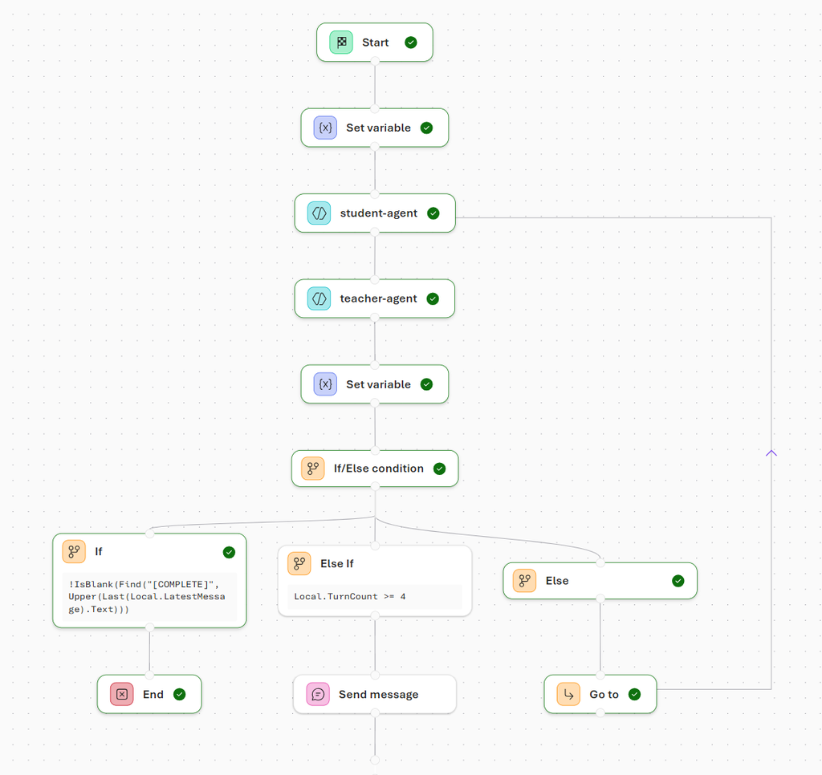

Uno dei vantaggi principali dei flussi di lavoro è la capacità di coordinare più agenti. Le soluzioni a agente singolo spesso hanno difficoltà con attività complesse o ambigue, ma i flussi di lavoro consentono di combinare gli agenti con responsabilità diverse, ad esempio la classificazione, il processo decisionale e la risoluzione, in un processo coesivo. Questa orchestrazione consente un’automazione più affidabile e scalabile.

I flussi di lavoro supportano anche modelli che bilanciano l’automazione con la supervisione. Negli scenari in cui la fiducia è bassa o più contesto è necessario, i flussi di lavoro possono sospendere l’esecuzione, richiedere l’input umano o escalare decisioni. Questa flessibilità rende i flussi di lavoro adatti ai sistemi reali in cui l’affidabilità e il controllo sono altrettanto importanti quanto l’efficienza.

Comprendendo quali flussi di lavoro sono e i problemi che sono progettati per risolvere, si stabilisce le basi concettuali necessarie per creare, estendere e ragionare sui sistemi basati su agenti in Microsoft Foundry.

## 6.3 Identificare i modelli di flusso di lavoro

Quando si creano soluzioni guidate dall’agente, la struttura del flusso di lavoro è importante tanto quanto gli agenti stessi. Diversi problemi richiedono approcci di orchestrazione diversi, a seconda del modo in cui vengono prese decisioni, del modo in cui i flussi di dati e se è necessario l’input umano. Microsoft Foundry offre diversi modelli di flusso di lavoro predefiniti che consentono di modellare queste interazioni in modo chiaro e coerente.

Un flusso di lavoro sequenziale segue un percorso predefinito e dettagliato. Ogni nodo viene eseguito in ordine, passando il relativo output al passaggio successivo nel flusso di lavoro. Questo modello funziona bene per le pipeline e i processi a più fasi, ad esempio la convalida dell’input, l’arricchimento dei dati e la generazione di una risposta finale. I flussi di lavoro sequenziali sono prevedibili e facili da ragionare, rendendoli un buon punto di partenza quando si apprende il funzionamento dei flussi di lavoro.

Un flusso di lavoro umano nel ciclo introduce pause in cui è necessario l’input o l’approvazione dell’utente prima che il flusso di lavoro possa continuare. In questo modello il flusso di lavoro pone in modo esplicito una domanda, attende una risposta e quindi riprende l’esecuzione in base a tale input. I flussi di lavoro con intervento umano sono utili quando l’automazione deve essere bilanciata con la supervisione umana, ad esempio approvazioni, conferme o situazioni in cui un contesto mancante deve essere fornito da una persona.

Un flusso di lavoro di chat di gruppo consente un’orchestrazione più dinamica tra più agenti. Anziché seguire un percorso fisso, il controllo può spostarsi tra gli agenti in base a contesto, regole o risultati intermedi. Questo modello è utile per gli scenari in cui più agenti specializzati collaborano per gestire richieste complesse, ad esempio il supporto clienti o la risposta alle domande multidominio. I flussi di lavoro di chat di gruppo consentono interazioni flessibili, in cui gli agenti possono basarsi sugli output degli altri e adattarsi ai cambiamenti di input.

Ogni modello fornisce una base per la strutturazione delle interazioni degli agenti, la gestione del flusso di controllo e l’incorporamento dell’input umano in base alle esigenze. Riconoscendo questi modelli di flusso di lavoro e comprendendone i punti di forza, è possibile scegliere un approccio di orchestrazione allineato allo scenario prima di iniziare a progettare un flusso di lavoro.

## 6.4 Creare flussi di lavoro in Microsoft Foundry

Microsoft Foundry offre una finestra di progettazione visiva che consente di creare flussi di lavoro come sequenza di nodi connessi. Ogni nodo rappresenta un’azione specifica, ad esempio la chiamata di un agente, la valutazione della logica o la trasformazione dei dati, e le connessioni tra i nodi definiscono il modo in cui l’esecuzione passa da un passaggio all’altro. Questo approccio visivo semplifica la logica di orchestrazione e comprende il modo in cui gli agenti interagiscono all’interno di un processo più ampio.

È possibile avviare un flusso di lavoro da un’area di disegno vuota o selezionando un modello predefinito, ad esempio un flusso di lavoro sequenziale. La finestra di progettazione visualizza il flusso di lavoro come una serie di nodi disposti nell’ordine di esecuzione. Durante la compilazione, è possibile spostare i nodi, inserire nuovi passaggi ed esaminare i dettagli di configurazione direttamente all’interno dell’area di disegno. Poiché i flussi di lavoro non vengono salvati automaticamente, è importante salvare regolarmente le modifiche per mantenere ogni versione della progettazione.

[figure not shown]

I tipi di nodo principali nel generatore di flussi di lavoro sono:

**Invoke**: richiama un agente di intelligenza artificiale dal progetto o ne crea uno nuovo. I nodi dell’agente possono restituire risposte senza testo o output strutturati (ad esempio JSON) che possono essere usati da altri nodi. Vengono usati per la classificazione, il ragionamento, le raccomandazioni o qualsiasi attività guidata dall’intelligenza artificiale.

**Flow**: controlla il percorso di esecuzione del flusso di lavoro. I nodi di flusso consentono al flusso di lavoro di adattarsi dinamicamente a input o situazioni diverse. I nodi di flusso includono: - **If/Else**: esecuzione ramificata in base alle condizioni. - **Vai a**: passa a un altro nodo nel flusso di lavoro. - **For Each**: esegue un ciclo su un elenco di elementi, effettuando le stesso operazioni per ciascuno di essi.

**Trasformazione dei dati**: modifica i dati e gestisce le variabili. I nodi di trasformazione dati assicurano che le informazioni vengano passate correttamente ai passaggi successivi. I nodi di trasformazione dati includono: - **Imposta variabile**: assegna un valore a una variabile per un uso successivo. - **Reimposta variabile**: cancella o reinizializza una variabile. - **Valore di analisi**: estrae dati specifici da output strutturati o converte i valori in formati diversi.

**Chat di base**: invia messaggi all’utente o pone domande per raccogliere l’input. Questi nodi vengono spesso associati alle variabili per acquisire risposte, che possono quindi influenzare la logica o le decisioni dell’agente in un secondo momento nel flusso di lavoro.

**Fine**: contrassegna la conclusione di un flusso di lavoro. Il nodo End può facoltativamente restituire un risultato o uno stato finale.

I flussi di lavoro sono eseguiti all’interno di un contesto di conversazione, consentendo di interagire con essi tramite la finestra di chat. Questa interattività consente di osservare come gli input si spostano tra i nodi e verificare che ogni passaggio si comporti come previsto prima di aggiungere una maggiore complessità. Man mano che i flussi di lavoro crescono, il designer visivo rende facile tracciare i percorsi di esecuzione e identificare rapidamente dove si verificano i rami logici o le decisioni.

Comprendere i nodi e come combinarli offre le basi per la creazione di flussi di lavoro che integrano il ragionamento di intelligenza artificiale, la gestione dei dati e la logica di controllo. I nodi sono i blocchi predefiniti che si assemblano per trasformare i concetti e gli obiettivi di automazione in flussi di lavoro funzionali e scalabili.

## 6.5 Aggiungere agenti a un flusso di lavoro

Gli agenti sono i componenti principali del ragionamento all’interno di un flusso di lavoro di Microsoft Foundry. Aggiungendo agenti a un flusso di lavoro, si abilita il processo decisionale, la classificazione e la generazione di risposte basati sull’intelligenza artificiale come parte di un’orchestrazione più ampia. Ogni agente può essere configurato con uno scopo, un modello, un prompt e un set di strumenti specifici, consentendo ai flussi di lavoro di combinare più funzionalità specializzate.

È possibile aggiungere agenti a un flusso di lavoro inserendo un nodo dell’agente Invoke . Questo nodo può fare riferimento a un agente esistente dal progetto Foundry oppure è possibile creare un nuovo agente direttamente all’interno della finestra di progettazione del flusso di lavoro. L’editor dell’agente Invoke consente di configurare strumenti, knowledge base, memoria e protezioni per l’agente, adattandone il comportamento alle esigenze del flusso di lavoro. Quando si richiama un agente, il flusso di lavoro passa il contesto, ad esempio l’input dell’utente o le variabili impostate in precedenza, all’agente e riceve una risposta che può essere usata nei passaggi successivi.

Gli agenti possono essere riutilizzati in più flussi di lavoro, che incoraggiano la progettazione modulare. Ad esempio, un singolo agente di categorizzazione potrebbe essere richiamato in molti flussi di lavoro per classificare le richieste in ingresso, mentre agenti di risoluzione diversi gestiscono le azioni di completamento. Questa separazione dei problemi semplifica la gestione e l’evoluzione dei flussi di lavoro nel tempo.

Oltre a generare risposte in linguaggio naturale, gli agenti possono essere configurati per restituire l’output strutturato. Definendo un formato di risposta, ad esempio uno schema JSON, si garantisce che l’output dell’agente segua una forma prevedibile. Gli output strutturati sono particolarmente utili quando le risposte dell’agente determinano il flusso di controllo, ad esempio la logica di routing o l’assegnazione di variabili nei nodi successivi. È possibile definire lo schema di output di un agente nei parametri della scheda Dettagli dell’editor dell’agente Invoke.

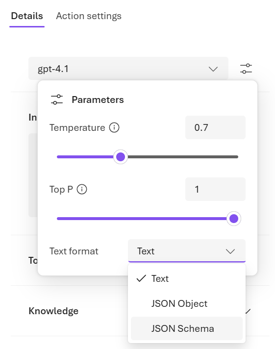

Dopo l’aggiunta di un agente a un flusso di lavoro, l’output può essere archiviato in una variabile e a cui viene fatto riferimento in tutto il flusso di lavoro. L’uso delle variabili consente agli agenti di influenzare decisioni, attivare rami condizionali o fornire input ad altri agenti. È possibile configurare l’archiviazione delle variabili nelle impostazioni azione del nodo Richiama agente.

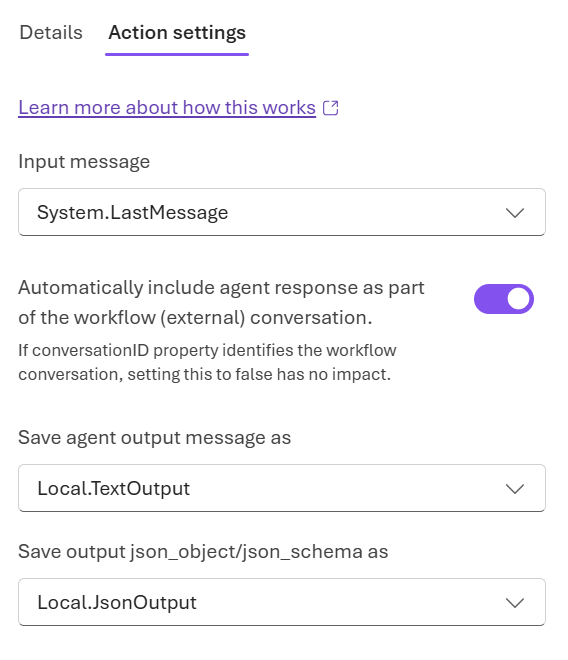

Aggiungendo e configurando gli agenti, si trasforma una semplice sequenza di azioni in un flusso di lavoro intelligente e adattivo.

## 6.6 Applicare Power Fx nei flussi di lavoro

Power Fx è il linguaggio a basso codice e simile a Excel che funge da elemento di coesione di un flusso di lavoro. Consente di modificare i dati, valutare le condizioni e controllare il flusso di esecuzione senza scrivere codice complesso. In un flusso di lavoro, le formule Power Fx vengono usate ovunque vengano prese decisioni, vengano impostate variabili o cicli, consentendo ai flussi di lavoro di reagire dinamicamente all’input dell’utente, agli output dell’agente o ai dati archiviati.

### 6.6.1 Funzionamento delle formule

Una formula di Power Fx è un’espressione che restituisce un valore. Le formule possono fare riferimento a variabili **locali** e di **sistema**:

- Le **variabili di sistema** forniscono informazioni contestuali sul flusso di lavoro o sulla conversazione, ad esempio l’attività corrente, l’ultimo messaggio o le informazioni dell’utente.
- Le **variabili locali** archiviano i dati acquisiti o creati durante l’esecuzione del flusso di lavoro e possono essere usati nei nodi successivi.

Ad esempio, è possibile creare formule per:

- Convertire l’input di un utente in lettere maiuscole: `Upper(Local.Input)`
- Controllare se il punteggio di attendibilità di un agente è superiore a una soglia: `Local.Confidence > 0.8`
- Sommare i valori in un elenco o in una colonna di record: `Sum(Local.ItemList, Amount)`

L’uso di variabili nelle formule consente ai flussi di lavoro di adattarsi in base al contesto e ai passaggi precedenti.

### 6.6.2 Condizioni come punti decisionali

Le espressioni Power Fx vengono comunemente usate nei nodi If/Else per valutare le condizioni e l’esecuzione dei rami. Le condizioni possono fare riferimento a variabili di sistema o locali, output dell’agente strutturato o altri dati del flusso di lavoro. Ad esempio, un flusso di lavoro potrebbe controllare il punteggio di attendibilità di un agente per decidere se continuare l’elaborazione automaticamente o di inoltrare il problema a un essere umano.

### 6.6.3 Cicli per l’elaborazione di più elementi

Per ogni nodo usare Power Fx per scorrere le raccolte, applicando lo stesso set di azioni a ogni elemento. Combinando cicli con variabili e condizioni, i flussi di lavoro possono gestire elenchi di input, ad esempio più ticket di supporto, senza duplicare nodi o logica.

### 6.6.4 Esempi di formule Power Fx

| Scopo | Esempio di formula | Note |
| --- | --- | --- |
| Convertire il testo in maiuscolo | `Upper(Local.Input)` | Trasforma una stringa in tutte le maiuscole |
| Convertire il testo in lettere minuscole | `Lower(Local.Input)` | Trasforma una stringa in tutte le lettere minuscole |
| Ottenere la lunghezza della stringa | `Len(Local.Input)` | Restituisce il numero di caratteri in una stringa |
| Controllo condizionale | `Local.Confidence > 0.8` | Restituisce true/false; usato nei nodi If/Else |
| Logica If/Else | `If(Local.Confidence > 0.8, "Proceed", "Escalate")` | Restituisce uno dei due valori a seconda di una condizione |
| Sommare un elenco di numeri | `Sum([10, 20, 30])` | Aggiunge numeri in un elenco semplice |
| Sommare una colonna in una tabella | `Sum(Local.ItemList, Amount)` | Somma la proprietà Amount di ciascun record in una tabella |
| Contare gli elementi in una tabella o un elenco | `Count(Local.ItemList)` | Restituisce il numero di elementi |
| Controllare se vuoto | `IsBlank(Local.Input)` | Restituisce true se la variabile o l’input è vuoto |
| Controllare se la tabella è vuota | `IsEmpty(Local.ItemList)` | Restituisce vero se una tabella non contiene record |
| Scorrere gli elementi | `ForAll(Local.ItemList, Upper(Name))` | Applica una formula a ogni elemento di un elenco o di una tabella |
| Concatenare il testo | `Concatenate(Local.FirstName, " ", Local.LastName)` | Unisce più stringhe in una |

Usando formule Power Fx in un flusso di lavoro, si creano processi dinamici basati sui dati che rispondono in modo intelligente agli input e agli output degli agenti. Questo approccio con poco codice consente di creare logica complessa mantenendo i flussi di lavoro gestibili e comprensibili.

**Consiglio**

Per altre informazioni sul linguaggio Power Fx, vedere la [documentazione di Power Fx](https://learn.microsoft.com/it-it/power-platform/power-fx/overview).

## 6.7 Gestire i flussi di lavoro in Microsoft Foundry

La creazione di un flusso di lavoro è solo il primo passaggio: l’automazione reale si evolve nel tempo. La gestione e la affinamento dei flussi di lavoro garantisce che rimangano affidabili, comprensibili e adattabili in base alle esigenze aziendali o ai modelli di intelligenza artificiale. Usando le funzionalità predefinite di Microsoft Foundry, è possibile gestire in modo efficace le versioni del flusso di lavoro, le modifiche ai documenti e mantenere sincronizzate le rappresentazioni sia visive che YAML.

### 6.7.1 Rappresentazioni YAML e visive

I flussi di lavoro di Microsoft Foundry possono essere rappresentati sia in un canvas visivo che in YAML. L’area di disegno visiva è ideale per la comprensione concettuale, la traccia dei percorsi di esecuzione e la collaborazione con altri utenti. YAML fornisce una rappresentazione testuale del flusso di lavoro, che può essere modificata per la configurazione avanzata, il rilevamento delle versioni o l’integrazione con il controllo del codice sorgente. Le modifiche in entrambe le visualizzazioni si riflettono nell’altra, offrendo flessibilità mantenendo al tempo stesso coerenti i flussi di lavoro.

### 6.7.2 Controllo delle versioni

Ogni volta che viene salvato un flusso di lavoro, Foundry crea automaticamente una nuova versione non modificabile. Il controllo delle versioni fornisce una rete di sicurezza: è possibile esaminare le versioni precedenti, confrontare le modifiche o eseguire il rollback a un flusso di lavoro precedente se una modifica introduce errori. Il controllo delle versioni supporta anche la collaborazione, rendendo più semplice tenere traccia di chi ha apportato modifiche e perché.

### 6.7.3 Aggiunta di note per i responsabili della manutenzione

Il visualizzatore del flusso di lavoro consente di allegare note a nodi o sezioni del flusso di lavoro. Le note forniscono contesto, spiegano le decisioni di progettazione o chiarisce l’utilizzo delle variabili. L’aggiunta di una documentazione chiara consente ai gestori futuri o ai membri del team di comprendere lo scopo e la logica del flusso di lavoro, riducendo gli errori e accelerando gli aggiornamenti.

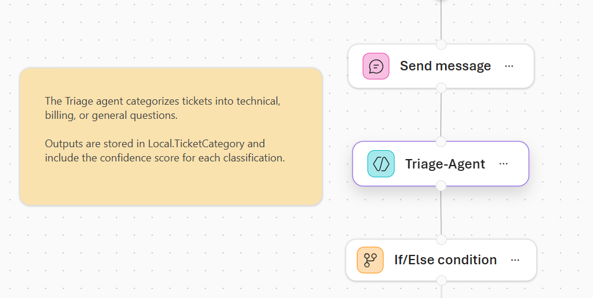

### 6.7.4 Procedure consigliate per il perfezionamento

La gestione dei flussi di lavoro non riguarda solo la correzione degli errori, ma riguarda il miglioramento della chiarezza, dell’affidabilità e dell’efficienza. Le procedure consigliate includono:

- Esaminare regolarmente i flussi di lavoro per i nodi inutilizzati o ridondanti.
- Garantire che gli output dell’agente strutturato vengano gestiti in modo coerente.
- Documentare decisioni e logica con note.
- Uso della cronologia delle versioni per tenere traccia delle modifiche e convalidare gli aggiornamenti.

Combinando la modifica YAML, il controllo della versione e la documentazione ponderata, si garantisce che i flussi di lavoro siano affidabili, gestibili e pronti per l’uso aziendale. Questa attenzione alla gestibilità consente ai team di ridimensionare l’automazione con fiducia e adattabilità.

## 6.8 Usare i flussi di lavoro nel codice

Dopo aver progettato e testato un flusso di lavoro nella finestra di progettazione visiva di Microsoft Foundry, è possibile integrarlo nelle applicazioni usando Azure AI Projects SDK. In questo modo è possibile incorporare l’automazione basata sul flusso di lavoro in app Web, API, servizi back-end e altre soluzioni software.

I flussi di lavoro vengono creati nel portale foundry usando la finestra di progettazione visiva, che genera la definizione YAML sottostante. Dopo aver salvato un flusso di lavoro nel progetto, è possibile richiamarlo a livello di codice facendo riferimento al nome. È anche possibile scaricare la definizione YAML del flusso di lavoro dal portale e includerla nella codebase.

### 6.8.1 Richiamare un flusso di lavoro

Prima di eseguire un flusso di lavoro, stabilire una connessione al progetto Microsoft Foundry usando .`AIProjectClient` Questo client gestisce l’autenticazione e fornisce l’accesso all’API compatibile con OpenAI per l’esecuzione di conversazioni e la chiamata di flussi di lavoro. Per eseguire un flusso di lavoro esistente nel tuo progetto, crea una conversazione e invoca il flusso di lavoro per nome.

```
python
```

```python
# Reference a workflow created in the Foundry portal
workflow_name = "triage-workflow"

# Create a conversation context for the workflow
conversation = openai_client.conversations.create()

# Execute the workflow, passing input to drive the workflow logic
stream = openai_client.responses.create(
    conversation=conversation.id,
    extra_body={"agent": {"name": workflow_name, "type": "agent_reference"}},
    input="Users can't reset their password from the mobile app.",
    stream=True,
)
```

Il parametro `input` consente di passare una richiesta o un messaggio al flusso di lavoro, che il flusso di lavoro può usare per determinarne la logica, ad esempio l’elaborazione di una richiesta utente, la valutazione di un ticket di supporto o la risposta a una domanda. A seconda del modo in cui è progettato il flusso di lavoro, questo input potrebbe essere:

- Domanda utente che gli agenti analizzano e rispondono
- Descrizione del ticket di supporto per la classificazione e l’indirizzamento
- Payload di dati che attiva la logica di elaborazione
- Stringa vuota che avvia semplicemente il flusso di lavoro senza input specifico

### 6.8.2 Elaborare gli eventi del flusso di lavoro

Quando lo streaming è abilitato, l’applicazione riceve gli eventi durante l’esecuzione del flusso di lavoro. Questi eventi consentono di visualizzare lo stato di avanzamento in tempo reale, acquisire gli output dell’agente e rispondere alle azioni del flusso di lavoro.

```
python
```

```python
for event in stream:
    if event.type == "response.completed":
        print("Workflow completed:")
        for message in event.response.output:
            if message.content:
                for content_item in message.content:
                    if content_item.type == 'output_text':
                        print(content_item.text)
    if (event.type == "response.output_item.done") and event.item.type == ItemType.WORKFLOW_ACTION:
        print(f"Action '{event.item.action_id}' completed with status: {event.item.status}")
```

I tipi di evento comuni includono:

| Tipo di evento | Description |
| --- | --- |
| `response.completed` | Il flusso di lavoro ha terminato l’esecuzione e ha restituito una risposta finale |
| `response.output_item.done` | Un singolo elemento di output (ad esempio un’azione del flusso di lavoro) completato |

Monitorando questi eventi, è possibile vedere in che modo il flusso di lavoro avanza in tempo reale o attivare azioni esterne in base allo stato del flusso di lavoro. In alternativa, è possibile scegliere di attendere il completamento dell’intero flusso di lavoro ed elaborare la risposta finale senza streaming. Per i flussi di lavoro che includono modelli di ciclo umano, l’applicazione potrebbe dover gestire le pause in cui il flusso di lavoro attende l’input dell’utente. In questi casi, è possibile inviare messaggi aggiuntivi alla conversazione per fornire l’input richiesto e riprendere l’esecuzione del flusso di lavoro.

### 6.8.3 Vantaggi dell’integrazione del codice

L’integrazione dei flussi di lavoro nel codice consente diversi scenari:

| Scenario | Beneficio |
| --- | --- |
| Applicazioni Web | Incorporare flussi di lavoro basati sull’intelligenza artificiale direttamente nelle app rivolte agli utenti |
| API e microservizi | Esporre le funzionalità del flusso di lavoro tramite endpoint REST |
| Elaborazione in batch | Richiamare flussi di lavoro programmaticamente per le operazioni di massa |
| Test e convalida | Automatizzare i test del flusso di lavoro come parte delle pipeline CI/CD |
| Interfacce personalizzate | Creare interfacce utente specializzate personalizzate per casi d’uso specifici del flusso di lavoro |

Combinando l’esperienza di progettazione visiva del portale Foundry con la flessibilità dell’integrazione del codice, è possibile creare potenti soluzioni basate sull’intelligenza artificiale che si adattino perfettamente all’architettura software esistente.

# 7 Sviluppare un agente di intelligenza artificiale con Microsoft Agent Framework

## 7.1 Introduzione

Gli agenti di intelligenza artificiale stanno trasformando il modo in cui le applicazioni interagiscono con gli utenti e automatizzano le attività. A differenza dei programmi tradizionali, gli agenti di intelligenza artificiale usano l’intelligenza artificiale generativa per interpretare i dati, prendere decisioni e completare attività con un intervento umano minimo. Questi agenti usano modelli linguistici di grandi dimensioni per semplificare flussi di lavoro complessi, rendendoli ideali per l’automazione dei processi aziendali.

Gli sviluppatori possono creare agenti di intelligenza artificiale usando diversi strumenti, tra cui Microsoft Agent Framework. Questo SDK open source semplifica l’integrazione dei modelli di intelligenza artificiale nelle applicazioni. Microsoft Agent Framework supporta diversi tipi di agenti di più provider, tra cui Microsoft Foundry, Azure OpenAI, OpenAI, Microsoft Copilot Studio e agenti Anthropic. Questo modulo è incentrato sugli agenti Microsoft Foundry, che offrono funzionalità di livello aziendale tramite il servizio Microsoft Foundry Agent.

Il servizio Microsoft Foundry Agent è un servizio completamente gestito che consente agli sviluppatori di creare, distribuire e ridimensionare in modo sicuro agenti di intelligenza artificiale estendibili di alta qualità. Usando il servizio Agente Foundry, gli sviluppatori non devono gestire le risorse di calcolo o di archiviazione sottostanti. Microsoft Agent Framework consente agli sviluppatori di creare rapidamente agenti nel servizio Foundry Agent, supportando l’elaborazione del linguaggio naturale e fornendo l’accesso agli strumenti predefiniti in poche righe di codice.

Anche se il servizio Foundry Agent offre una base efficace per la creazione di agenti di intelligenza artificiale, Microsoft Agent Framework offre maggiore flessibilità e scalabilità. Se la soluzione richiede più tipi di agenti, l’uso di Microsoft Agent Framework garantisce la coerenza nell’implementazione. Infine, se si prevede di sviluppare soluzioni multi-agente, le funzionalità di orchestrazione del flusso di lavoro del framework consentono di coordinare gli agenti collaborativi in modo efficiente, un argomento trattato in modo più dettagliato in un modulo successivo.

Supponiamo che sia necessario sviluppare un agente di intelligenza artificiale che formatti automaticamente e invii via e-mail le note spese dei dipendenti. L’agente di intelligenza artificiale può estrarre i dati dai report spese inviati, formattarli correttamente e inviarli ai destinatari appropriati quando si usa Microsoft Agent Framework. La funzionalità strumenti e funzioni consente all’agente di intelligenza artificiale di interagire con le API, recuperare i dati necessari e completare le attività.

In questo modulo vengono fornite informazioni sulle funzionalità di base di Microsoft Agent Framework SDK. Si apprenderà anche come creare agenti di intelligenza artificiale ed estendere le proprie funzionalità con le funzioni degli strumenti.

Dopo aver completato questo modulo, si sarà in grado di:

- Usare Microsoft Agent Framework per connettersi a un progetto Microsoft Foundry.
- Creare agenti di Microsoft Foundry usando il Microsoft Agent Framework.
- Integrare le funzioni degli strumenti con l’agente di intelligenza artificiale.

**Nota**

Sappiamo che persone diverse amano imparare in modi diversi. È possibile scegliere di completare questo modulo in formato basato su video oppure leggere il contenuto come testo e immagini. Il testo contiene maggiori dettagli rispetto ai video, quindi in alcuni casi potresti voler farvi riferimento come materiale supplementare alla presentazione video.

## 7.2 Informazioni sugli agenti di intelligenza artificiale di Microsoft Agent Framework

Un agente di intelligenza artificiale è un programma che utilizza l’IA generativa per interpretare dati, prendere decisioni ed eseguire attività per conto di utenti o altre applicazioni. Gli agenti IA si basano su modelli linguistici di grandi dimensioni per eseguire le proprie attività. A differenza dei programmi tradizionali, gli agenti di intelligenza artificiale possono funzionare in modo autonomo, gestendo flussi di lavoro complessi e automatizzando i processi senza richiedere una supervisione umana continua.

Gli agenti di intelligenza artificiale possono essere sviluppati usando molti strumenti e piattaforme diversi, tra cui Microsoft Agent Framework. Microsoft Agent Framework è un SDK open source che consente agli sviluppatori di integrare facilmente i modelli di intelligenza artificiale più recenti nelle applicazioni. Questo framework offre una base completa per la creazione di agenti funzionali che possono usare l’elaborazione del linguaggio naturale per completare le attività e collaborare con altri agenti.

### 7.2.1 Componenti di base di Microsoft Agent Framework

Microsoft Agent Framework offre componenti diversi che possono essere usati singolarmente o combinati.

- **Agenti**: offre un’interfaccia coerente e abilita diverse funzionalità come l’orchestrazione multi-agente. Gli agenti supportano le chiamate di funzione definite, le conversazioni a più turni con la cronologia delle chat, gli strumenti integrati nel servizio, gli output strutturati e le risposte in streaming.
- **Provider di chat**: forniscono astrazioni per la connessione ai servizi di intelligenza artificiale da provider diversi in un’interfaccia comune. I provider supportati includono Azure OpenAI, OpenAI, Anthropic, Copilot e altro ancora tramite l’astrazione BaseAgent .
- **Strumenti per le funzioni**: contenitori per funzioni personalizzate che estendono le funzionalità dell’agente. Gli agenti possono richiamare automaticamente le funzioni per l’integrazione con API e servizi esterni.
- **Strumenti predefiniti**: funzionalità predefinite, tra cui Interprete del codice per l’esecuzione di Python, Ricerca file per l’analisi dei documenti e Ricerca Web per l’accesso a Internet.
- **Gestione delle conversazioni**: sistema di messaggi strutturato con ruoli (USER, ASSISTANT, SYSTEM, TOOL) e AgentSession per il contesto di conversazione persistente tra le interazioni.
- **Orchestrazione del flusso di lavoro**: supporta flussi di lavoro sequenziali, esecuzione simultanea, chat di gruppo e modelli di handoff per la collaborazione multi-agente complessa.

Microsoft Agent Framework semplifica la creazione di agenti e consente a più agenti di lavorare insieme nelle conversazioni, includendo l’input umano. Il framework supporta diversi tipi di agenti di più provider, tra cui Microsoft Foundry, Azure OpenAI, OpenAI, Microsoft Copilot Studio e agenti Anthropic.

### 7.2.2 Che cos’è un agente Microsoft Foundry?

Gli agenti Microsoft Foundry offrono funzionalità a livello aziendale usando il servizio Microsoft Foundry Agent. Questi agenti offrono funzionalità avanzate per scenari aziendali complessi. I vantaggi principali includono:

- **Funzionalità a livello aziendale**: progettato per gli ambienti Azure con funzionalità avanzate di intelligenza artificiale, tra cui interprete del codice, integrazione degli strumenti di funzione e supporto mcp (Model Context Protocol).
- **Chiamata automatica degli strumenti**: gli agenti possono chiamare ed eseguire automaticamente gli strumenti, integrandosi facilmente con Ricerca di intelligenza artificiale di Azure, Funzioni di Azure e altri servizi di Azure.
- **Gestione di thread e conversazioni**: fornisce meccanismi predefiniti per la gestione degli stati di conversazione permanenti tra le sessioni, garantendo interazioni multi-agente uniformi.
- **Integrazione aziendale sicura**: consente lo sviluppo di agenti di intelligenza artificiale sicuri e conformi con l’autenticazione dell’interfaccia della riga di comando di Azure, il controllo degli accessi in base al ruolo e le opzioni di archiviazione personalizzabili.

Quando si usa Microsoft Foundry Agents, si ottengono tutte le funzionalità aziendali di Azure combinate con le funzionalità di Microsoft Agent Framework. Queste funzionalità consentono di creare flussi di lavoro affidabili basati sull’intelligenza artificiale che possono essere ridimensionati in modo efficiente tra applicazioni aziendali.

### 7.2.3 Concetti di base del framework di Agent

- **BaseAgent**: la base per tutti gli agenti con metodi coerenti, fornendo un’interfaccia unificata in tutti i tipi di agente.
- **Sessione agente**: gestire il contesto di conversazione persistente e archiviare la cronologia delle conversazioni tra le sessioni usando la AgentSession classe .
- **Messaggi di chat**: struttura organizzata per la comunicazione degli agenti tramite la messaggistica basata su ruoli (USER, ASSISTANT, SYSTEM, TOOL) che consente una comunicazione e un’integrazione fluide.
- **Orchestrazione del flusso di lavoro**: supporta flussi di lavoro sequenziali, esecuzione di più agenti in parallelo, conversazioni di gruppo tra agenti e trasferimento del controllo tra agenti specializzati.
- **Supporto multi modale**: consente agli agenti di elaborare testo, immagini e output strutturati, incluse funzionalità di analisi visiva e generazione di risposte indipendenti dai tipi.
- **Strumenti per le funzioni**: consente di aggiungere funzionalità personalizzate agli agenti includendo funzioni personalizzate con generazione automatica dello schema dalle funzioni Python.
- **Metodi di autenticazione**: supporta più metodi di autenticazione, tra cui le credenziali dell’interfaccia della riga di comando di Azure, le chiavi API, MSAL per l’autenticazione aziendale Microsoft e il controllo degli accessi in base al ruolo.

Questo framework supporta comportamenti di intelligenza artificiale autonomi e multi-agente mantenendo al contempo un’architettura flessibile che consente di combinare e associare agenti, strumenti e flussi di lavoro in base alle esigenze. La progettazione consente di passare da OpenAI, Azure OpenAI, Anthropic e altri provider senza modificare il codice, semplificando la creazione di sistemi di intelligenza artificiale, da chatbot semplici a soluzioni aziendali complesse.

## 7.3 Creare un agente di Intelligenza artificiale di Azure con Microsoft Agent Framework

**Microsoft Foundry Agent** è un agente specializzato all’interno di Microsoft Agent Framework, progettato per offrire funzionalità di conversazione a livello aziendale con l’integrazione senza problemi degli strumenti. Gestisce automaticamente le chiamate agli strumenti, quindi non è necessario analizzare e richiamare manualmente le funzioni. L’agente gestisce in modo sicuro anche la cronologia delle conversazioni usando thread, riducendo così il lavoro di mantenimento dello stato. Microsoft Foundry Agent supporta molti strumenti predefiniti, tra cui interprete del codice, ricerca di file e ricerca Web. Offre anche funzionalità di integrazione per Ricerca intelligenza artificiale di Azure, Funzioni di Azure e altri servizi di Azure.

### 7.3.1 Creazione di un agente di intelligenza artificiale di Azure

Microsoft Foundry Agent include tutte le funzionalità di base necessarie in genere per le applicazioni di intelligenza artificiale aziendale, ad esempio l’esecuzione delle funzioni, la pianificazione e l’accesso alla memoria. Questo agente funge da runtime autonomo con funzionalità a livello aziendale.

Per usare Microsoft Foundry Agent:

1. Creare un progetto Microsoft Foundry.
2. Aggiungere la stringa di connessione del progetto al codice dell’applicazione Microsoft Agent Framework.
3. Configurare le credenziali di autenticazione con AzureCliCredential.
4. Connetti al client del progetto con la classe AzureOpenAIResponsesClient.
5. Creare un’istanza Agent con il client, le istruzioni e gli strumenti da usare.

Dopo aver creato l’agente, è possibile creare una sessione di conversazione per interagire con l’agente e ottenere risposte alle domande.

### 7.3.2 Componenti chiave dell’agente di Intelligenza artificiale di Azure

Microsoft Agent Framework Azure AI Agent usa i componenti seguenti per funzionare:

- **AzureOpenAIResponsesClient**: gestisce la connessione al progetto Microsoft Foundry. Questo client consente di accedere ai servizi e ai modelli associati al progetto e fornisce funzionalità di autenticazione e sicurezza a livello aziendale.
- **Agent**: la classe agente principale che combina il client, le istruzioni e gli strumenti per creare un agente di intelligenza artificiale funzionante in grado di gestire le conversazioni e completare le attività.
- **AgentSession**: tiene traccia automaticamente della cronologia delle conversazioni tra agenti e utenti e gestisce lo stato della conversazione. È possibile creare nuovi thread o riutilizzare quelli esistenti per mantenere il contesto tra le interazioni.
- **Integrazione degli strumenti**: supporto per funzioni personalizzate che estendono le funzionalità dell’agente. Le funzioni vengono registrate automaticamente e possono essere chiamate dagli agenti per connettersi con API e servizi esterni.
- **Credenziali di autenticazione**: supporta le credenziali dell’interfaccia della riga di comando di Azure, l’autenticazione dell’entità servizio e altre opzioni di identità di Azure per l’accesso sicuro a Foundry Tools.
- **Gestione dei thread**: offre opzioni flessibili per la creazione di thread, tra cui la creazione automatica di thread per scenari semplici e la gestione esplicita dei thread per le conversazioni in corso.

Questi componenti interagiscono per consentire di creare agenti a livello aziendale con istruzioni per definire il loro scopo e ottenere risposte dai modelli di intelligenza artificiale mantenendo al contempo il contesto di sicurezza, scalabilità e conversazione per le applicazioni aziendali.

## 7.4 Aggiungere strumenti all’agente di intelligenza artificiale di Azure

In Microsoft Agent Framework gli strumenti consentono all’agente di intelligenza artificiale di usare le API e i servizi esistenti per eseguire attività che non è stato possibile eseguire autonomamente. Gli strumenti funzionano tramite chiamate di funzione, consentendo all’intelligenza artificiale di richiedere e usare automaticamente funzioni specifiche. Il framework instrada la richiesta alla funzione appropriata nella codebase e restituisce i risultati al modello LLM (Large Language Model) in modo che possa generare una risposta finale.

Per abilitare la chiamata automatica delle funzioni, gli strumenti devono fornire dettagli che descrivono come funzionano. L’input, l’output e lo scopo della funzione devono essere descritti in modo che l’intelligenza artificiale possa comprendere, in caso contrario, l’intelligenza artificiale non può chiamare correttamente la funzione.

### 7.4.1 Come usare gli strumenti con Microsoft Foundry Agent

Microsoft Agent Framework supporta sia strumenti per funzioni personalizzate che strumenti predefiniti pronti all’uso.

#### 7.4.1.1 Strumenti predefiniti

Gli agenti di Microsoft Foundry sono dotati di diversi strumenti predefiniti che è possibile usare immediatamente:

- **Interprete del codice**: esegue codice Python per calcoli, analisi dei dati e altro ancora
- **Ricerca di file**: esegue ricerche e analizza i documenti
- **Ricerca Web**: recupera informazioni da Internet

Questi strumenti sono automaticamente disponibili e non richiedono alcuna configurazione aggiuntiva.

#### 7.4.1.2 Strumenti per le funzioni personalizzate

Quando si creano strumenti personalizzati per Microsoft Foundry Agent, è necessario comprendere diversi concetti chiave:

1. **Usare il decoratore dello strumento** Creare uno strumento funzione personalizzato definendo una funzione Python e decorandola con il @tool decorator del Microsoft Agent Framework. Questo elemento Decorator registra la funzione come uno strumento che l’IA può chiamare. L’elemento Decorator @tool include parametri per fornire un nome e una descrizione per lo strumento, nonché approval_mode per specificare se le chiamate allo strumento richiedono l’approvazione.
2. **Definizione di funzione e annotazioni** Creare lo strumento definendo una normale funzione Python con annotazioni di tipo appropriate. Usare Annotated e Field da Pydantic per fornire descrizioni dettagliate che consentono all’intelligenza artificiale di comprendere lo scopo della funzione e come usare i relativi parametri. Più descrittive sono le annotazioni, meglio l’intelligenza artificiale può comprendere quando e come chiamare la funzione.
3. **Aggiunta di strumenti all’agente** Passare le funzioni personalizzate a ChatAgent durante la creazione usando il tools parametro . È possibile aggiungere una singola funzione o un elenco di più funzioni. Il framework registra automaticamente queste funzionalità e le rende disponibili all’intelligenza artificiale per chiamare.
4. **Chiamata dello strumento tramite conversazione** Dopo aver registrato gli strumenti con l’agente, non è necessario richiamarli manualmente. In alternativa, porre domande all’agente o assegnarle attività che richiederebbero naturalmente la funzionalità dello strumento. L’intelligenza artificiale determina automaticamente quando chiamare gli strumenti in base al contesto della conversazione e alle descrizioni degli strumenti forniti.
5. **Più strumenti e orchestrazione** È possibile aggiungere più strumenti a un singolo agente e l’intelligenza artificiale sceglie automaticamente quale strumento usare in base alla richiesta dell’utente. Il framework gestisce l’orchestrazione, chiamando le funzioni appropriate e combinando i risultati per fornire una risposta completa.

### 7.4.2 Procedure consigliate per lo sviluppo di strumenti

- **Descrizioni chiare**: scrivere descrizioni chiare e dettagliate per le funzioni e i parametri per facilitare la comprensione dello scopo dell’intelligenza artificiale
- **Annotazioni di tipo**: usare suggerimenti di tipo Python appropriati per specificare i tipi di input e output previsti
- **Gestione degli errori**: implementare la gestione degli errori appropriata nelle funzioni dello strumento per gestire correttamente gli input imprevisti
- **Restituire dati significativi**: assicurarsi che le funzioni restituiscono dati che l’intelligenza artificiale possa usare in modo efficace nelle risposte
- **Mantenere incentrate le funzioni**: progettare ogni strumento per gestire un’attività specifica anziché tentare di eseguire troppe operazioni in una sola funzione

Seguendo questi concetti, è possibile estendere Microsoft Foundry Agent con strumenti predefiniti e personalizzati, consentendo di interagire con le API ed eseguire attività avanzate. Questo approccio rende l’intelligenza artificiale più potente e in grado di gestire in modo efficiente le applicazioni reali.

# 8 Orchestrare una soluzione multi-agente usando Microsoft Agent Framework

## 8.1 Introduzione

Gli agenti di intelligenza artificiale offrono una potente combinazione di tecnologie, in grado di completare le attività con l’uso dell’intelligenza artificiale generativa. In alcune situazioni, tuttavia, l’attività necessaria potrebbe essere più grande di quanto sia realistica per un singolo agente. Per questi scenari, considerare una soluzione multi-agenti. Una soluzione multi-agente consente agli agenti di collaborare all’interno della stessa conversazione.

Si supponga di provare a risolvere le problematiche comuni di DevOps, ad esempio il monitoraggio delle prestazioni dell’applicazione, l’identificazione dei problemi e la distribuzione delle correzioni. Un sistema multi-agente può essere costituito da quattro agenti specializzati che lavorano in modo collaborativo:

- L’agente di monitoraggio inserisce continuamente log e metriche, rileva le anomalie usando l’elaborazione del linguaggio naturale (NLP) e attiva gli avvisi quando si verificano problemi.
- L’agente di analisi della causa radice correla quindi queste anomalie con le modifiche di sistema recenti, usando modelli di Machine Learning o regole predefinite per individuare la causa radice del problema.
- Dopo aver identificato la causa radice, l’agente di distribuzione automatica assume il controllo per implementare correzioni o eseguire il rollback delle modifiche problematiche interagendo con le pipeline CI/CD ed eseguendo script di distribuzione.
- Infine, l’agente di report genera report dettagliati che riepilogano le anomalie, le cause radice e le risoluzioni e notifica agli stakeholder tramite posta elettronica o altri canali di comunicazione.

Questo sistema modulare, scalabile e intelligente multi-agente semplifica il processo DevOps. Gli agenti collaborano per ridurre l’intervento manuale e migliorare l’efficienza garantendo al tempo stesso comunicazioni tempestive e risoluzione dei problemi.

In questo modulo si esaminerà come usare le potenti funzionalità di Microsoft Agent Framework per progettare e orchestrare agenti intelligenti che funzionano in modo collaborativo per risolvere problemi complessi. Verranno inoltre illustrati i diversi tipi di modelli di orchestrazione disponibili e si userà Microsoft Agent Framework per sviluppare agenti di intelligenza artificiale personalizzati che possono collaborare per una soluzione multi-agente.

Dopo aver completato questo modulo, sarai in grado di:

- Creare agenti di intelligenza artificiale con Microsoft Agent Framework SDK
- Usare strumenti e plug-in con gli agenti di intelligenza artificiale
- Informazioni sui diversi tipi di modelli di orchestrazione
- Sviluppare soluzioni multi-agente

## 8.2 Informazioni su Microsoft Agent Framework

Microsoft Agent Framework è un SDK open source che consente agli sviluppatori di integrare i modelli di intelligenza artificiale nelle applicazioni. Questo framework offre supporto completo per la creazione di agenti basati sull’intelligenza artificiale che possono funzionare in modo indipendente o collaborare con altri agenti per eseguire attività complesse.

### 8.2.1 Che cos’è Microsoft Agent Framework?

Microsoft Agent Framework è progettato per aiutare gli sviluppatori a creare agenti basati su intelligenza artificiale in grado di elaborare input utente, prendere decisioni ed eseguire attività in modo autonomo sfruttando i modelli di linguaggio di grandi dimensioni e la logica di programmazione tradizionale. Il framework fornisce componenti strutturati per la definizione di flussi di lavoro basati sull’intelligenza artificiale, consentendo agli agenti di interagire con utenti, API e servizi esterni senza problemi.

### 8.2.2 Concetti principali

Microsoft Agent Framework offre un’architettura flessibile con i componenti chiave seguenti:

- **Agenti** Gli agenti sono entità intelligenti basate sull’intelligenza artificiale in grado di ragionare ed eseguire attività. Usano modelli linguistici di grandi dimensioni, strumenti e cronologia delle conversazioni per prendere decisioni in modo dinamico e rispondere alle esigenze degli utenti.
- **Orchestrazione dell’agente** Più agenti possono collaborare verso un obiettivo comune usando modelli di orchestrazione diversi. Microsoft Agent Framework supporta diversi modelli di orchestrazione con un’interfaccia unificata per la costruzione e la chiamata, consentendo di passare facilmente da un modello all’altro senza riscrivere la logica dell’agente.

Il framework include diverse funzionalità di base che potenziano la funzionalità dell’agente.

- **Client di chat** I client chat forniscono astrazioni per la connessione ai servizi di intelligenza artificiale da provider diversi in un’interfaccia comune. I provider supportati includono Azure OpenAI, OpenAI, Anthropic e altro ancora tramite l’astrazione BaseChatClient .
- **Strumenti e integrazione delle funzioni** Gli strumenti consentono agli agenti di estendere le proprie funzionalità tramite funzioni personalizzate e servizi predefiniti. Gli agenti possono richiamare automaticamente gli strumenti per l’integrazione con API esterne, eseguire codice, cercare file o accedere alle informazioni Web. Il framework supporta sia strumenti di funzione personalizzati che strumenti predefiniti come Interprete codice, Ricerca file e Ricerca Web.
- **Gestione delle conversazioni** Gli agenti possono mantenere la cronologia delle conversazioni tra più interazioni usando AgentSession, consentendo loro di tenere traccia delle interazioni precedenti e adattare le risposte di conseguenza. Il sistema di messaggi strutturato usa ruoli (USER, ASSISTANT, SYSTEM, TOOL) per il contesto di conversazione persistente.

### 8.2.3 Perché è consigliabile usare Microsoft Agent Framework

Microsoft Agent Framework offre una solida piattaforma per la creazione di agenti di intelligenza artificiale intelligenti, autonomi e collaborativi. Il framework può integrare agenti da più origini, incluso il servizio Microsoft Foundry Agent, e supporta sia la collaborazione tra più agenti che l’interazione tra agenti umani. Gli agenti possono collaborare per orchestrare flussi di lavoro sofisticati, in cui ogni agente è specializzato in un’attività specifica, ad esempio la raccolta di dati, l’analisi o il processo decisionale. Il framework facilita anche i processi umani nel ciclo, consentendo agli agenti di aumentare il processo decisionale umano fornendo informazioni dettagliate o automatizzando attività ripetitive. La progettazione indipendente dal provider consente di passare da provider di intelligenza artificiale diversi senza modificare il codice, rendendolo adatto per la creazione di sistemi di intelligenza artificiale adattabili da chatbot semplici a soluzioni aziendali complesse.

## 8.3 Informazioni sull’orchestrazione degli agenti

Il framework di orchestrazione agente di Microsoft Agent Framework SDK consente di progettare, gestire e ridimensionare flussi di lavoro multi-agente complessi senza dover gestire manualmente i dettagli del coordinamento dell’agente. Anziché basarsi su un singolo agente per gestire ogni aspetto di un’attività, è possibile combinare più agenti specializzati. Ogni agente con un ruolo o un’area di competenza univoca può collaborare per creare sistemi più affidabili, adattivi e in grado di risolvere in modo collaborativo problemi reali.

Orchestrando gli agenti insieme, è possibile eseguire attività che sarebbero troppo complesse per un singolo agente, dall’esecuzione di analisi parallele alla creazione di pipeline di elaborazione a più fasi, alla gestione di passaggi di consegne basati sul contesto tra esperti.

### 8.3.1 Perché l’orchestrazione multi-agente è importante

I sistemi ad agente singolo sono spesso limitati nell’ambito, vincolati da un insieme di istruzioni o da un singolo prompt del modello. L’orchestrazione multi-agente risolve questa limitazione consentendo di:

- Assegnare capacità, responsabilità o prospettive distinte a ogni agente.
- Combinare gli output di più agenti per migliorare il processo decisionale e l’accuratezza.
- Coordinare i passaggi in un flusso di lavoro in modo che il lavoro di ogni agente si basi sull’ultimo.
- Instradare dinamicamente il controllo tra agenti in base al contesto o alle regole.

Questo approccio spiana la via per soluzioni più flessibili, efficienti e scalabili, soprattutto per applicazioni reali che richiedono collaborazione, specializzazione o ridondanza.

### 8.3.2 Informazioni sui flussi di lavoro in Microsoft Agent Framework

Microsoft Agent Framework fornisce flussi di lavoro , sequenze strutturate di passaggi usati per completare un’attività. Questi flussi di lavoro possono includere uno o più agenti di intelligenza artificiale insieme ad altri componenti per automatizzare operazioni complesse.

I flussi di lavoro consentono agli sviluppatori di controllare il modo in cui vengono eseguite le attività, abilitare l’orchestrazione multi-agente e supportare il checkpoint per salvare e riprendere gli stati del flusso di lavoro.

### 8.3.3 Componenti principali di un flusso di lavoro

#### 8.3.3.1 Esecutori

Gli executor sono gli operatori principali in un flusso di lavoro. Ricevono messaggi di input, eseguono azioni specifiche e producono output che spostano il flusso di lavoro verso il completamento dell’obiettivo. Gli executor possono rappresentare agenti di intelligenza artificiale o componenti logici personalizzati.

**Esempio**: Un executor può analizzare una richiesta di viaggio, mentre un altro prenota il volo o l’hotel a seguito dei risultati.

#### 8.3.3.2 Limiti

I limiti definiscono come i messaggi fluiscono tra gli executor, determinando la logica e l’ordine di esecuzione. Microsoft Agent Framework supporta diversi tipi di archi:

**Limiti diretti**: connettere un executor direttamente a un altro in sequenza. Esempio: Dopo che un agente di intelligenza artificiale raccoglie l’input dell’utente, l’executor successivo elabora la prenotazione.*

**Limiti condizionali**: si attivano solo quando vengono soddisfatte determinate condizioni. Esempio: Se le camere dell’hotel non sono disponibili, il flusso di lavoro si dirama a un executor che suggerisce date o posizioni alternative.*

**Limiti switch-case**: instradano i messaggi a diversi executor in base a condizioni predefinite. Esempio: I clienti VIP potrebbero essere indirizzati a un executor del servizio Premium, mentre altri seguono il processo standard.*

**Fan-Out Edges**: Invia un singolo messaggio a più esecutori simultaneamente. Esempio: Una richiesta potrebbe essere inviata a diversi agenti — uno che controlla i voli, un altro che controlla gli hotel.*

**Limiti fan-in**: combinare più messaggi da executor diversi in un singolo messaggio per un passaggio finale. Esempio: Dopo aver raccolto i risultati dell’hotel e dei voli, un esecutore del sommario li compila in un unico itinerario di viaggio.*

#### 8.3.3.3 Events

Microsoft Agent Framework include eventi predefiniti per migliorare l’osservabilità e il debug durante l’esecuzione del flusso di lavoro. Questi eventi consentono agli sviluppatori di monitorare lo stato di avanzamento, tenere traccia degli errori e analizzare le prestazioni del sistema.

| Nome dell’evento | Descrizione |
| --- | --- |
| `WorkflowStartedEvent` | Attivato all’avvio dell’esecuzione del flusso di lavoro |
| `WorkflowOutputEvent` | Generato quando il flusso di lavoro produce un output |
| `WorkflowErrorEvent` | Si verifica quando viene rilevato un errore |
| `ExecutorInvokeEvent` | Attivato quando un executor inizia l’elaborazione di un’attività |
| `ExecutorCompleteEvent` | Attivato quando un executor termina il suo lavoro |
| `RequestInfoEvent` | Registrato quando è emessa una richiesta esterna |

I flussi di lavoro in Microsoft Agent Framework consentono agli sviluppatori di progettare, monitorare e controllare l’interazione tra più agenti di intelligenza artificiale e componenti logici per completare attività complesse. Apportano struttura, flessibilità e trasparenza alle applicazioni guidate dall’agente.

### 8.3.4 Modelli di orchestrazione supportati

Microsoft Agent Framework offre diversi modelli di orchestrazione direttamente nell’SDK, ognuno dei quali offre un approccio diverso al coordinamento degli agenti. Questi modelli sono progettati per essere indipendenti dalla tecnologia, in modo da poterli adattare al proprio dominio e integrarli nei sistemi esistenti.

- **Orchestrazione concorrente**: trasmettere la stessa attività a più agenti contemporaneamente e raccogliere i risultati in modo indipendente. Utile per l’analisi parallela, attività secondarie indipendenti o il processo decisionale dell’insieme.
- **Orchestrazione sequenziale**: passare l’output da un singolo agente al successivo in un ordine fisso. Ideale per flussi di lavoro step-by-step, pipeline e perfezionamento progressivo.
- **Orchestrazione passaggi di consegne**: trasferire dinamicamente il controllo tra gli agenti in base al contesto o alle regole. Ideale per l’escalation, il fallback e il routing esperto in cui lavora un unico agente alla volta.
- **Orchestrazione chat di gruppo**: coordinare una conversazione condivisa tra più agenti (e facoltativamente un essere umano), gestito da un manager di chat che sceglie chi parla successivamente. Ideale per il brainstorming, il problem solving collaborativo e la creazione del consenso.
- **Orchestrazione magentic**: approccio basato sui manager che pianifica, delega e si adatta tra agenti specializzati. Adatto a problemi complessi e aperti in cui il percorso della soluzione si evolve.

### 8.3.5 Un flusso di lavoro di orchestrazione unificato

Indipendentemente dal modello di orchestrazione scelto, Microsoft Agent Framework SDK offre un’interfaccia coerente e intuitiva per gli sviluppatori per la compilazione e l’esecuzione. Il flusso tipico è simile al seguente:

1. **Definire gli agenti** e descriverne le funzionalità.
2. **Selezionare e creare un modello di orchestrazione**, aggiungendo facoltativamente un agente di gestione, se necessario.
3. **Configurare facoltativamente callback o trasformazioni** per la gestione personalizzata di input e output.
4. **Avviare un runtime** per gestire l’esecuzione.
5. **Richiamare l’orchestrazione** con la propria attività.
6. **Recuperare i risultati** in modo asincrono e non bloccante.

Siccome tutti i modelli condividono la stessa interfaccia principale, è possibile sperimentare facilmente strategie di orchestrazione diverse senza riscrivere la logica dell’agente o apprendere nuove API. L’SDK astrae la complessità della comunicazione, del coordinamento e dell’aggregazione dei risultati degli agenti, in modo da potersi concentrare sulla progettazione di flussi di lavoro che offrono risultati.

L’orchestrazione multi-agente in Microsoft Agent Framework SDK offre un modo flessibile e scalabile per creare sistemi intelligenti che combinano i punti di forza di più agenti specializzati. Con i modelli di orchestrazione predefiniti, un modello di sviluppo unificato e funzionalità di runtime per la gestione dell’esecuzione, è possibile creare rapidamente prototipi, perfezionare e distribuire flussi di lavoro di intelligenza artificiale collaborativi. Il framework fornisce gli strumenti per trasformare più agenti in un team coeso di risoluzione dei problemi, sia che si eseguano processi paralleli, flussi di lavoro sequenziali o conversazioni dinamiche.